# Practical Data Science: RSSI

**Please refer to** [Jupyter NBExtension Readme page](https://jupyter-contrib-nbextensions.readthedocs.io/en/latest/nbextensions/toc2/README.html) **to display**  
**the table of contents in floating window and expand the body of the contents.**

# Executive Summary

BLE RSSI (Received Signal Strength Indicator) for Indoor localization Data Set is chosen for this assignment. The goal of our project is to identify the signal measurement patterns from all the observations in the dataset, and investigate whether **clustering** could help us to group all these patterns into **organized** structure. We have performed the following steps for data preparation.

# Data Preparation

## 1. Import Packages

Import all the necessary packages, numpy, pandas, matplotlib, sklearn, seaborn, math etc.

```python
import pandas as pd
import numpy as np
import matplotlib
import matplotlib.pyplot as plt
import seaborn as sns
from sklearn import cluster
from IPython.display import display, HTML
from sklearn.cluster import KMeans
import math
import warnings
from sklearn import metrics
warnings.filterwarnings("ignore")
pd.set_option('display.max_columns', None)
pd.set_option('display.max_rows', None)
```

## 2. Read in Data File

Read in`iBeacon_RSSI_Labeled.csv` which is located in the same directory as this jupyter notebook. Retain all the column names in the csv file.

```python
df_rssi = pd.read_csv("iBeacon_RSSI_Labeled.csv", parse_dates=['date'], index_col=False)
```

## 3. Check Dimensions and Data Types

Check the size and data types of the loaded-in dataset

```python
print("Shape of df_rssi:")
print(df_rssi.shape)
print("Datatypes of df_rssi:")
print(df_rssi.dtypes)
```

```
Shape of df_rssi:
(1420, 15)
Datatypes of df_rssi:
location            object
date        datetime64[ns]
b3001                int64
b3002                int64
b3003                int64
b3004                int64
b3005                int64
b3006                int64
b3007                int64
b3008                int64
b3009                int64
b3010                int64
b3011                int64
b3012                int64
b3013                int64
dtype: object
```

## 4. Check missing values

Check if there is any missing values in the dataset.

```python
df_rssi.isna().sum()
```

```
location    0
date        0
b3001       0
b3002       0
b3003       0
b3004       0
b3005       0
b3006       0
b3007       0
b3008       0
b3009       0
b3010       0
b3011       0
b3012       0
b3013       0
dtype: int64
```

==> No Missing value is found from the dataset.

## 5. Show Content

Read in the first 5 rows of the datasets. We noticed in each observation, the value in the column `location` records the respective location grid (refers to the `iBeacon_layout.jpg`) for the RSSI readings that come up from the particular iBeacon(s) in the associated column(s).

```python
df_rssi.head()
```

|  | location | date | b3001 | b3002 | b3003 | b3004 | b3005 | b3006 | b3007 | b3008 | b3009 | b3010 | b3011 | b3012 | b3013 |
| --- | --- | --- | --- | --- | --- | --- | --- | --- | --- | --- | --- | --- | --- | --- | --- |
| 0 | O02 | 2016-10-18 11:15:21 | -200 | -200 | -200 | -200 | -200 | -78 | -200 | -200 | -200 | -200 | -200 | -200 | -200 |
| 1 | P01 | 2016-10-18 11:15:19 | -200 | -200 | -200 | -200 | -200 | -78 | -200 | -200 | -200 | -200 | -200 | -200 | -200 |
| 2 | P01 | 2016-10-18 11:15:17 | -200 | -200 | -200 | -200 | -200 | -77 | -200 | -200 | -200 | -200 | -200 | -200 | -200 |
| 3 | P01 | 2016-10-18 11:15:15 | -200 | -200 | -200 | -200 | -200 | -77 | -200 | -200 | -200 | -200 | -200 | -200 | -200 |
| 4 | P01 | 2016-10-18 11:15:13 | -200 | -200 | -200 | -200 | -200 | -77 | -200 | -200 | -200 | -200 | -200 | -200 | -200 |

## 6. Set variables

### n_readings

Set the number of rows in the dataset as number of RSSI readings `n_readings`

```python
n_readings=df_rssi.shape[0]
n_readings
```

```
1420
```

### beacons_col and n_beacons

Set all the columns with prefix 'b3' as `beacons_col` and number of becaons as `n_beacons`

```python
beacons_col = df_rssi.columns[df_rssi.columns.str.find('b3', 0, 2)!=-1].tolist()
n_beacons=len(beacons_col)
n_beacons
```

```
13
```

## 7. Apply test suite

Run a small test-suite to test all the value in the `location` column are in the defined location grid 'A01' to 'W18'

```python
grid_col1 = list(map(str, range(1, 10)))
grid_col1 =['0' + sub for sub in grid_col1]
grid_col2 = list(map(str, range(10, 19)))
grid_col = grid_col1 + grid_col2
```

```python
grid_all = list()
for c in 'ABCDEFGHIJKLMNOPQRSTUVW':
    grid = [c + sub for sub in grid_col]
    grid_all.extend(grid)
```

```python
checkAllTrue=True
for i in np.arange(len(df_rssi['location'])):
        check = (df_rssi['location'][i] in grid_all)
        if (check == False):
            print("We found values not in grid labels", i, "with value", df_rssi['location'][i])
            checkAllTrue=False
if(checkAllTrue == True):
    print("All locations are within grid labels")
```

```
All locations are within grid labels
```

## 8. Handle Out-of-range readings

For out-of-range readings, RSSI is indicated by -200. (Refer to https://www.speedcheck.org/wiki/rssi/) RSSI is measured in decibels from 0 (zero) to -120 (minus 120). Define a function `checkRssi()` to test all the value in the beacon columns which are not equal to -200, nor not between 0 to -120. Run `checkRssi()`.

```python
def checkRssi():
    checkAllTrue=True
    for col in beacons_col:
        for i in np.arange(len(df_rssi[col])):
            check= ((df_rssi[col][i] == -200) | ((df_rssi[col][i] >= -120 ) & (df_rssi[col][i] <0 )))
            if (check == False):
                print("We found values not in RSSI ranges at row", i, "for", col, " where values is:", df_rssi[col][i])
                checkAllTrue=False
    if (checkAllTrue == True):
           print("We found all values in RSSI are valid")
```

```python
checkRssi()
```

```
We found values not in RSSI ranges at row 203 for b3002  where values is: -198
We found values not in RSSI ranges at row 356 for b3002  where values is: -198
We found values not in RSSI ranges at row 357 for b3002  where values is: -198
We found values not in RSSI ranges at row 411 for b3002  where values is: -198
We found values not in RSSI ranges at row 423 for b3002  where values is: -198
We found values not in RSSI ranges at row 424 for b3002  where values is: -198
We found values not in RSSI ranges at row 513 for b3002  where values is: -198
We found values not in RSSI ranges at row 514 for b3002  where values is: -198
We found values not in RSSI ranges at row 515 for b3002  where values is: -198
We found values not in RSSI ranges at row 518 for b3002  where values is: -198
We found values not in RSSI ranges at row 519 for b3002  where values is: -198
We found values not in RSSI ranges at row 401 for b3012  where values is: -199
We found values not in RSSI ranges at row 402 for b3012  where values is: -199
We found values not in RSSI ranges at row 404 for b3012  where values is: -199
We found values not in RSSI ranges at row 405 for b3012  where values is: -199
```

All these values are close to -200, impute these values to -200.

```python
for col in beacons_col:
    for i in np.arange(len(df_rssi[col])):
        check= ((df_rssi[col][i] == -200) | ((df_rssi[col][i] >= -120 ) & (df_rssi[col][i] < 0 )))
        if (check == False):
            df_rssi[col][i] = -200
```

Run `checkRssi()` again

```python
checkRssi()
```

```
We found all values in RSSI are valid
```

# Data Exploration

Explore each column in the dataset. As we don't need to consider the time-stamp of each observation to identify the locations/coverage. We only need to inspect the beacons and location columns.

## 1. Readings of each iBeacon

Check the summary statistics of the readings from each iBeacon

```python
df_rssi.describe(include = np.number).round(2)
```

|  | b3001 | b3002 | b3003 | b3004 | b3005 | b3006 | b3007 | b3008 | b3009 | b3010 | b3011 | b3012 | b3013 |
| --- | --- | --- | --- | --- | --- | --- | --- | --- | --- | --- | --- | --- | --- |
| count | 1420.00 | 1420.00 | 1420.00 | 1420.00 | 1420.00 | 1420.00 | 1420.00 | 1420.00 | 1420.00 | 1420.00 | 1420.00 | 1420.00 | 1420.00 |
| mean | -197.83 | -156.64 | -175.53 | -164.53 | -178.38 | -175.06 | -195.64 | -191.97 | -197.15 | -197.44 | -197.75 | -197.24 | -196.07 |
| std | 16.26 | 60.23 | 49.45 | 56.52 | 47.18 | 49.60 | 22.88 | 30.73 | 19.16 | 17.74 | 16.85 | 18.54 | 22.05 |
| min | -200.00 | -200.00 | -200.00 | -200.00 | -200.00 | -200.00 | -200.00 | -200.00 | -200.00 | -200.00 | -200.00 | -200.00 | -200.00 |
| 25% | -200.00 | -200.00 | -200.00 | -200.00 | -200.00 | -200.00 | -200.00 | -200.00 | -200.00 | -200.00 | -200.00 | -200.00 | -200.00 |
| 50% | -200.00 | -200.00 | -200.00 | -200.00 | -200.00 | -200.00 | -200.00 | -200.00 | -200.00 | -200.00 | -200.00 | -200.00 | -200.00 |
| 75% | -200.00 | -78.00 | -200.00 | -80.00 | -200.00 | -200.00 | -200.00 | -200.00 | -200.00 | -200.00 | -200.00 | -200.00 | -200.00 |
| max | -67.00 | -59.00 | -56.00 | -56.00 | -60.00 | -62.00 | -58.00 | -56.00 | -55.00 | -61.00 | -59.00 | -60.00 | -59.00 |

As we know that -200 indicates the iBeacons is out-of-range (i.e. no readings) for the location in each observation. We should take away all the -200 values in each iBeacon column to obtain valid readings. After eliminating -200 in each iBeacon, we can inspect the summary statistics again and plot the valid readings range of each iBeacon in the same graph

```python
valid_reading_all_beacon = pd.DataFrame()
for col in beacons_col:
    valid_reading_each_beacon = pd.DataFrame(df_rssi.loc[df_rssi[col]!=-200,col].reset_index(drop=True))
    print(valid_reading_each_beacon.describe(include = np.number))
    print('=========================================================')
    valid_reading_each_beacon['beacon']=col
    valid_reading_each_beacon.columns=['Readings', 'Beacon']
    valid_reading_each_beacon = valid_reading_each_beacon.reindex(columns=['Beacon', 'Readings'])
    valid_reading_all_beacon = valid_reading_all_beacon.append(valid_reading_each_beacon, ignore_index=True, sort=False)
```

```
           b3001
count  25.000000
mean  -76.480000
std     4.134408
min   -81.000000
25%   -80.000000
50%   -78.000000
75%   -74.000000
max   -67.000000
=========================================================
            b3002
count  486.000000
mean   -73.308642
std      5.844321
min    -87.000000
25%    -78.000000
50%    -74.000000
75%    -69.000000
max    -59.000000
=========================================================
            b3003
count  280.000000
mean   -75.917857
std      5.794297
min    -88.000000
25%    -80.000000
50%    -78.000000
75%    -74.000000
max    -56.000000
=========================================================
            b3004
count  402.000000
mean   -74.723881
std      5.136625
min    -88.000000
25%    -78.000000
50%    -76.000000
75%    -71.000000
max    -56.000000
=========================================================
```

[output cut: 75 more lines]

```
25%   -81.000000
50%   -77.000000
75%   -66.500000
max   -60.000000
=========================================================
           b3013
count  44.000000
mean  -73.022727
std     7.963547
min   -87.000000
25%   -79.500000
50%   -75.000000
75%   -65.750000
max   -59.000000
=========================================================
```

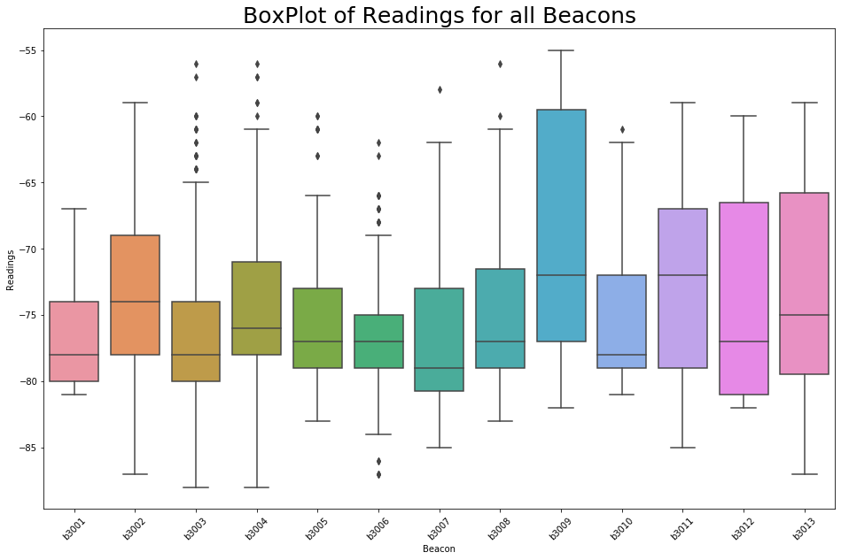

```python
plt.figure(figsize=(16,10))
g=sns.boxplot(x="Beacon", y="Readings", data=valid_reading_all_beacon)
g.set_title('BoxPlot of Readings for all Beacons', fontsize = 25)
plt.xticks(rotation=45)
plt.savefig('1. BeaconReadings.png', dpi=300, bbox_inches='tight')
```

## 2. Count of unique readings in each location

Let's look at the unique values in the `location` column from the dataset.

```python
loc_df=np.unique(df_rssi['location'], return_counts = True)
loc_df=pd.DataFrame(loc_df).T
loc_df.columns=["location", "count"]
loc_df
```

|  | location | count |
| --- | --- | --- |
| 0 | D13 | 6 |
| 1 | D14 | 4 |
| 2 | D15 | 14 |
| 3 | E15 | 4 |
| 4 | F08 | 4 |
| 5 | G15 | 4 |
| 6 | I01 | 18 |
| 7 | I02 | 21 |
| 8 | I03 | 19 |
| 9 | I04 | 18 |
| 10 | I05 | 19 |
| 11 | I06 | 27 |
| 12 | I07 | 27 |
| 13 | I08 | 26 |
| 14 | I09 | 8 |
| 15 | I10 | 14 |
| 16 | I15 | 5 |
| 17 | J01 | 16 |
| 18 | J02 | 22 |
| 19 | J03 | 24 |
| 20 | J04 | 32 |
| 21 | J05 | 19 |
| 22 | J06 | 29 |
| 23 | J07 | 27 |
| 24 | J08 | 9 |
| 25 | J10 | 6 |
| 26 | J15 | 8 |
| 27 | K01 | 6 |
| 28 | K02 | 9 |
| 29 | K03 | 23 |

[output cut: 75 more lines]

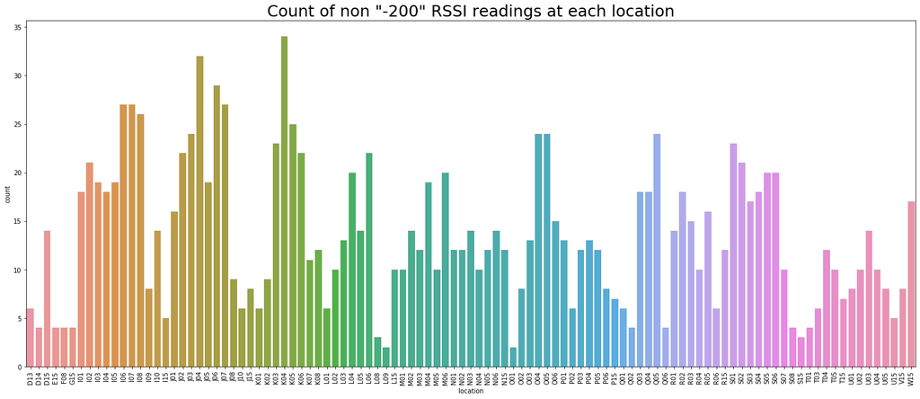

```python
plt.figure(figsize=(25, 10))
plt.xticks(rotation='vertical')
sns.barplot(x='location', y='count', data=loc_df)
plt.title('Count of non "-200" RSSI readings at each location', fontsize = 25)
plt.savefig('2. non -200.png', dpi=300, bbox_inches='tight')
```

Set number of unique location as `n_locations`

```python
n_locations = len(loc_df)
n_locations
```

```
105
```

After having a basic understanding on the dataset, I have set the goal of the project - **To identify the readings coverage of each iBeacon**, Thus from the above findings, we have completed the checkings on the read-in dataset for the goal of our project. We can now move on to pairwise comparison.

## Pairwise Comparison

### 1. Location vs iBeacon

Explore the relationship between pairs of attributes. Let's see which iBeacon would detect reading for the location in the dataset.

```
(a) Assign a location code to each unique location and make an additional column in the master dataframe `df_rssi`, for each observation (or reading) specify the location code in `df_rssi`.
```

```python
loc_df["location_code"]=-1

count=0
for i in range(len(loc_df)):
    loc_df["location_code"][i]=count
    count+=1
loc_dict=loc_df.set_index('location')['location_code'].to_dict()
```

```python
df_rssi['location_code']=df_rssi['location'].replace(loc_dict)
```

[output not shown]

```python
bLoc = np.zeros((n_locations, n_beacons))
bLocCnt = np.zeros((n_locations, n_beacons))
for i in range(0, n_readings):
    for j in range(0, n_beacons):
        if df_rssi.iloc[i][j+2] != -200:
            bLoc[df_rssi['location_code'][i],j]=1
            bLocCnt[df_rssi['location_code'][i],j]=bLocCnt[df_rssi['location_code'][i],j]+1
```

```
(c) We can sum up bLocCnt to find out the number of non -200 readings in the entire file
```

```python
sum(sum(bLocCnt))
```

```
2028.0
```

```
(d) make a list of beacon from b3001 to b3013 as specified from the given excel file
```

```python
beacon_colunm1 = list(map(str, range(1, 10)))
beacon_colunm1 = ['b300' + sub for sub in beacon_colunm1]
beacon_colunm2 = list(map(str, range(10, 14)))
beacon_colunm2 = ['b30' + sub for sub in beacon_colunm2]
beacon_colunm=beacon_colunm1+beacon_colunm2
```

```
(e) print a heatmap to illustrate the relationship between beacon and location.
```

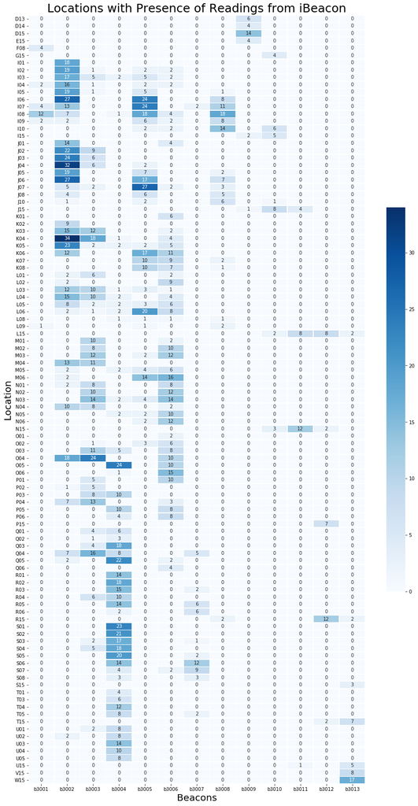

```python
y_axis_labels = loc_df['location']
x_axis_labels = beacon_colunm
plt.figure(figsize=(16, 30))
sns.heatmap(bLocCnt, cmap="Blues", annot=True, fmt='.0f', yticklabels=y_axis_labels, xticklabels=x_axis_labels, linewidths=.5, cbar_kws={"shrink": 0.5})
plt.title("Locations with Presence of Readings from iBeacon", fontsize = 25)
plt.xlabel("Beacons", fontsize = 20)
plt.ylabel("Location", fontsize = 20)
plt.savefig('3.readingsLocBeacon.png', dpi=300, bbox_inches='tight')
```

### 2. Location vs combinations of iBeacons

Let's group observations and find the relationship of each observations with Beacon and location

```
  (a) Construct a matrix, `bReadings` which has the dimension of `n_readings` x `n_beacons`.  The matrix represent the `non -200` value in the beacon in each reading. `1` stands for `non -200` value,  `0` stands for `-200` value.
```

```python
bReadings = np.zeros((n_readings, n_beacons))
for i in range(0, n_readings):
    for j in range(0, n_beacons):
        if df_rssi.iloc[i][j+2] != -200:
            bReadings[i,j]=1
```

```python
bReadings[0:15,:]
```

```
array([[0., 0., 0., 0., 0., 1., 0., 0., 0., 0., 0., 0., 0.],
       [0., 0., 0., 0., 0., 1., 0., 0., 0., 0., 0., 0., 0.],
       [0., 0., 0., 0., 0., 1., 0., 0., 0., 0., 0., 0., 0.],
       [0., 0., 0., 0., 0., 1., 0., 0., 0., 0., 0., 0., 0.],
       [0., 0., 0., 0., 0., 1., 0., 0., 0., 0., 0., 0., 0.],
       [0., 0., 1., 0., 0., 0., 0., 0., 0., 0., 0., 0., 0.],
       [0., 0., 1., 0., 0., 1., 0., 0., 0., 0., 0., 0., 0.],
       [0., 0., 1., 0., 0., 0., 0., 0., 0., 0., 0., 0., 0.],
       [0., 0., 0., 1., 0., 0., 0., 0., 0., 0., 0., 0., 0.],
       [0., 0., 0., 1., 0., 0., 0., 0., 0., 0., 0., 0., 0.],
       [0., 0., 0., 1., 0., 0., 0., 0., 0., 0., 0., 0., 0.],
       [0., 0., 0., 1., 0., 0., 0., 0., 0., 0., 0., 0., 0.],
       [0., 0., 0., 1., 0., 0., 0., 0., 0., 0., 0., 0., 0.],
       [0., 0., 0., 1., 0., 0., 0., 0., 0., 0., 0., 0., 0.],
       [0., 0., 0., 1., 0., 0., 0., 0., 0., 0., 0., 0., 0.]])
```

```python
bReadings.shape
```

```
(1420, 13)
```

```
  (b) Make a new column `readings_group` in dataframe `df_rssi`, initialize the value as `-1` for all observations
```

```python
df_rssi['readings_group']=-1
df_rssi.head(5)
```

|  | location | date | b3001 | b3002 | b3003 | b3004 | b3005 | b3006 | b3007 | b3008 | b3009 | b3010 | b3011 | b3012 | b3013 | location_code | readings_group |
| --- | --- | --- | --- | --- | --- | --- | --- | --- | --- | --- | --- | --- | --- | --- | --- | --- | --- |
| 0 | O02 | 2016-10-18 11:15:21 | -200 | -200 | -200 | -200 | -200 | -78 | -200 | -200 | -200 | -200 | -200 | -200 | -200 | 58 | -1 |
| 1 | P01 | 2016-10-18 11:15:19 | -200 | -200 | -200 | -200 | -200 | -78 | -200 | -200 | -200 | -200 | -200 | -200 | -200 | 63 | -1 |
| 2 | P01 | 2016-10-18 11:15:17 | -200 | -200 | -200 | -200 | -200 | -77 | -200 | -200 | -200 | -200 | -200 | -200 | -200 | 63 | -1 |
| 3 | P01 | 2016-10-18 11:15:15 | -200 | -200 | -200 | -200 | -200 | -77 | -200 | -200 | -200 | -200 | -200 | -200 | -200 | 63 | -1 |
| 4 | P01 | 2016-10-18 11:15:13 | -200 | -200 | -200 | -200 | -200 | -77 | -200 | -200 | -200 | -200 | -200 | -200 | -200 | 63 | -1 |

```
  (c) Use a for loop to read all the observations, check if there is any same becaon combinations of non -200 readings  in previous row, if so, classify them into same readings group.  Shorten the nympy array `bReadings` with no duplicate beacon combinations, and name it as `bReadingsGroup`.
```

```python
group_cnt= df_rssi.loc[0, "readings_group"]=0
arr=[bReadings[0]]

for i in range(1, n_readings):
    last_row = i-1
    for j in range(0, i):
        if np.array_equal(bReadings[i],bReadings[j]):
            df_rssi.loc[i, "readings_group"] = df_rssi.loc[j, "readings_group"]
            break
        if j == last_row:
            group_cnt+=1
            df_rssi.loc[i, "readings_group"] =group_cnt
            arr.append(bReadings[i])

bReadingsGroup=np.array(arr)
```

```
  (d) Construct a matrix, `bReadingsGroupCnt`, which is the same deminsion as `bReadingsGroup`, use it to count the frequency of occurrences for each beacon combinations on all obvervations.  Also, make a list `locationReadingList` which will record the location came up in dataframe `df_rssi` for each `bReadingsGroup`.
```

```python
bReadingsGroupCnt=np.zeros((len(bReadingsGroup), n_beacons))

locationReadingList = [list() for i in range(len(bReadingsGroup))]

for i in range(0, n_readings):
    for j in range(0, len(bReadingsGroup)):
        if np.array_equal(bReadings[i],bReadingsGroup[j]):
            bReadingsGroupCnt[j]=bReadingsGroupCnt[j]+bReadings[i]
            if df_rssi['location'][i] not in locationReadingList[j]:
                locationReadingList[j].append(df_rssi['location'][i])
```

```
    (e) Construct a list `beaconReadingList` which will record the beacon combination for each `bReadingsGroup`.
```

```python
beaconReadingList = [ list() for i in range(len(bReadingsGroup))]

for i in range(0, len(bReadingsGroup)):
    bArray=np.argwhere(bReadingsGroup[i]!=0).reshape(-1)
    for j in range(0, len(bArray)):
        beacon = 'b300' + str(bArray[j] + 1)
        beaconReadingList[i].append(beacon)
```

```
    (f) Show the length of `bReadingsGroup`
```

```python
len(bReadingsGroup)
```

```
63
```

```
    (g) Sum up bReadingsGroupCnt, it also shows the number of non -200 readings in the entire file
```

```python
sum(sum(bReadingsGroupCnt))
```

```
2028.0
```

```
    (h) Define a function listToString to combine list as a string
```

```python
# Python program to convert a list
# to string using join() function

# Function to convert
def listToString(s):

    # initialize an empty string
    str1 = " "

    # return string
    return (str1.join(s))
```

```
    (i) Construct a dataframe `readingList_df` which would show the bReadingsGroup, combination of beacons and occurrences of locations side by side
```

```python
count = 0
readingList_df = pd.DataFrame(columns=["readings_group", "beacon_list", "location_list"])
for i in range(0, len(bReadingsGroup)):
    beaconStr=listToString(beaconReadingList[i])
    locationStr=listToString(locationReadingList[i])
    readingList_df.loc[len(readingList_df)] = [count, beaconStr, locationStr]
    count+=1

pd.options.display.max_colwidth = None
display(HTML('<b>Table 1: Readings group by Combination of beacon Readings occurences of locations </b>'))
readingList_df
```

**Table 1: Readings group by Combination of beacon Readings occurences of locations**

|  | readings_group | beacon_list | location_list |
| --- | --- | --- | --- |
| 0 | 0 | b3006 | O02 P01 L05 M05 N05 P05 Q05 Q06 P06 O06 N06 M06 L06 K06 J01 K01 L02 M02 N01 N02 O01 I08 K08 K07 |
| 1 | 1 | b3003 | P01 P02 K03 P03 Q04 P04 O04 M04 L04 L01 M01 M02 N01 Q02 |
| 2 | 2 | b3003 b3006 | P01 K03 M03 N03 O03 L01 M01 M02 N01 N02 L04 P04 |
| 3 | 3 | b3004 | R01 R02 S01 S02 T01 U01 U02 O03 P03 Q03 R03 S03 T03 U03 U04 T04 S04 R04 O05 P05 Q05 R05 S05 T05 U05 S06 S07 S08 L08 Q02 Q01 |
| 4 | 4 | b3002 | U02 J03 K03 L03 N04 M04 L04 K04 J04 I04 I05 J05 K05 L05 K06 J06 J02 I06 I01 I02 I03 J01 K02 J08 L02 P02 |
| 5 | 5 | b3003 b3004 | U01 O03 P03 Q03 S04 R04 Q04 S03 Q01 |
| 6 | 6 | b3002 b3003 | J03 K03 L03 Q04 P04 O04 N04 M04 L04 K04 J04 J02 L01 K05 I02 I04 I03 |
| 7 | 7 | b3002 b3003 b3005 | L03 |
| 8 | 8 | b3003 b3005 b3006 | M03 N03 O02 |
| 9 | 9 | b3003 b3004 b3006 | N03 L04 |
| 10 | 10 | b3002 b3004 | Q04 L05 Q05 |
| 11 | 11 | b3003 b3007 | Q04 |
| 12 | 12 | b3002 b3003 b3007 | Q04 |
| 13 | 13 | b3002 b3003 b3006 | O04 N04 K04 N01 L05 P04 |
| 14 | 14 | b3002 b3006 | L04 K05 I04 I02 J01 L02 |
| 15 | 15 | b3001 | I04 F08 |
| 16 | 16 | b3002 b3008 | J05 J06 I09 I07 |
| 17 | 17 | b3002 b3005 | J05 M05 K06 J06 I06 J04 I07 I03 I04 I05 I08 J07 L06 |
| 18 | 18 | b3002 b3004 b3006 | K05 I03 |
| 19 | 19 | b3005 | M05 M06 L06 K06 J07 I07 J08 I02 O02 I03 I08 J06 K05 K07 K08 L08 L05 N06 |
| 20 | 20 | b3004 b3006 | M05 O05 P05 P06 O06 |
| 21 | 21 | b3004 b3005 | N05 |
| 22 | 22 | b3004 b3007 | R05 S05 S06 R06 S07 S08 S03 R03 |
| 23 | 23 | b3007 | R05 T05 S06 R06 S07 S08 |
| 24 | 24 | b3005 b3006 | M06 L06 K06 J07 K07 K08 |
| 25 | 25 | b3002 b3005 b3006 | M06 K06 |
| 26 | 26 | b3002 b3005 b3008 | I06 I07 I08 J08 J06 J07 |
| 27 | 27 | b3005 b3008 | J07 I07 I10 J10 J08 I09 L09 K08 |
| 28 | 28 | b3008 b30010 | I10 |
| 29 | 29 | b3008 | I10 J10 I08 J08 |
| 30 | 30 | b3009 | D15 E15 D14 D13 |
| 31 | 31 | b30010 | G15 I15 J15 |
| 32 | 32 | b30010 b30011 | J15 N15 |
| 33 | 33 | b30011 | L15 N15 |
| 34 | 34 | b30011 b30012 | L15 N15 |
| 35 | 35 | b30010 b30012 b30013 | L15 |
| 36 | 36 | b3008 b30012 | R15 |
| 37 | 37 | b30012 | R15 P15 |
| 38 | 38 | b30012 b30013 | R15 T15 |
| 39 | 39 | b30013 | T15 W15 S15 U15 V15 |
| 40 | 40 | b3005 b3007 | I07 |
| 41 | 41 | b3001 b3008 | I08 L09 |
| 42 | 42 | b3001 b3005 b3008 | I08 I07 I09 |
| 43 | 43 | b3001 b3002 | I07 |
| 44 | 44 | b3001 b3005 b3006 b3008 | I08 |
| 45 | 45 | b3005 b3006 b3008 | I09 K07 |
| 46 | 46 | b3006 b3008 b30010 | I10 |
| 47 | 47 | b3003 b3005 | J07 |
| 48 | 48 | b3009 b30010 | I15 J15 |
| 49 | 49 | b30011 b30013 | U15 |
| 50 | 50 | b3006 b3007 | S07 |
| 51 | 51 | b3004 b3006 b3007 | S07 |
| 52 | 52 | b3006 b3008 | L08 |
| 53 | 53 | b3002 b3004 b3005 b3006 | L06 |
| 54 | 54 | b3003 b3004 b3005 b3006 | L06 |
| 55 | 55 | b3002 b3003 b3005 b3006 | L05 |
| 56 | 56 | b3002 b3003 b3004 | L04 |
| 57 | 57 | b3004 b3005 b3006 | L03 |
| 58 | 58 | b3002 b3003 b3004 b3006 | K04 |
| 59 | 59 | b3004 b3005 b3008 | I08 |
| 60 | 60 | b3002 b3003 b3005 b3008 | I05 |
| 61 | 61 | b3002 b3008 b30010 | J10 |
| 62 | 62 | b3002 b3003 b3004 b3007 | Q04 |

```python
readingList_df.to_csv('a. readingList_df.csv', index=False)
```

```
(j) print a heatmap to illustrate the relationship between bReadingsGroupCnt and combinations of beacon.
```

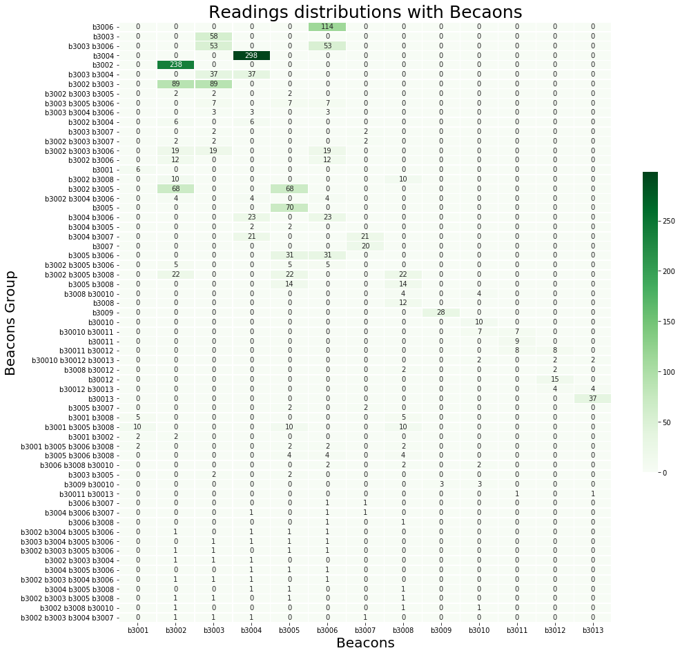

```python
import matplotlib.pyplot as plt
x_axis_labels=beacon_colunm
y_axis_labels = readingList_df['beacon_list']
plt.figure(figsize=(16, 16))
sns.heatmap(bReadingsGroupCnt, cmap="Greens", annot=True, fmt='.0f', yticklabels=y_axis_labels, xticklabels =x_axis_labels, linewidths=.5, cbar_kws={"shrink": 0.5})
plt.title("Readings distributions with Becaons", fontsize = 25)
plt.xlabel("Beacons", fontsize = 20)
plt.ylabel("Beacons Group", fontsize = 20)
plt.savefig('4.readingGroupBeacon.png', dpi=300, bbox_inches='tight')
```

```
    (k) Construct a new dataframe `df_rssi_readingList` which shows the group the count of location and readings_group.
```

```python
df_rssi_readingList=df_rssi.groupby(['location', 'readings_group']).size().reset_index()
df_rssi_readingList.columns=['location', 'readings_group', 'count']
df_rssi_readingList
```

|  | location | readings_group | count |
| --- | --- | --- | --- |
| 0 | D13 | 30 | 6 |
| 1 | D14 | 30 | 4 |
| 2 | D15 | 30 | 14 |
| 3 | E15 | 30 | 4 |
| 4 | F08 | 15 | 4 |
| 5 | G15 | 31 | 4 |
| 6 | I01 | 4 | 18 |
| 7 | I02 | 4 | 16 |
| 8 | I02 | 6 | 1 |
| 9 | I02 | 14 | 2 |
| 10 | I02 | 19 | 2 |
| 11 | I03 | 4 | 7 |
| 12 | I03 | 6 | 5 |
| 13 | I03 | 17 | 3 |
| 14 | I03 | 18 | 2 |
| 15 | I03 | 19 | 2 |
| 16 | I04 | 4 | 11 |
| 17 | I04 | 6 | 1 |
| 18 | I04 | 14 | 2 |
| 19 | I04 | 15 | 2 |
| 20 | I04 | 17 | 2 |
| 21 | I05 | 4 | 14 |
| 22 | I05 | 17 | 4 |
| 23 | I05 | 60 | 1 |
| 24 | I06 | 4 | 3 |
| 25 | I06 | 17 | 16 |
| 26 | I06 | 26 | 8 |
| 27 | I07 | 16 | 1 |
| 28 | I07 | 17 | 4 |
| 29 | I07 | 19 | 8 |

[output cut: 264 more lines]

```
    (l) Map the beacon combination list to df_rssi_readingList.
```

```python
beaconList_dict=readingList_df.set_index('readings_group')['beacon_list'].to_dict()
df_rssi_readingList['beacon_list']=df_rssi_readingList['readings_group'].replace(beaconList_dict)
df_rssi_readingList = df_rssi_readingList.reindex(columns=['location', 'readings_group', 'beacon_list', 'count']).reset_index(drop=True)
df_rssi_readingList.head(15)
```

|  | location | readings_group | beacon_list | count |
| --- | --- | --- | --- | --- |
| 0 | D13 | 30 | b3009 | 6 |
| 1 | D14 | 30 | b3009 | 4 |
| 2 | D15 | 30 | b3009 | 14 |
| 3 | E15 | 30 | b3009 | 4 |
| 4 | F08 | 15 | b3001 | 4 |
| 5 | G15 | 31 | b30010 | 4 |
| 6 | I01 | 4 | b3002 | 18 |
| 7 | I02 | 4 | b3002 | 16 |
| 8 | I02 | 6 | b3002 b3003 | 1 |
| 9 | I02 | 14 | b3002 b3006 | 2 |
| 10 | I02 | 19 | b3005 | 2 |
| 11 | I03 | 4 | b3002 | 7 |
| 12 | I03 | 6 | b3002 b3003 | 5 |
| 13 | I03 | 17 | b3002 b3005 | 3 |
| 14 | I03 | 18 | b3002 b3004 b3006 | 2 |

```python
df_rssi_readingList.to_csv('b. df_rssi_readingList.csv', index=False)
```

```
    (m) Row 1 of Table 1 can be explained by `df_rssi_readingList` when readings_group == 0 and an associated bar chart.
```

```python
df_rssi_readingList[df_rssi_readingList['readings_group']==0]
```

|  | location | readings_group | beacon_list | count |
| --- | --- | --- | --- | --- |
| 35 | I08 | 0 | b3006 | 2 |
| 54 | J01 | 0 | b3006 | 2 |
| 89 | K01 | 0 | b3006 | 6 |
| 104 | K06 | 0 | b3006 | 2 |
| 110 | K07 | 0 | b3006 | 1 |
| 114 | K08 | 0 | b3006 | 2 |
| 121 | L02 | 0 | b3006 | 8 |
| 135 | L05 | 0 | b3006 | 4 |
| 141 | L06 | 0 | b3006 | 2 |
| 157 | M02 | 0 | b3006 | 6 |
| 165 | M05 | 0 | b3006 | 4 |
| 169 | M06 | 0 | b3006 | 6 |
| 173 | N01 | 0 | b3006 | 4 |
| 177 | N02 | 0 | b3006 | 2 |
| 185 | N05 | 0 | b3006 | 10 |
| 187 | N06 | 0 | b3006 | 12 |
| 192 | O01 | 0 | b3006 | 2 |
| 193 | O02 | 0 | b3006 | 5 |
| 204 | O06 | 0 | b3006 | 14 |
| 206 | P01 | 0 | b3006 | 8 |
| 218 | P05 | 0 | b3006 | 2 |
| 221 | P06 | 0 | b3006 | 4 |
| 237 | Q05 | 0 | b3006 | 2 |
| 240 | Q06 | 0 | b3006 | 4 |

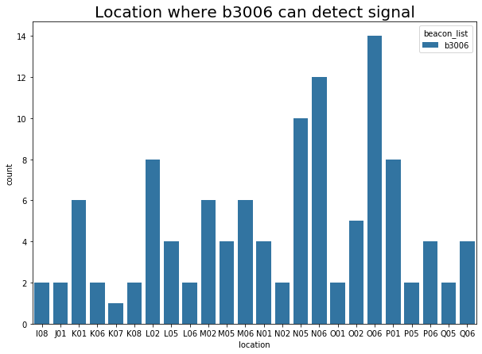

```python
plt.figure(figsize=(10, 7))
sns.barplot(x='location', y='count', hue="beacon_list", data=df_rssi_readingList[df_rssi_readingList['readings_group']==0])
plt.title("Location where b3006 can detect signal", fontsize = 20)
plt.savefig('5.b300Loc.png', dpi=300, bbox_inches='tight')
```

```
    (n) Location in the bar chart, for example K08, can be explaind by df_rssi_readingList when location == K08, and an associated bar chart.
```

```python
df_rssi_readingList[df_rssi_readingList['location']=='K08']
```

|  | location | readings_group | beacon_list | count |
| --- | --- | --- | --- | --- |
| 114 | K08 | 0 | b3006 | 2 |
| 115 | K08 | 19 | b3005 | 4 |
| 116 | K08 | 24 | b3005 b3006 | 5 |
| 117 | K08 | 27 | b3005 b3008 | 1 |

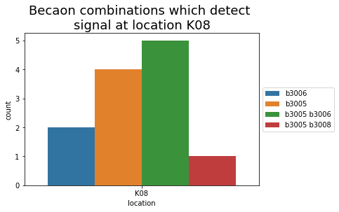

```python
plt.title("Becaon combinations which detect \nsignal at location K08", fontsize = 18)
g=sns.barplot(x='location', y='count', hue="beacon_list", data=df_rssi_readingList[df_rssi_readingList['location']=='K08'])
g.legend(loc='center left', bbox_to_anchor=(1, 0.5), ncol=1)
plt.savefig('6. kn08.png', dpi=300, bbox_inches='tight')
```

## Data Modeling

Read in all the RSSI readings into an array `array_rssi`.

```python
array_rssi=df_rssi[beacons_col].values
array_rssi.shape
```

```
(1420, 13)
```

### 1. DB Scan

```
(a)  Construct the k Distance Graph to determine Eps parameter for DB Scan.
```

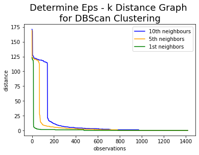

```python
from sklearn.neighbors import NearestNeighbors
nbrs=NearestNeighbors().fit(array_rssi)
distances, indices=nbrs.kneighbors(array_rssi, 20)
kDis=distances[:,10]
kDis2=distances[:,5]
kDis3=distances[:,1]

kDis.sort()
kDis2.sort()
kDis3.sort()

kDis=kDis[range(len(kDis)-1, 0, -1)]
kDis2=kDis2[range(len(kDis2)-1, 0, -1)]
kDis3=kDis3[range(len(kDis3)-1, 0, -1)]
plt.xlabel('observations')
plt.ylabel('distance')
plt.plot(range(0, len(kDis)), kDis, color='blue', label="10th neighbours")
plt.plot(range(0, len(kDis2)), kDis2, color='orange', label="5th neighbors")
plt.plot(range(0, len(kDis3)), kDis3, color='green', label="1st neighbors")
plt.legend(loc="top right")
plt.title("Determine Eps - k Distance Graph \nfor DBScan Clustering", fontsize = 18)
plt.savefig('7. EPS.png', dpi=300, bbox_inches='tight')
```

The k-distance graph can help us to determine the optimal “eps” for fitting db scan clustering.  
Beside eps, db_scan has another parameter, min_samples (we chose to tune the parameter eps only in this assignment), which is default to be 5 and is shown as the 5th neighbours in the k distance graph. From the yellow line, it suggests the elbow occurs at around 13 for 5th neighbours, thus we fit our original data (a matrix with n_readings x n_beacons contains RSSI measurements) into db scan with eps=13 and min_samples=5 (default value).

```
   (b) Perform DBScan by fitting `aray_rssi` with the optimal eps from the k-distance graph.
```

```python
dbs_13 = cluster.DBSCAN(eps=13)
dbs_fit_13=dbs_13.fit(array_rssi)
```

```
  (c) Find the label from the fitted model.  Check the number of clusters in the label.
```

```python
labels_dbs_13=dbs_fit_13.labels_
```

```python
np.unique(labels_dbs_13, return_counts = True)
```

```
(array([-1,  0,  1,  2,  3,  4,  5,  6,  7,  8,  9, 10, 11, 12, 13, 14, 15,
        16, 17, 18, 19, 20, 21, 22, 23, 24, 25, 26, 27, 28, 29, 30],
       dtype=int64),
 array([ 65, 114,  58,  53, 298, 238,  37,  89,   7,   6,  19,  12,   6,
         68,  70,  23,  21,  20,  31,   5,  10,  22,  14,  12,  28,  10,
          9,   8,  15,  37,   5,  10], dtype=int64))
```

```
(d) Construct a dataframe `X` which will compare the cluster labels with the target (which is the readings_group in `df_rssi` dataframe)
```

```python
df_rssi['beacon_list']=df_rssi['readings_group'].replace(beaconList_dict)
```

```python
X=pd.DataFrame(array_rssi)
X['cluster']=labels_dbs_13
X['target']= df_rssi['readings_group'].astype(str).str.zfill(2) + '_' + df_rssi['beacon_list']
X.head(10)
```

|  | 0 | 1 | 2 | 3 | 4 | 5 | 6 | 7 | 8 | 9 | 10 | 11 | 12 | cluster | target |
| --- | --- | --- | --- | --- | --- | --- | --- | --- | --- | --- | --- | --- | --- | --- | --- |
| 0 | -200 | -200 | -200 | -200 | -200 | -78 | -200 | -200 | -200 | -200 | -200 | -200 | -200 | 0 | 00_b3006 |
| 1 | -200 | -200 | -200 | -200 | -200 | -78 | -200 | -200 | -200 | -200 | -200 | -200 | -200 | 0 | 00_b3006 |
| 2 | -200 | -200 | -200 | -200 | -200 | -77 | -200 | -200 | -200 | -200 | -200 | -200 | -200 | 0 | 00_b3006 |
| 3 | -200 | -200 | -200 | -200 | -200 | -77 | -200 | -200 | -200 | -200 | -200 | -200 | -200 | 0 | 00_b3006 |
| 4 | -200 | -200 | -200 | -200 | -200 | -77 | -200 | -200 | -200 | -200 | -200 | -200 | -200 | 0 | 00_b3006 |
| 5 | -200 | -200 | -82 | -200 | -200 | -200 | -200 | -200 | -200 | -200 | -200 | -200 | -200 | 1 | 01_b3003 |
| 6 | -200 | -200 | -80 | -200 | -200 | -77 | -200 | -200 | -200 | -200 | -200 | -200 | -200 | 2 | 02_b3003 b3006 |
| 7 | -200 | -200 | -86 | -200 | -200 | -200 | -200 | -200 | -200 | -200 | -200 | -200 | -200 | 1 | 01_b3003 |
| 8 | -200 | -200 | -200 | -75 | -200 | -200 | -200 | -200 | -200 | -200 | -200 | -200 | -200 | 3 | 03_b3004 |
| 9 | -200 | -200 | -200 | -75 | -200 | -200 | -200 | -200 | -200 | -200 | -200 | -200 | -200 | 3 | 03_b3004 |

```
  (e) Use the crosstab function to construct a confusion matrix.
```

```python
cm_dbs13=pd.crosstab(index=X["target"], columns=X["cluster"])
cm_dbs13
```

| cluster target | -1 | 0 | 1 | 2 | 3 | 4 | 5 | 6 | 7 | 8 | 9 | 10 | 11 | 12 | 13 | 14 | 15 | 16 | 17 | 18 | 19 | 20 | 21 | 22 | 23 | 24 | 25 | 26 | 27 | … |
| --- | --- | --- | --- | --- | --- | --- | --- | --- | --- | --- | --- | --- | --- | --- | --- | --- | --- | --- | --- | --- | --- | --- | --- | --- | --- | --- | --- | --- | --- | --- |
| 00_b3006 | 0 | 114 | 0 | 0 | 0 | 0 | 0 | 0 | 0 | 0 | 0 | 0 | 0 | 0 | 0 | 0 | 0 | 0 | 0 | 0 | 0 | 0 | 0 | 0 | 0 | 0 | 0 | 0 | 0 | … |
| 01_b3003 | 0 | 0 | 58 | 0 | 0 | 0 | 0 | 0 | 0 | 0 | 0 | 0 | 0 | 0 | 0 | 0 | 0 | 0 | 0 | 0 | 0 | 0 | 0 | 0 | 0 | 0 | 0 | 0 | 0 | … |
| 02_b3003 b3006 | 0 | 0 | 0 | 53 | 0 | 0 | 0 | 0 | 0 | 0 | 0 | 0 | 0 | 0 | 0 | 0 | 0 | 0 | 0 | 0 | 0 | 0 | 0 | 0 | 0 | 0 | 0 | 0 | 0 | … |
| 03_b3004 | 0 | 0 | 0 | 0 | 298 | 0 | 0 | 0 | 0 | 0 | 0 | 0 | 0 | 0 | 0 | 0 | 0 | 0 | 0 | 0 | 0 | 0 | 0 | 0 | 0 | 0 | 0 | 0 | 0 | … |
| 04_b3002 | 0 | 0 | 0 | 0 | 0 | 238 | 0 | 0 | 0 | 0 | 0 | 0 | 0 | 0 | 0 | 0 | 0 | 0 | 0 | 0 | 0 | 0 | 0 | 0 | 0 | 0 | 0 | 0 | 0 | … |
| 05_b3003 b3004 | 0 | 0 | 0 | 0 | 0 | 0 | 37 | 0 | 0 | 0 | 0 | 0 | 0 | 0 | 0 | 0 | 0 | 0 | 0 | 0 | 0 | 0 | 0 | 0 | 0 | 0 | 0 | 0 | 0 | … |
| 06_b3002 b3003 | 0 | 0 | 0 | 0 | 0 | 0 | 0 | 89 | 0 | 0 | 0 | 0 | 0 | 0 | 0 | 0 | 0 | 0 | 0 | 0 | 0 | 0 | 0 | 0 | 0 | 0 | 0 | 0 | 0 | … |
| 07_b3002 b3003 b3005 | 2 | 0 | 0 | 0 | 0 | 0 | 0 | 0 | 0 | 0 | 0 | 0 | 0 | 0 | 0 | 0 | 0 | 0 | 0 | 0 | 0 | 0 | 0 | 0 | 0 | 0 | 0 | 0 | 0 | … |
| 08_b3003 b3005 b3006 | 0 | 0 | 0 | 0 | 0 | 0 | 0 | 0 | 7 | 0 | 0 | 0 | 0 | 0 | 0 | 0 | 0 | 0 | 0 | 0 | 0 | 0 | 0 | 0 | 0 | 0 | 0 | 0 | 0 | … |
| 09_b3003 b3004 b3006 | 3 | 0 | 0 | 0 | 0 | 0 | 0 | 0 | 0 | 0 | 0 | 0 | 0 | 0 | 0 | 0 | 0 | 0 | 0 | 0 | 0 | 0 | 0 | 0 | 0 | 0 | 0 | 0 | 0 | … |
| 10_b3002 b3004 | 0 | 0 | 0 | 0 | 0 | 0 | 0 | 0 | 0 | 6 | 0 | 0 | 0 | 0 | 0 | 0 | 0 | 0 | 0 | 0 | 0 | 0 | 0 | 0 | 0 | 0 | 0 | 0 | 0 | … |
| 11_b3003 b3007 | 2 | 0 | 0 | 0 | 0 | 0 | 0 | 0 | 0 | 0 | 0 | 0 | 0 | 0 | 0 | 0 | 0 | 0 | 0 | 0 | 0 | 0 | 0 | 0 | 0 | 0 | 0 | 0 | 0 | … |
| 12_b3002 b3003 b3007 | 2 | 0 | 0 | 0 | 0 | 0 | 0 | 0 | 0 | 0 | 0 | 0 | 0 | 0 | 0 | 0 | 0 | 0 | 0 | 0 | 0 | 0 | 0 | 0 | 0 | 0 | 0 | 0 | 0 | … |
| 13_b3002 b3003 b3006 | 0 | 0 | 0 | 0 | 0 | 0 | 0 | 0 | 0 | 0 | 19 | 0 | 0 | 0 | 0 | 0 | 0 | 0 | 0 | 0 | 0 | 0 | 0 | 0 | 0 | 0 | 0 | 0 | 0 | … |
| 14_b3002 b3006 | 0 | 0 | 0 | 0 | 0 | 0 | 0 | 0 | 0 | 0 | 0 | 12 | 0 | 0 | 0 | 0 | 0 | 0 | 0 | 0 | 0 | 0 | 0 | 0 | 0 | 0 | 0 | 0 | 0 | … |
| 15_b3001 | 0 | 0 | 0 | 0 | 0 | 0 | 0 | 0 | 0 | 0 | 0 | 0 | 6 | 0 | 0 | 0 | 0 | 0 | 0 | 0 | 0 | 0 | 0 | 0 | 0 | 0 | 0 | 0 | 0 | … |
| 16_b3002 b3008 | 0 | 0 | 0 | 0 | 0 | 0 | 0 | 0 | 0 | 0 | 0 | 0 | 0 | 0 | 0 | 0 | 0 | 0 | 0 | 0 | 10 | 0 | 0 | 0 | 0 | 0 | 0 | 0 | 0 | … |
| 17_b3002 b3005 | 0 | 0 | 0 | 0 | 0 | 0 | 0 | 0 | 0 | 0 | 0 | 0 | 0 | 68 | 0 | 0 | 0 | 0 | 0 | 0 | 0 | 0 | 0 | 0 | 0 | 0 | 0 | 0 | 0 | … |
| 18_b3002 b3004 b3006 | 4 | 0 | 0 | 0 | 0 | 0 | 0 | 0 | 0 | 0 | 0 | 0 | 0 | 0 | 0 | 0 | 0 | 0 | 0 | 0 | 0 | 0 | 0 | 0 | 0 | 0 | 0 | 0 | 0 | … |
| 19_b3005 | 0 | 0 | 0 | 0 | 0 | 0 | 0 | 0 | 0 | 0 | 0 | 0 | 0 | 0 | 70 | 0 | 0 | 0 | 0 | 0 | 0 | 0 | 0 | 0 | 0 | 0 | 0 | 0 | 0 | … |
| 20_b3004 b3006 | 0 | 0 | 0 | 0 | 0 | 0 | 0 | 0 | 0 | 0 | 0 | 0 | 0 | 0 | 0 | 23 | 0 | 0 | 0 | 0 | 0 | 0 | 0 | 0 | 0 | 0 | 0 | 0 | 0 | … |
| 21_b3004 b3005 | 2 | 0 | 0 | 0 | 0 | 0 | 0 | 0 | 0 | 0 | 0 | 0 | 0 | 0 | 0 | 0 | 0 | 0 | 0 | 0 | 0 | 0 | 0 | 0 | 0 | 0 | 0 | 0 | 0 | … |
| 22_b3004 b3007 | 0 | 0 | 0 | 0 | 0 | 0 | 0 | 0 | 0 | 0 | 0 | 0 | 0 | 0 | 0 | 0 | 21 | 0 | 0 | 0 | 0 | 0 | 0 | 0 | 0 | 0 | 0 | 0 | 0 | … |
| 23_b3007 | 0 | 0 | 0 | 0 | 0 | 0 | 0 | 0 | 0 | 0 | 0 | 0 | 0 | 0 | 0 | 0 | 0 | 20 | 0 | 0 | 0 | 0 | 0 | 0 | 0 | 0 | 0 | 0 | 0 | … |
| 24_b3005 b3006 | 0 | 0 | 0 | 0 | 0 | 0 | 0 | 0 | 0 | 0 | 0 | 0 | 0 | 0 | 0 | 0 | 0 | 0 | 31 | 0 | 0 | 0 | 0 | 0 | 0 | 0 | 0 | 0 | 0 | … |
| 25_b3002 b3005 b3006 | 0 | 0 | 0 | 0 | 0 | 0 | 0 | 0 | 0 | 0 | 0 | 0 | 0 | 0 | 0 | 0 | 0 | 0 | 0 | 5 | 0 | 0 | 0 | 0 | 0 | 0 | 0 | 0 | 0 | … |
| 26_b3002 b3005 b3008 | 0 | 0 | 0 | 0 | 0 | 0 | 0 | 0 | 0 | 0 | 0 | 0 | 0 | 0 | 0 | 0 | 0 | 0 | 0 | 0 | 0 | 22 | 0 | 0 | 0 | 0 | 0 | 0 | 0 | … |
| 27_b3005 b3008 | 0 | 0 | 0 | 0 | 0 | 0 | 0 | 0 | 0 | 0 | 0 | 0 | 0 | 0 | 0 | 0 | 0 | 0 | 0 | 0 | 0 | 0 | 14 | 0 | 0 | 0 | 0 | 0 | 0 | … |
| 28_b3008 b30010 | 4 | 0 | 0 | 0 | 0 | 0 | 0 | 0 | 0 | 0 | 0 | 0 | 0 | 0 | 0 | 0 | 0 | 0 | 0 | 0 | 0 | 0 | 0 | 0 | 0 | 0 | 0 | 0 | 0 | … |
| 29_b3008 | 0 | 0 | 0 | 0 | 0 | 0 | 0 | 0 | 0 | 0 | 0 | 0 | 0 | 0 | 0 | 0 | 0 | 0 | 0 | 0 | 0 | 0 | 0 | 12 | 0 | 0 | 0 | 0 | 0 | … |
| 30_b3009 | 0 | 0 | 0 | 0 | 0 | 0 | 0 | 0 | 0 | 0 | 0 | 0 | 0 | 0 | 0 | 0 | 0 | 0 | 0 | 0 | 0 | 0 | 0 | 0 | 28 | 0 | 0 | 0 | 0 | … |
| 31_b30010 | 0 | 0 | 0 | 0 | 0 | 0 | 0 | 0 | 0 | 0 | 0 | 0 | 0 | 0 | 0 | 0 | 0 | 0 | 0 | 0 | 0 | 0 | 0 | 0 | 0 | 10 | 0 | 0 | 0 | … |
| 32_b30010 b30011 | 7 | 0 | 0 | 0 | 0 | 0 | 0 | 0 | 0 | 0 | 0 | 0 | 0 | 0 | 0 | 0 | 0 | 0 | 0 | 0 | 0 | 0 | 0 | 0 | 0 | 0 | 0 | 0 | 0 | … |
| 33_b30011 | 0 | 0 | 0 | 0 | 0 | 0 | 0 | 0 | 0 | 0 | 0 | 0 | 0 | 0 | 0 | 0 | 0 | 0 | 0 | 0 | 0 | 0 | 0 | 0 | 0 | 0 | 9 | 0 | 0 | … |
| 34_b30011 b30012 | 0 | 0 | 0 | 0 | 0 | 0 | 0 | 0 | 0 | 0 | 0 | 0 | 0 | 0 | 0 | 0 | 0 | 0 | 0 | 0 | 0 | 0 | 0 | 0 | 0 | 0 | 0 | 8 | 0 | … |
| 35_b30010 b30012 b30013 | 2 | 0 | 0 | 0 | 0 | 0 | 0 | 0 | 0 | 0 | 0 | 0 | 0 | 0 | 0 | 0 | 0 | 0 | 0 | 0 | 0 | 0 | 0 | 0 | 0 | 0 | 0 | 0 | 0 | … |
| 36_b3008 b30012 | 2 | 0 | 0 | 0 | 0 | 0 | 0 | 0 | 0 | 0 | 0 | 0 | 0 | 0 | 0 | 0 | 0 | 0 | 0 | 0 | 0 | 0 | 0 | 0 | 0 | 0 | 0 | 0 | 0 | … |
| 37_b30012 | 0 | 0 | 0 | 0 | 0 | 0 | 0 | 0 | 0 | 0 | 0 | 0 | 0 | 0 | 0 | 0 | 0 | 0 | 0 | 0 | 0 | 0 | 0 | 0 | 0 | 0 | 0 | 0 | 15 | … |
| 38_b30012 b30013 | 4 | 0 | 0 | 0 | 0 | 0 | 0 | 0 | 0 | 0 | 0 | 0 | 0 | 0 | 0 | 0 | 0 | 0 | 0 | 0 | 0 | 0 | 0 | 0 | 0 | 0 | 0 | 0 | 0 | … |
| 39_b30013 | 0 | 0 | 0 | 0 | 0 | 0 | 0 | 0 | 0 | 0 | 0 | 0 | 0 | 0 | 0 | 0 | 0 | 0 | 0 | 0 | 0 | 0 | 0 | 0 | 0 | 0 | 0 | 0 | 0 | … |
| 40_b3005 b3007 | 2 | 0 | 0 | 0 | 0 | 0 | 0 | 0 | 0 | 0 | 0 | 0 | 0 | 0 | 0 | 0 | 0 | 0 | 0 | 0 | 0 | 0 | 0 | 0 | 0 | 0 | 0 | 0 | 0 | … |
| 41_b3001 b3008 | 0 | 0 | 0 | 0 | 0 | 0 | 0 | 0 | 0 | 0 | 0 | 0 | 0 | 0 | 0 | 0 | 0 | 0 | 0 | 0 | 0 | 0 | 0 | 0 | 0 | 0 | 0 | 0 | 0 | … |
| 42_b3001 b3005 b3008 | 0 | 0 | 0 | 0 | 0 | 0 | 0 | 0 | 0 | 0 | 0 | 0 | 0 | 0 | 0 | 0 | 0 | 0 | 0 | 0 | 0 | 0 | 0 | 0 | 0 | 0 | 0 | 0 | 0 | … |
| 43_b3001 b3002 | 2 | 0 | 0 | 0 | 0 | 0 | 0 | 0 | 0 | 0 | 0 | 0 | 0 | 0 | 0 | 0 | 0 | 0 | 0 | 0 | 0 | 0 | 0 | 0 | 0 | 0 | 0 | 0 | 0 | … |
| 44_b3001 b3005 b3006 b3008 | 2 | 0 | 0 | 0 | 0 | 0 | 0 | 0 | 0 | 0 | 0 | 0 | 0 | 0 | 0 | 0 | 0 | 0 | 0 | 0 | 0 | 0 | 0 | 0 | 0 | 0 | 0 | 0 | 0 | … |
| 45_b3005 b3006 b3008 | 4 | 0 | 0 | 0 | 0 | 0 | 0 | 0 | 0 | 0 | 0 | 0 | 0 | 0 | 0 | 0 | 0 | 0 | 0 | 0 | 0 | 0 | 0 | 0 | 0 | 0 | 0 | 0 | 0 | … |
| 46_b3006 b3008 b30010 | 2 | 0 | 0 | 0 | 0 | 0 | 0 | 0 | 0 | 0 | 0 | 0 | 0 | 0 | 0 | 0 | 0 | 0 | 0 | 0 | 0 | 0 | 0 | 0 | 0 | 0 | 0 | 0 | 0 | … |
| 47_b3003 b3005 | 2 | 0 | 0 | 0 | 0 | 0 | 0 | 0 | 0 | 0 | 0 | 0 | 0 | 0 | 0 | 0 | 0 | 0 | 0 | 0 | 0 | 0 | 0 | 0 | 0 | 0 | 0 | 0 | 0 | … |
| 48_b3009 b30010 | 3 | 0 | 0 | 0 | 0 | 0 | 0 | 0 | 0 | 0 | 0 | 0 | 0 | 0 | 0 | 0 | 0 | 0 | 0 | 0 | 0 | 0 | 0 | 0 | 0 | 0 | 0 | 0 | 0 | … |
| 49_b30011 b30013 | 1 | 0 | 0 | 0 | 0 | 0 | 0 | 0 | 0 | 0 | 0 | 0 | 0 | 0 | 0 | 0 | 0 | 0 | 0 | 0 | 0 | 0 | 0 | 0 | 0 | 0 | 0 | 0 | 0 | … |
| 50_b3006 b3007 | 1 | 0 | 0 | 0 | 0 | 0 | 0 | 0 | 0 | 0 | 0 | 0 | 0 | 0 | 0 | 0 | 0 | 0 | 0 | 0 | 0 | 0 | 0 | 0 | 0 | 0 | 0 | 0 | 0 | … |
| 51_b3004 b3006 b3007 | 1 | 0 | 0 | 0 | 0 | 0 | 0 | 0 | 0 | 0 | 0 | 0 | 0 | 0 | 0 | 0 | 0 | 0 | 0 | 0 | 0 | 0 | 0 | 0 | 0 | 0 | 0 | 0 | 0 | … |
| 52_b3006 b3008 | 1 | 0 | 0 | 0 | 0 | 0 | 0 | 0 | 0 | 0 | 0 | 0 | 0 | 0 | 0 | 0 | 0 | 0 | 0 | 0 | 0 | 0 | 0 | 0 | 0 | 0 | 0 | 0 | 0 | … |
| 53_b3002 b3004 b3005 b3006 | 1 | 0 | 0 | 0 | 0 | 0 | 0 | 0 | 0 | 0 | 0 | 0 | 0 | 0 | 0 | 0 | 0 | 0 | 0 | 0 | 0 | 0 | 0 | 0 | 0 | 0 | 0 | 0 | 0 | … |
| 54_b3003 b3004 b3005 b3006 | 1 | 0 | 0 | 0 | 0 | 0 | 0 | 0 | 0 | 0 | 0 | 0 | 0 | 0 | 0 | 0 | 0 | 0 | 0 | 0 | 0 | 0 | 0 | 0 | 0 | 0 | 0 | 0 | 0 | … |
| 55_b3002 b3003 b3005 b3006 | 1 | 0 | 0 | 0 | 0 | 0 | 0 | 0 | 0 | 0 | 0 | 0 | 0 | 0 | 0 | 0 | 0 | 0 | 0 | 0 | 0 | 0 | 0 | 0 | 0 | 0 | 0 | 0 | 0 | … |
| 56_b3002 b3003 b3004 | 1 | 0 | 0 | 0 | 0 | 0 | 0 | 0 | 0 | 0 | 0 | 0 | 0 | 0 | 0 | 0 | 0 | 0 | 0 | 0 | 0 | 0 | 0 | 0 | 0 | 0 | 0 | 0 | 0 | … |
| 57_b3004 b3005 b3006 | 1 | 0 | 0 | 0 | 0 | 0 | 0 | 0 | 0 | 0 | 0 | 0 | 0 | 0 | 0 | 0 | 0 | 0 | 0 | 0 | 0 | 0 | 0 | 0 | 0 | 0 | 0 | 0 | 0 | … |
| 58_b3002 b3003 b3004 b3006 | 1 | 0 | 0 | 0 | 0 | 0 | 0 | 0 | 0 | 0 | 0 | 0 | 0 | 0 | 0 | 0 | 0 | 0 | 0 | 0 | 0 | 0 | 0 | 0 | 0 | 0 | 0 | 0 | 0 | … |
| 59_b3004 b3005 b3008 | 1 | 0 | 0 | 0 | 0 | 0 | 0 | 0 | 0 | 0 | 0 | 0 | 0 | 0 | 0 | 0 | 0 | 0 | 0 | 0 | 0 | 0 | 0 | 0 | 0 | 0 | 0 | 0 | 0 | … |
| 60_b3002 b3003 b3005 b3008 | 1 | 0 | 0 | 0 | 0 | 0 | 0 | 0 | 0 | 0 | 0 | 0 | 0 | 0 | 0 | 0 | 0 | 0 | 0 | 0 | 0 | 0 | 0 | 0 | 0 | 0 | 0 | 0 | 0 | … |
| 61_b3002 b3008 b30010 | 1 | 0 | 0 | 0 | 0 | 0 | 0 | 0 | 0 | 0 | 0 | 0 | 0 | 0 | 0 | 0 | 0 | 0 | 0 | 0 | 0 | 0 | 0 | 0 | 0 | 0 | 0 | 0 | 0 | … |
| 62_b3002 b3003 b3004 b3007 | 1 | 0 | 0 | 0 | 0 | 0 | 0 | 0 | 0 | 0 | 0 | 0 | 0 | 0 | 0 | 0 | 0 | 0 | 0 | 0 | 0 | 0 | 0 | 0 | 0 | 0 | 0 | 0 | 0 | … |

```python
cm_dbs13.to_csv('c1. cm_dbs13.csv', index=True)
```

The above confusion matrix shows that target group 00_b3006 has been clustered to group 0 by DB scan, 01_b3003 has been clustered to group 1 by DB scan etc. However, group 07_b3002 b3003 b3005 and 09_b3003 b3004 b3006 have been both clustered to group -1, which is the outliner group in DB Scan.

```
  (f) Run some of the clustering metrics from sklearn to compare the target and the fitted model
```

```python
label_target=df_rssi['readings_group'].values

print("adjusted_mutal_info :", metrics.adjusted_mutual_info_score(label_target, labels_dbs_13))
print("adjusted_rand_score :", metrics.adjusted_rand_score(label_target, labels_dbs_13))
print("normalized_mutal_info :", metrics.normalized_mutual_info_score(label_target, labels_dbs_13))
print("fowles_mallows_score :", metrics.fowlkes_mallows_score(label_target, labels_dbs_13))
print("silhouette_score :", metrics.silhouette_score(array_rssi, labels_dbs_13))
print("calinski_harabasz_score :", metrics.calinski_harabasz_score(array_rssi, labels_dbs_13))
print("davies_bouldin_score :", metrics.davies_bouldin_score(array_rssi, labels_dbs_13))
print("homogeneity_completeness_v_measure :", metrics.homogeneity_completeness_v_measure(label_target, labels_dbs_13))
```

```
adjusted_mutal_info : 0.9702379130248487
adjusted_rand_score : 0.9883213121708294
normalized_mutal_info : 0.9738881841539032
fowles_mallows_score : 0.9894827726622666
silhouette_score : 0.8799918151767319
calinski_harabasz_score : 513.4973243462551
davies_bouldin_score : 1.1831817624067935
homogeneity_completeness_v_measure : (0.9491053207986584, 0.9999999999999999, 0.9738881841539034)
```

There are many performance evaluation metrics for clustering, each one has its advantages and drawbacks. For a more all-rounded evaluation, we would be looking into the following 4 metrics:

```
- Adjusted mutual information score: measures the agreement of the two assignments, ignoring permutations, it is normalized against chance, the score is symmetric: swapping the argument does not change the score.
- homogeneity: each cluster contains only members of a single class.
- completeness: all members of a given class are assigned to the same cluster.
- v_measure: harmonic means between homogeneity and completeness
```

```
 (g) We use the hill climbing method to apply a for loop to fit the model repeatedly with EPS value ranges from 2 to 50 and obtain the homogeneity_completeness_v_measure metric of each model and save it into the dataframe `dbs_metric`.
```

```python
dbs_metric=pd.DataFrame(columns=["eps", "metric","score"])
dbs_cluster_num=pd.DataFrame(columns=["eps", "num_cluster"])
for eps_num in range(2, 50):
    dbs = cluster.DBSCAN(eps=eps_num)
    dbs_fit=dbs.fit(array_rssi)
    labels_dbs=dbs_fit.labels_
    a = metrics.adjusted_mutual_info_score(label_target, labels_dbs)
    h,c,v= metrics.homogeneity_completeness_v_measure(label_target, labels_dbs)
    dbs_metric.loc[len(dbs_metric)] = [eps_num, "homogeneity", h]
    dbs_metric.loc[len(dbs_metric)] = [eps_num, "completeness", c]
    dbs_metric.loc[len(dbs_metric)] = [eps_num, "v_measure", v]
    dbs_metric.loc[len(dbs_metric)] = [eps_num, "ami_score", a]
    dbs_cluster_num.loc[len(dbs_cluster_num)] = [eps_num, len(np.unique(labels_dbs, return_counts = True)[0])]
```

```
  (h) Visualize the `dbs_metric`.
```

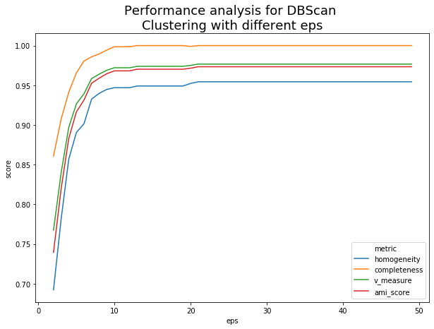

```python
plt.figure(figsize=(10, 7))
sns.lineplot(x='eps', y='score', hue="metric", data=dbs_metric)
plt.title("Performance analysis for DBScan \nClustering with different eps", fontsize = 18)
plt.savefig('8. DBScan perform.png', dpi=300, bbox_inches='tight')
```

```
  (i) Visualize the relationship between eps and number of cluster in this dataset.
```

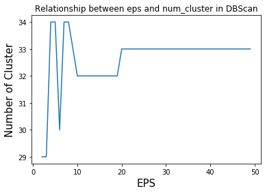

```python
plt.plot(dbs_cluster_num['eps'], dbs_cluster_num['num_cluster'])
plt.title("Relationship between eps and num_cluster in DBScan")
plt.xlabel("EPS", fontsize = 15)
plt.ylabel("Number of Cluster", fontsize = 15)
plt.savefig('8a. DBScan cluster.png', dpi=300, bbox_inches='tight')
```

```
  (j) Compare the confusion matrix with an eps value with worse performance (eps=3) and better performance (eps=21)
```

```python
dbs_metric_sorted=dbs_metric.pivot(index='eps', columns='metric', values='score').reset_index().rename_axis(None, axis=1)
dbs_metric_sorted=dbs_metric_sorted.sort_values(by=["completeness", "homogeneity", "v_measure", "ami_score"], ascending=[False, False, False, False])
dbs_metric_sorted.head(1)
```

|  | eps | ami_score | completeness | homogeneity | v_measure |
| --- | --- | --- | --- | --- | --- |
| 19 | 21 | 0.973348 | 1.0 | 0.954395 | 0.976665 |

```python
dbs_3 = cluster.DBSCAN(eps=3)
dbs_fit_3=dbs_3.fit(array_rssi)
labels_dbs_3=dbs_fit_3.labels_
X=pd.DataFrame(array_rssi)
X['cluster']=labels_dbs_3
X['target']= df_rssi['readings_group'].astype(str).str.zfill(2) + '_' + df_rssi['beacon_list']
cm_dbs3=pd.crosstab(index=X["target"], columns=X["cluster"])
cm_dbs3
```

| cluster target | -1 | 0 | 1 | 2 | 3 | 4 | 5 | 6 | 7 | 8 | 9 | 10 | 11 | 12 | 13 | 14 | 15 | 16 | 17 | 18 | 19 | 20 | 21 | 22 | 23 | 24 | 25 | 26 | 27 |
| --- | --- | --- | --- | --- | --- | --- | --- | --- | --- | --- | --- | --- | --- | --- | --- | --- | --- | --- | --- | --- | --- | --- | --- | --- | --- | --- | --- | --- | --- |
| 00_b3006 | 0 | 114 | 0 | 0 | 0 | 0 | 0 | 0 | 0 | 0 | 0 | 0 | 0 | 0 | 0 | 0 | 0 | 0 | 0 | 0 | 0 | 0 | 0 | 0 | 0 | 0 | 0 | 0 | 0 |
| 01_b3003 | 0 | 0 | 58 | 0 | 0 | 0 | 0 | 0 | 0 | 0 | 0 | 0 | 0 | 0 | 0 | 0 | 0 | 0 | 0 | 0 | 0 | 0 | 0 | 0 | 0 | 0 | 0 | 0 | 0 |
| 02_b3003 b3006 | 9 | 0 | 0 | 21 | 0 | 0 | 0 | 23 | 0 | 0 | 0 | 0 | 0 | 0 | 0 | 0 | 0 | 0 | 0 | 0 | 0 | 0 | 0 | 0 | 0 | 0 | 0 | 0 | 0 |
| 03_b3004 | 0 | 0 | 0 | 0 | 298 | 0 | 0 | 0 | 0 | 0 | 0 | 0 | 0 | 0 | 0 | 0 | 0 | 0 | 0 | 0 | 0 | 0 | 0 | 0 | 0 | 0 | 0 | 0 | 0 |
| 04_b3002 | 0 | 0 | 0 | 0 | 0 | 238 | 0 | 0 | 0 | 0 | 0 | 0 | 0 | 0 | 0 | 0 | 0 | 0 | 0 | 0 | 0 | 0 | 0 | 0 | 0 | 0 | 0 | 0 | 0 |
| 05_b3003 b3004 | 5 | 0 | 0 | 0 | 0 | 0 | 0 | 0 | 32 | 0 | 0 | 0 | 0 | 0 | 0 | 0 | 0 | 0 | 0 | 0 | 0 | 0 | 0 | 0 | 0 | 0 | 0 | 0 | 0 |
| 06_b3002 b3003 | 9 | 0 | 0 | 0 | 0 | 0 | 73 | 0 | 0 | 7 | 0 | 0 | 0 | 0 | 0 | 0 | 0 | 0 | 0 | 0 | 0 | 0 | 0 | 0 | 0 | 0 | 0 | 0 | 0 |
| 07_b3002 b3003 b3005 | 2 | 0 | 0 | 0 | 0 | 0 | 0 | 0 | 0 | 0 | 0 | 0 | 0 | 0 | 0 | 0 | 0 | 0 | 0 | 0 | 0 | 0 | 0 | 0 | 0 | 0 | 0 | 0 | 0 |
| 08_b3003 b3005 b3006 | 7 | 0 | 0 | 0 | 0 | 0 | 0 | 0 | 0 | 0 | 0 | 0 | 0 | 0 | 0 | 0 | 0 | 0 | 0 | 0 | 0 | 0 | 0 | 0 | 0 | 0 | 0 | 0 | 0 |
| 09_b3003 b3004 b3006 | 3 | 0 | 0 | 0 | 0 | 0 | 0 | 0 | 0 | 0 | 0 | 0 | 0 | 0 | 0 | 0 | 0 | 0 | 0 | 0 | 0 | 0 | 0 | 0 | 0 | 0 | 0 | 0 | 0 |
| 10_b3002 b3004 | 6 | 0 | 0 | 0 | 0 | 0 | 0 | 0 | 0 | 0 | 0 | 0 | 0 | 0 | 0 | 0 | 0 | 0 | 0 | 0 | 0 | 0 | 0 | 0 | 0 | 0 | 0 | 0 | 0 |
| 11_b3003 b3007 | 2 | 0 | 0 | 0 | 0 | 0 | 0 | 0 | 0 | 0 | 0 | 0 | 0 | 0 | 0 | 0 | 0 | 0 | 0 | 0 | 0 | 0 | 0 | 0 | 0 | 0 | 0 | 0 | 0 |
| 12_b3002 b3003 b3007 | 2 | 0 | 0 | 0 | 0 | 0 | 0 | 0 | 0 | 0 | 0 | 0 | 0 | 0 | 0 | 0 | 0 | 0 | 0 | 0 | 0 | 0 | 0 | 0 | 0 | 0 | 0 | 0 | 0 |
| 13_b3002 b3003 b3006 | 19 | 0 | 0 | 0 | 0 | 0 | 0 | 0 | 0 | 0 | 0 | 0 | 0 | 0 | 0 | 0 | 0 | 0 | 0 | 0 | 0 | 0 | 0 | 0 | 0 | 0 | 0 | 0 | 0 |
| 14_b3002 b3006 | 4 | 0 | 0 | 0 | 0 | 0 | 0 | 0 | 0 | 0 | 8 | 0 | 0 | 0 | 0 | 0 | 0 | 0 | 0 | 0 | 0 | 0 | 0 | 0 | 0 | 0 | 0 | 0 | 0 |
| 15_b3001 | 6 | 0 | 0 | 0 | 0 | 0 | 0 | 0 | 0 | 0 | 0 | 0 | 0 | 0 | 0 | 0 | 0 | 0 | 0 | 0 | 0 | 0 | 0 | 0 | 0 | 0 | 0 | 0 | 0 |
| 16_b3002 b3008 | 10 | 0 | 0 | 0 | 0 | 0 | 0 | 0 | 0 | 0 | 0 | 0 | 0 | 0 | 0 | 0 | 0 | 0 | 0 | 0 | 0 | 0 | 0 | 0 | 0 | 0 | 0 | 0 | 0 |
| 17_b3002 b3005 | 13 | 0 | 0 | 0 | 0 | 0 | 0 | 0 | 0 | 0 | 0 | 0 | 55 | 0 | 0 | 0 | 0 | 0 | 0 | 0 | 0 | 0 | 0 | 0 | 0 | 0 | 0 | 0 | 0 |
| 18_b3002 b3004 b3006 | 4 | 0 | 0 | 0 | 0 | 0 | 0 | 0 | 0 | 0 | 0 | 0 | 0 | 0 | 0 | 0 | 0 | 0 | 0 | 0 | 0 | 0 | 0 | 0 | 0 | 0 | 0 | 0 | 0 |
| 19_b3005 | 0 | 0 | 0 | 0 | 0 | 0 | 0 | 0 | 0 | 0 | 0 | 70 | 0 | 0 | 0 | 0 | 0 | 0 | 0 | 0 | 0 | 0 | 0 | 0 | 0 | 0 | 0 | 0 | 0 |
| 20_b3004 b3006 | 2 | 0 | 0 | 0 | 0 | 0 | 0 | 0 | 0 | 0 | 0 | 0 | 0 | 21 | 0 | 0 | 0 | 0 | 0 | 0 | 0 | 0 | 0 | 0 | 0 | 0 | 0 | 0 | 0 |
| 21_b3004 b3005 | 2 | 0 | 0 | 0 | 0 | 0 | 0 | 0 | 0 | 0 | 0 | 0 | 0 | 0 | 0 | 0 | 0 | 0 | 0 | 0 | 0 | 0 | 0 | 0 | 0 | 0 | 0 | 0 | 0 |
| 22_b3004 b3007 | 12 | 0 | 0 | 0 | 0 | 0 | 0 | 0 | 0 | 0 | 0 | 0 | 0 | 0 | 0 | 9 | 0 | 0 | 0 | 0 | 0 | 0 | 0 | 0 | 0 | 0 | 0 | 0 | 0 |
| 23_b3007 | 2 | 0 | 0 | 0 | 0 | 0 | 0 | 0 | 0 | 0 | 0 | 0 | 0 | 0 | 13 | 0 | 0 | 0 | 0 | 0 | 0 | 0 | 0 | 0 | 0 | 0 | 0 | 0 | 5 |
| 24_b3005 b3006 | 5 | 0 | 0 | 0 | 0 | 0 | 0 | 0 | 0 | 0 | 0 | 0 | 0 | 0 | 0 | 0 | 26 | 0 | 0 | 0 | 0 | 0 | 0 | 0 | 0 | 0 | 0 | 0 | 0 |
| 25_b3002 b3005 b3006 | 5 | 0 | 0 | 0 | 0 | 0 | 0 | 0 | 0 | 0 | 0 | 0 | 0 | 0 | 0 | 0 | 0 | 0 | 0 | 0 | 0 | 0 | 0 | 0 | 0 | 0 | 0 | 0 | 0 |
| 26_b3002 b3005 b3008 | 13 | 0 | 0 | 0 | 0 | 0 | 0 | 0 | 0 | 0 | 0 | 0 | 0 | 0 | 0 | 0 | 0 | 9 | 0 | 0 | 0 | 0 | 0 | 0 | 0 | 0 | 0 | 0 | 0 |
| 27_b3005 b3008 | 14 | 0 | 0 | 0 | 0 | 0 | 0 | 0 | 0 | 0 | 0 | 0 | 0 | 0 | 0 | 0 | 0 | 0 | 0 | 0 | 0 | 0 | 0 | 0 | 0 | 0 | 0 | 0 | 0 |
| 28_b3008 b30010 | 4 | 0 | 0 | 0 | 0 | 0 | 0 | 0 | 0 | 0 | 0 | 0 | 0 | 0 | 0 | 0 | 0 | 0 | 0 | 0 | 0 | 0 | 0 | 0 | 0 | 0 | 0 | 0 | 0 |
| 29_b3008 | 6 | 0 | 0 | 0 | 0 | 0 | 0 | 0 | 0 | 0 | 0 | 0 | 0 | 0 | 0 | 0 | 0 | 0 | 0 | 0 | 0 | 0 | 0 | 0 | 0 | 0 | 6 | 0 | 0 |
| 30_b3009 | 3 | 0 | 0 | 0 | 0 | 0 | 0 | 0 | 0 | 0 | 0 | 0 | 0 | 0 | 0 | 0 | 0 | 0 | 10 | 15 | 0 | 0 | 0 | 0 | 0 | 0 | 0 | 0 | 0 |
| 31_b30010 | 5 | 0 | 0 | 0 | 0 | 0 | 0 | 0 | 0 | 0 | 0 | 0 | 0 | 0 | 0 | 0 | 0 | 0 | 0 | 0 | 5 | 0 | 0 | 0 | 0 | 0 | 0 | 0 | 0 |
| 32_b30010 b30011 | 7 | 0 | 0 | 0 | 0 | 0 | 0 | 0 | 0 | 0 | 0 | 0 | 0 | 0 | 0 | 0 | 0 | 0 | 0 | 0 | 0 | 0 | 0 | 0 | 0 | 0 | 0 | 0 | 0 |
| 33_b30011 | 4 | 0 | 0 | 0 | 0 | 0 | 0 | 0 | 0 | 0 | 0 | 0 | 0 | 0 | 0 | 0 | 0 | 0 | 0 | 0 | 0 | 5 | 0 | 0 | 0 | 0 | 0 | 0 | 0 |
| 34_b30011 b30012 | 8 | 0 | 0 | 0 | 0 | 0 | 0 | 0 | 0 | 0 | 0 | 0 | 0 | 0 | 0 | 0 | 0 | 0 | 0 | 0 | 0 | 0 | 0 | 0 | 0 | 0 | 0 | 0 | 0 |
| 35_b30010 b30012 b30013 | 2 | 0 | 0 | 0 | 0 | 0 | 0 | 0 | 0 | 0 | 0 | 0 | 0 | 0 | 0 | 0 | 0 | 0 | 0 | 0 | 0 | 0 | 0 | 0 | 0 | 0 | 0 | 0 | 0 |
| 36_b3008 b30012 | 2 | 0 | 0 | 0 | 0 | 0 | 0 | 0 | 0 | 0 | 0 | 0 | 0 | 0 | 0 | 0 | 0 | 0 | 0 | 0 | 0 | 0 | 0 | 0 | 0 | 0 | 0 | 0 | 0 |
| 37_b30012 | 2 | 0 | 0 | 0 | 0 | 0 | 0 | 0 | 0 | 0 | 0 | 0 | 0 | 0 | 0 | 0 | 0 | 0 | 0 | 0 | 0 | 0 | 6 | 0 | 0 | 0 | 0 | 7 | 0 |
| 38_b30012 b30013 | 4 | 0 | 0 | 0 | 0 | 0 | 0 | 0 | 0 | 0 | 0 | 0 | 0 | 0 | 0 | 0 | 0 | 0 | 0 | 0 | 0 | 0 | 0 | 0 | 0 | 0 | 0 | 0 | 0 |
| 39_b30013 | 5 | 0 | 0 | 0 | 0 | 0 | 0 | 0 | 0 | 0 | 0 | 0 | 0 | 0 | 0 | 0 | 0 | 0 | 0 | 0 | 0 | 0 | 0 | 17 | 15 | 0 | 0 | 0 | 0 |
| 40_b3005 b3007 | 2 | 0 | 0 | 0 | 0 | 0 | 0 | 0 | 0 | 0 | 0 | 0 | 0 | 0 | 0 | 0 | 0 | 0 | 0 | 0 | 0 | 0 | 0 | 0 | 0 | 0 | 0 | 0 | 0 |
| 41_b3001 b3008 | 5 | 0 | 0 | 0 | 0 | 0 | 0 | 0 | 0 | 0 | 0 | 0 | 0 | 0 | 0 | 0 | 0 | 0 | 0 | 0 | 0 | 0 | 0 | 0 | 0 | 0 | 0 | 0 | 0 |
| 42_b3001 b3005 b3008 | 3 | 0 | 0 | 0 | 0 | 0 | 0 | 0 | 0 | 0 | 0 | 0 | 0 | 0 | 0 | 0 | 0 | 0 | 0 | 0 | 0 | 0 | 0 | 0 | 0 | 7 | 0 | 0 | 0 |
| 43_b3001 b3002 | 2 | 0 | 0 | 0 | 0 | 0 | 0 | 0 | 0 | 0 | 0 | 0 | 0 | 0 | 0 | 0 | 0 | 0 | 0 | 0 | 0 | 0 | 0 | 0 | 0 | 0 | 0 | 0 | 0 |
| 44_b3001 b3005 b3006 b3008 | 2 | 0 | 0 | 0 | 0 | 0 | 0 | 0 | 0 | 0 | 0 | 0 | 0 | 0 | 0 | 0 | 0 | 0 | 0 | 0 | 0 | 0 | 0 | 0 | 0 | 0 | 0 | 0 | 0 |
| 45_b3005 b3006 b3008 | 4 | 0 | 0 | 0 | 0 | 0 | 0 | 0 | 0 | 0 | 0 | 0 | 0 | 0 | 0 | 0 | 0 | 0 | 0 | 0 | 0 | 0 | 0 | 0 | 0 | 0 | 0 | 0 | 0 |
| 46_b3006 b3008 b30010 | 2 | 0 | 0 | 0 | 0 | 0 | 0 | 0 | 0 | 0 | 0 | 0 | 0 | 0 | 0 | 0 | 0 | 0 | 0 | 0 | 0 | 0 | 0 | 0 | 0 | 0 | 0 | 0 | 0 |
| 47_b3003 b3005 | 2 | 0 | 0 | 0 | 0 | 0 | 0 | 0 | 0 | 0 | 0 | 0 | 0 | 0 | 0 | 0 | 0 | 0 | 0 | 0 | 0 | 0 | 0 | 0 | 0 | 0 | 0 | 0 | 0 |
| 48_b3009 b30010 | 3 | 0 | 0 | 0 | 0 | 0 | 0 | 0 | 0 | 0 | 0 | 0 | 0 | 0 | 0 | 0 | 0 | 0 | 0 | 0 | 0 | 0 | 0 | 0 | 0 | 0 | 0 | 0 | 0 |
| 49_b30011 b30013 | 1 | 0 | 0 | 0 | 0 | 0 | 0 | 0 | 0 | 0 | 0 | 0 | 0 | 0 | 0 | 0 | 0 | 0 | 0 | 0 | 0 | 0 | 0 | 0 | 0 | 0 | 0 | 0 | 0 |
| 50_b3006 b3007 | 1 | 0 | 0 | 0 | 0 | 0 | 0 | 0 | 0 | 0 | 0 | 0 | 0 | 0 | 0 | 0 | 0 | 0 | 0 | 0 | 0 | 0 | 0 | 0 | 0 | 0 | 0 | 0 | 0 |
| 51_b3004 b3006 b3007 | 1 | 0 | 0 | 0 | 0 | 0 | 0 | 0 | 0 | 0 | 0 | 0 | 0 | 0 | 0 | 0 | 0 | 0 | 0 | 0 | 0 | 0 | 0 | 0 | 0 | 0 | 0 | 0 | 0 |
| 52_b3006 b3008 | 1 | 0 | 0 | 0 | 0 | 0 | 0 | 0 | 0 | 0 | 0 | 0 | 0 | 0 | 0 | 0 | 0 | 0 | 0 | 0 | 0 | 0 | 0 | 0 | 0 | 0 | 0 | 0 | 0 |
| 53_b3002 b3004 b3005 b3006 | 1 | 0 | 0 | 0 | 0 | 0 | 0 | 0 | 0 | 0 | 0 | 0 | 0 | 0 | 0 | 0 | 0 | 0 | 0 | 0 | 0 | 0 | 0 | 0 | 0 | 0 | 0 | 0 | 0 |
| 54_b3003 b3004 b3005 b3006 | 1 | 0 | 0 | 0 | 0 | 0 | 0 | 0 | 0 | 0 | 0 | 0 | 0 | 0 | 0 | 0 | 0 | 0 | 0 | 0 | 0 | 0 | 0 | 0 | 0 | 0 | 0 | 0 | 0 |
| 55_b3002 b3003 b3005 b3006 | 1 | 0 | 0 | 0 | 0 | 0 | 0 | 0 | 0 | 0 | 0 | 0 | 0 | 0 | 0 | 0 | 0 | 0 | 0 | 0 | 0 | 0 | 0 | 0 | 0 | 0 | 0 | 0 | 0 |
| 56_b3002 b3003 b3004 | 1 | 0 | 0 | 0 | 0 | 0 | 0 | 0 | 0 | 0 | 0 | 0 | 0 | 0 | 0 | 0 | 0 | 0 | 0 | 0 | 0 | 0 | 0 | 0 | 0 | 0 | 0 | 0 | 0 |
| 57_b3004 b3005 b3006 | 1 | 0 | 0 | 0 | 0 | 0 | 0 | 0 | 0 | 0 | 0 | 0 | 0 | 0 | 0 | 0 | 0 | 0 | 0 | 0 | 0 | 0 | 0 | 0 | 0 | 0 | 0 | 0 | 0 |
| 58_b3002 b3003 b3004 b3006 | 1 | 0 | 0 | 0 | 0 | 0 | 0 | 0 | 0 | 0 | 0 | 0 | 0 | 0 | 0 | 0 | 0 | 0 | 0 | 0 | 0 | 0 | 0 | 0 | 0 | 0 | 0 | 0 | 0 |
| 59_b3004 b3005 b3008 | 1 | 0 | 0 | 0 | 0 | 0 | 0 | 0 | 0 | 0 | 0 | 0 | 0 | 0 | 0 | 0 | 0 | 0 | 0 | 0 | 0 | 0 | 0 | 0 | 0 | 0 | 0 | 0 | 0 |
| 60_b3002 b3003 b3005 b3008 | 1 | 0 | 0 | 0 | 0 | 0 | 0 | 0 | 0 | 0 | 0 | 0 | 0 | 0 | 0 | 0 | 0 | 0 | 0 | 0 | 0 | 0 | 0 | 0 | 0 | 0 | 0 | 0 | 0 |
| 61_b3002 b3008 b30010 | 1 | 0 | 0 | 0 | 0 | 0 | 0 | 0 | 0 | 0 | 0 | 0 | 0 | 0 | 0 | 0 | 0 | 0 | 0 | 0 | 0 | 0 | 0 | 0 | 0 | 0 | 0 | 0 | 0 |
| 62_b3002 b3003 b3004 b3007 | 1 | 0 | 0 | 0 | 0 | 0 | 0 | 0 | 0 | 0 | 0 | 0 | 0 | 0 | 0 | 0 | 0 | 0 | 0 | 0 | 0 | 0 | 0 | 0 | 0 | 0 | 0 | 0 | 0 |

```python
dbs_21 = cluster.DBSCAN(eps=21)
dbs_fit_21=dbs_21.fit(array_rssi)
labels_dbs_21=dbs_fit_21.labels_
X=pd.DataFrame(array_rssi)
X['cluster']=labels_dbs_21
X['target']= df_rssi['readings_group'].astype(str).str.zfill(2) + '_' + df_rssi['beacon_list']
cm_dbs21=pd.crosstab(index=X["target"], columns=X["cluster"])
cm_dbs21
```

| cluster target | -1 | 0 | 1 | 2 | 3 | 4 | 5 | 6 | 7 | 8 | 9 | 10 | 11 | 12 | 13 | 14 | 15 | 16 | 17 | 18 | 19 | 20 | 21 | 22 | 23 | 24 | 25 | 26 | 27 | … |
| --- | --- | --- | --- | --- | --- | --- | --- | --- | --- | --- | --- | --- | --- | --- | --- | --- | --- | --- | --- | --- | --- | --- | --- | --- | --- | --- | --- | --- | --- | --- |
| 00_b3006 | 0 | 114 | 0 | 0 | 0 | 0 | 0 | 0 | 0 | 0 | 0 | 0 | 0 | 0 | 0 | 0 | 0 | 0 | 0 | 0 | 0 | 0 | 0 | 0 | 0 | 0 | 0 | 0 | 0 | … |
| 01_b3003 | 0 | 0 | 58 | 0 | 0 | 0 | 0 | 0 | 0 | 0 | 0 | 0 | 0 | 0 | 0 | 0 | 0 | 0 | 0 | 0 | 0 | 0 | 0 | 0 | 0 | 0 | 0 | 0 | 0 | … |
| 02_b3003 b3006 | 0 | 0 | 0 | 53 | 0 | 0 | 0 | 0 | 0 | 0 | 0 | 0 | 0 | 0 | 0 | 0 | 0 | 0 | 0 | 0 | 0 | 0 | 0 | 0 | 0 | 0 | 0 | 0 | 0 | … |
| 03_b3004 | 0 | 0 | 0 | 0 | 298 | 0 | 0 | 0 | 0 | 0 | 0 | 0 | 0 | 0 | 0 | 0 | 0 | 0 | 0 | 0 | 0 | 0 | 0 | 0 | 0 | 0 | 0 | 0 | 0 | … |
| 04_b3002 | 0 | 0 | 0 | 0 | 0 | 238 | 0 | 0 | 0 | 0 | 0 | 0 | 0 | 0 | 0 | 0 | 0 | 0 | 0 | 0 | 0 | 0 | 0 | 0 | 0 | 0 | 0 | 0 | 0 | … |
| 05_b3003 b3004 | 0 | 0 | 0 | 0 | 0 | 0 | 37 | 0 | 0 | 0 | 0 | 0 | 0 | 0 | 0 | 0 | 0 | 0 | 0 | 0 | 0 | 0 | 0 | 0 | 0 | 0 | 0 | 0 | 0 | … |
| 06_b3002 b3003 | 0 | 0 | 0 | 0 | 0 | 0 | 0 | 89 | 0 | 0 | 0 | 0 | 0 | 0 | 0 | 0 | 0 | 0 | 0 | 0 | 0 | 0 | 0 | 0 | 0 | 0 | 0 | 0 | 0 | … |
| 07_b3002 b3003 b3005 | 2 | 0 | 0 | 0 | 0 | 0 | 0 | 0 | 0 | 0 | 0 | 0 | 0 | 0 | 0 | 0 | 0 | 0 | 0 | 0 | 0 | 0 | 0 | 0 | 0 | 0 | 0 | 0 | 0 | … |
| 08_b3003 b3005 b3006 | 0 | 0 | 0 | 0 | 0 | 0 | 0 | 0 | 7 | 0 | 0 | 0 | 0 | 0 | 0 | 0 | 0 | 0 | 0 | 0 | 0 | 0 | 0 | 0 | 0 | 0 | 0 | 0 | 0 | … |
| 09_b3003 b3004 b3006 | 3 | 0 | 0 | 0 | 0 | 0 | 0 | 0 | 0 | 0 | 0 | 0 | 0 | 0 | 0 | 0 | 0 | 0 | 0 | 0 | 0 | 0 | 0 | 0 | 0 | 0 | 0 | 0 | 0 | … |
| 10_b3002 b3004 | 0 | 0 | 0 | 0 | 0 | 0 | 0 | 0 | 0 | 6 | 0 | 0 | 0 | 0 | 0 | 0 | 0 | 0 | 0 | 0 | 0 | 0 | 0 | 0 | 0 | 0 | 0 | 0 | 0 | … |
| 11_b3003 b3007 | 2 | 0 | 0 | 0 | 0 | 0 | 0 | 0 | 0 | 0 | 0 | 0 | 0 | 0 | 0 | 0 | 0 | 0 | 0 | 0 | 0 | 0 | 0 | 0 | 0 | 0 | 0 | 0 | 0 | … |
| 12_b3002 b3003 b3007 | 2 | 0 | 0 | 0 | 0 | 0 | 0 | 0 | 0 | 0 | 0 | 0 | 0 | 0 | 0 | 0 | 0 | 0 | 0 | 0 | 0 | 0 | 0 | 0 | 0 | 0 | 0 | 0 | 0 | … |
| 13_b3002 b3003 b3006 | 0 | 0 | 0 | 0 | 0 | 0 | 0 | 0 | 0 | 0 | 19 | 0 | 0 | 0 | 0 | 0 | 0 | 0 | 0 | 0 | 0 | 0 | 0 | 0 | 0 | 0 | 0 | 0 | 0 | … |
| 14_b3002 b3006 | 0 | 0 | 0 | 0 | 0 | 0 | 0 | 0 | 0 | 0 | 0 | 12 | 0 | 0 | 0 | 0 | 0 | 0 | 0 | 0 | 0 | 0 | 0 | 0 | 0 | 0 | 0 | 0 | 0 | … |
| 15_b3001 | 0 | 0 | 0 | 0 | 0 | 0 | 0 | 0 | 0 | 0 | 0 | 0 | 6 | 0 | 0 | 0 | 0 | 0 | 0 | 0 | 0 | 0 | 0 | 0 | 0 | 0 | 0 | 0 | 0 | … |
| 16_b3002 b3008 | 0 | 0 | 0 | 0 | 0 | 0 | 0 | 0 | 0 | 0 | 0 | 0 | 0 | 10 | 0 | 0 | 0 | 0 | 0 | 0 | 0 | 0 | 0 | 0 | 0 | 0 | 0 | 0 | 0 | … |
| 17_b3002 b3005 | 0 | 0 | 0 | 0 | 0 | 0 | 0 | 0 | 0 | 0 | 0 | 0 | 0 | 0 | 68 | 0 | 0 | 0 | 0 | 0 | 0 | 0 | 0 | 0 | 0 | 0 | 0 | 0 | 0 | … |
| 18_b3002 b3004 b3006 | 4 | 0 | 0 | 0 | 0 | 0 | 0 | 0 | 0 | 0 | 0 | 0 | 0 | 0 | 0 | 0 | 0 | 0 | 0 | 0 | 0 | 0 | 0 | 0 | 0 | 0 | 0 | 0 | 0 | … |
| 19_b3005 | 0 | 0 | 0 | 0 | 0 | 0 | 0 | 0 | 0 | 0 | 0 | 0 | 0 | 0 | 0 | 70 | 0 | 0 | 0 | 0 | 0 | 0 | 0 | 0 | 0 | 0 | 0 | 0 | 0 | … |
| 20_b3004 b3006 | 0 | 0 | 0 | 0 | 0 | 0 | 0 | 0 | 0 | 0 | 0 | 0 | 0 | 0 | 0 | 0 | 23 | 0 | 0 | 0 | 0 | 0 | 0 | 0 | 0 | 0 | 0 | 0 | 0 | … |
| 21_b3004 b3005 | 2 | 0 | 0 | 0 | 0 | 0 | 0 | 0 | 0 | 0 | 0 | 0 | 0 | 0 | 0 | 0 | 0 | 0 | 0 | 0 | 0 | 0 | 0 | 0 | 0 | 0 | 0 | 0 | 0 | … |
| 22_b3004 b3007 | 0 | 0 | 0 | 0 | 0 | 0 | 0 | 0 | 0 | 0 | 0 | 0 | 0 | 0 | 0 | 0 | 0 | 21 | 0 | 0 | 0 | 0 | 0 | 0 | 0 | 0 | 0 | 0 | 0 | … |
| 23_b3007 | 0 | 0 | 0 | 0 | 0 | 0 | 0 | 0 | 0 | 0 | 0 | 0 | 0 | 0 | 0 | 0 | 0 | 0 | 20 | 0 | 0 | 0 | 0 | 0 | 0 | 0 | 0 | 0 | 0 | … |
| 24_b3005 b3006 | 0 | 0 | 0 | 0 | 0 | 0 | 0 | 0 | 0 | 0 | 0 | 0 | 0 | 0 | 0 | 0 | 0 | 0 | 0 | 31 | 0 | 0 | 0 | 0 | 0 | 0 | 0 | 0 | 0 | … |
| 25_b3002 b3005 b3006 | 0 | 0 | 0 | 0 | 0 | 0 | 0 | 0 | 0 | 0 | 0 | 0 | 0 | 0 | 0 | 0 | 0 | 0 | 0 | 0 | 5 | 0 | 0 | 0 | 0 | 0 | 0 | 0 | 0 | … |
| 26_b3002 b3005 b3008 | 0 | 0 | 0 | 0 | 0 | 0 | 0 | 0 | 0 | 0 | 0 | 0 | 0 | 0 | 0 | 0 | 0 | 0 | 0 | 0 | 0 | 22 | 0 | 0 | 0 | 0 | 0 | 0 | 0 | … |
| 27_b3005 b3008 | 0 | 0 | 0 | 0 | 0 | 0 | 0 | 0 | 0 | 0 | 0 | 0 | 0 | 0 | 0 | 0 | 0 | 0 | 0 | 0 | 0 | 0 | 14 | 0 | 0 | 0 | 0 | 0 | 0 | … |
| 28_b3008 b30010 | 4 | 0 | 0 | 0 | 0 | 0 | 0 | 0 | 0 | 0 | 0 | 0 | 0 | 0 | 0 | 0 | 0 | 0 | 0 | 0 | 0 | 0 | 0 | 0 | 0 | 0 | 0 | 0 | 0 | … |
| 29_b3008 | 0 | 0 | 0 | 0 | 0 | 0 | 0 | 0 | 0 | 0 | 0 | 0 | 0 | 0 | 0 | 0 | 0 | 0 | 0 | 0 | 0 | 0 | 0 | 12 | 0 | 0 | 0 | 0 | 0 | … |
| 30_b3009 | 0 | 0 | 0 | 0 | 0 | 0 | 0 | 0 | 0 | 0 | 0 | 0 | 0 | 0 | 0 | 0 | 0 | 0 | 0 | 0 | 0 | 0 | 0 | 0 | 28 | 0 | 0 | 0 | 0 | … |
| 31_b30010 | 0 | 0 | 0 | 0 | 0 | 0 | 0 | 0 | 0 | 0 | 0 | 0 | 0 | 0 | 0 | 0 | 0 | 0 | 0 | 0 | 0 | 0 | 0 | 0 | 0 | 10 | 0 | 0 | 0 | … |
| 32_b30010 b30011 | 0 | 0 | 0 | 0 | 0 | 0 | 0 | 0 | 0 | 0 | 0 | 0 | 0 | 0 | 0 | 0 | 0 | 0 | 0 | 0 | 0 | 0 | 0 | 0 | 0 | 0 | 7 | 0 | 0 | … |
| 33_b30011 | 0 | 0 | 0 | 0 | 0 | 0 | 0 | 0 | 0 | 0 | 0 | 0 | 0 | 0 | 0 | 0 | 0 | 0 | 0 | 0 | 0 | 0 | 0 | 0 | 0 | 0 | 0 | 9 | 0 | … |
| 34_b30011 b30012 | 0 | 0 | 0 | 0 | 0 | 0 | 0 | 0 | 0 | 0 | 0 | 0 | 0 | 0 | 0 | 0 | 0 | 0 | 0 | 0 | 0 | 0 | 0 | 0 | 0 | 0 | 0 | 0 | 8 | … |
| 35_b30010 b30012 b30013 | 2 | 0 | 0 | 0 | 0 | 0 | 0 | 0 | 0 | 0 | 0 | 0 | 0 | 0 | 0 | 0 | 0 | 0 | 0 | 0 | 0 | 0 | 0 | 0 | 0 | 0 | 0 | 0 | 0 | … |
| 36_b3008 b30012 | 2 | 0 | 0 | 0 | 0 | 0 | 0 | 0 | 0 | 0 | 0 | 0 | 0 | 0 | 0 | 0 | 0 | 0 | 0 | 0 | 0 | 0 | 0 | 0 | 0 | 0 | 0 | 0 | 0 | … |
| 37_b30012 | 0 | 0 | 0 | 0 | 0 | 0 | 0 | 0 | 0 | 0 | 0 | 0 | 0 | 0 | 0 | 0 | 0 | 0 | 0 | 0 | 0 | 0 | 0 | 0 | 0 | 0 | 0 | 0 | 0 | … |
| 38_b30012 b30013 | 4 | 0 | 0 | 0 | 0 | 0 | 0 | 0 | 0 | 0 | 0 | 0 | 0 | 0 | 0 | 0 | 0 | 0 | 0 | 0 | 0 | 0 | 0 | 0 | 0 | 0 | 0 | 0 | 0 | … |
| 39_b30013 | 0 | 0 | 0 | 0 | 0 | 0 | 0 | 0 | 0 | 0 | 0 | 0 | 0 | 0 | 0 | 0 | 0 | 0 | 0 | 0 | 0 | 0 | 0 | 0 | 0 | 0 | 0 | 0 | 0 | … |
| 40_b3005 b3007 | 2 | 0 | 0 | 0 | 0 | 0 | 0 | 0 | 0 | 0 | 0 | 0 | 0 | 0 | 0 | 0 | 0 | 0 | 0 | 0 | 0 | 0 | 0 | 0 | 0 | 0 | 0 | 0 | 0 | … |
| 41_b3001 b3008 | 0 | 0 | 0 | 0 | 0 | 0 | 0 | 0 | 0 | 0 | 0 | 0 | 0 | 0 | 0 | 0 | 0 | 0 | 0 | 0 | 0 | 0 | 0 | 0 | 0 | 0 | 0 | 0 | 0 | … |
| 42_b3001 b3005 b3008 | 0 | 0 | 0 | 0 | 0 | 0 | 0 | 0 | 0 | 0 | 0 | 0 | 0 | 0 | 0 | 0 | 0 | 0 | 0 | 0 | 0 | 0 | 0 | 0 | 0 | 0 | 0 | 0 | 0 | … |
| 43_b3001 b3002 | 2 | 0 | 0 | 0 | 0 | 0 | 0 | 0 | 0 | 0 | 0 | 0 | 0 | 0 | 0 | 0 | 0 | 0 | 0 | 0 | 0 | 0 | 0 | 0 | 0 | 0 | 0 | 0 | 0 | … |
| 44_b3001 b3005 b3006 b3008 | 2 | 0 | 0 | 0 | 0 | 0 | 0 | 0 | 0 | 0 | 0 | 0 | 0 | 0 | 0 | 0 | 0 | 0 | 0 | 0 | 0 | 0 | 0 | 0 | 0 | 0 | 0 | 0 | 0 | … |
| 45_b3005 b3006 b3008 | 4 | 0 | 0 | 0 | 0 | 0 | 0 | 0 | 0 | 0 | 0 | 0 | 0 | 0 | 0 | 0 | 0 | 0 | 0 | 0 | 0 | 0 | 0 | 0 | 0 | 0 | 0 | 0 | 0 | … |
| 46_b3006 b3008 b30010 | 2 | 0 | 0 | 0 | 0 | 0 | 0 | 0 | 0 | 0 | 0 | 0 | 0 | 0 | 0 | 0 | 0 | 0 | 0 | 0 | 0 | 0 | 0 | 0 | 0 | 0 | 0 | 0 | 0 | … |
| 47_b3003 b3005 | 2 | 0 | 0 | 0 | 0 | 0 | 0 | 0 | 0 | 0 | 0 | 0 | 0 | 0 | 0 | 0 | 0 | 0 | 0 | 0 | 0 | 0 | 0 | 0 | 0 | 0 | 0 | 0 | 0 | … |
| 48_b3009 b30010 | 3 | 0 | 0 | 0 | 0 | 0 | 0 | 0 | 0 | 0 | 0 | 0 | 0 | 0 | 0 | 0 | 0 | 0 | 0 | 0 | 0 | 0 | 0 | 0 | 0 | 0 | 0 | 0 | 0 | … |
| 49_b30011 b30013 | 1 | 0 | 0 | 0 | 0 | 0 | 0 | 0 | 0 | 0 | 0 | 0 | 0 | 0 | 0 | 0 | 0 | 0 | 0 | 0 | 0 | 0 | 0 | 0 | 0 | 0 | 0 | 0 | 0 | … |
| 50_b3006 b3007 | 1 | 0 | 0 | 0 | 0 | 0 | 0 | 0 | 0 | 0 | 0 | 0 | 0 | 0 | 0 | 0 | 0 | 0 | 0 | 0 | 0 | 0 | 0 | 0 | 0 | 0 | 0 | 0 | 0 | … |
| 51_b3004 b3006 b3007 | 1 | 0 | 0 | 0 | 0 | 0 | 0 | 0 | 0 | 0 | 0 | 0 | 0 | 0 | 0 | 0 | 0 | 0 | 0 | 0 | 0 | 0 | 0 | 0 | 0 | 0 | 0 | 0 | 0 | … |
| 52_b3006 b3008 | 1 | 0 | 0 | 0 | 0 | 0 | 0 | 0 | 0 | 0 | 0 | 0 | 0 | 0 | 0 | 0 | 0 | 0 | 0 | 0 | 0 | 0 | 0 | 0 | 0 | 0 | 0 | 0 | 0 | … |
| 53_b3002 b3004 b3005 b3006 | 1 | 0 | 0 | 0 | 0 | 0 | 0 | 0 | 0 | 0 | 0 | 0 | 0 | 0 | 0 | 0 | 0 | 0 | 0 | 0 | 0 | 0 | 0 | 0 | 0 | 0 | 0 | 0 | 0 | … |
| 54_b3003 b3004 b3005 b3006 | 1 | 0 | 0 | 0 | 0 | 0 | 0 | 0 | 0 | 0 | 0 | 0 | 0 | 0 | 0 | 0 | 0 | 0 | 0 | 0 | 0 | 0 | 0 | 0 | 0 | 0 | 0 | 0 | 0 | … |
| 55_b3002 b3003 b3005 b3006 | 1 | 0 | 0 | 0 | 0 | 0 | 0 | 0 | 0 | 0 | 0 | 0 | 0 | 0 | 0 | 0 | 0 | 0 | 0 | 0 | 0 | 0 | 0 | 0 | 0 | 0 | 0 | 0 | 0 | … |
| 56_b3002 b3003 b3004 | 1 | 0 | 0 | 0 | 0 | 0 | 0 | 0 | 0 | 0 | 0 | 0 | 0 | 0 | 0 | 0 | 0 | 0 | 0 | 0 | 0 | 0 | 0 | 0 | 0 | 0 | 0 | 0 | 0 | … |
| 57_b3004 b3005 b3006 | 1 | 0 | 0 | 0 | 0 | 0 | 0 | 0 | 0 | 0 | 0 | 0 | 0 | 0 | 0 | 0 | 0 | 0 | 0 | 0 | 0 | 0 | 0 | 0 | 0 | 0 | 0 | 0 | 0 | … |
| 58_b3002 b3003 b3004 b3006 | 1 | 0 | 0 | 0 | 0 | 0 | 0 | 0 | 0 | 0 | 0 | 0 | 0 | 0 | 0 | 0 | 0 | 0 | 0 | 0 | 0 | 0 | 0 | 0 | 0 | 0 | 0 | 0 | 0 | … |
| 59_b3004 b3005 b3008 | 1 | 0 | 0 | 0 | 0 | 0 | 0 | 0 | 0 | 0 | 0 | 0 | 0 | 0 | 0 | 0 | 0 | 0 | 0 | 0 | 0 | 0 | 0 | 0 | 0 | 0 | 0 | 0 | 0 | … |
| 60_b3002 b3003 b3005 b3008 | 1 | 0 | 0 | 0 | 0 | 0 | 0 | 0 | 0 | 0 | 0 | 0 | 0 | 0 | 0 | 0 | 0 | 0 | 0 | 0 | 0 | 0 | 0 | 0 | 0 | 0 | 0 | 0 | 0 | … |
| 61_b3002 b3008 b30010 | 1 | 0 | 0 | 0 | 0 | 0 | 0 | 0 | 0 | 0 | 0 | 0 | 0 | 0 | 0 | 0 | 0 | 0 | 0 | 0 | 0 | 0 | 0 | 0 | 0 | 0 | 0 | 0 | 0 | … |
| 62_b3002 b3003 b3004 b3007 | 1 | 0 | 0 | 0 | 0 | 0 | 0 | 0 | 0 | 0 | 0 | 0 | 0 | 0 | 0 | 0 | 0 | 0 | 0 | 0 | 0 | 0 | 0 | 0 | 0 | 0 | 0 | 0 | 0 | … |

```python
cm_dbs3.to_csv('c2. cm_dbs3.csv', index=True)
cm_dbs21.to_csv('c3. cm_dbs21.csv', index=True)
```

We found that for DBscan clustering on this dataset, performance boosts at eps = 5 and becomes flatten after eps = 21. (21 is the smallest eps with the best score in 4 metrics) When we compare the confusion matrix for 3 different models with different eps values (3, 13 and 21), we have the following findings:

Eps = 3: Beside the outliner group, DBScan groups all the data into 28 clusters, all these clusters belong to only one single target group. (Thus, Homogeneity should be 1, however, due to the outliner group, it still scores low in homogeneity). 58 out of 63 target groups would have some members grouped as outliners. 17 out of these 58 groups have been split by DBScan into 2 or more groups (for example, group 06_b3002 b3003, 73 members have been clustered to group 5 and 7 members to group 8, 9 members to outliners) , while 41 of them are entirely classified as outliners (for example, group 13_b3002 b3003 b3006 with 19 members have been classified entirely as outliner)

Eps = 13: DBScan groups all the data into 31 clusters, all these clusters belong only to one single target group. No target groups have been split into separate clusters and 32 groups are entirely classified as outliners.

Eps = 21: DBScan groups all the data into 32 clusters, all these clusters belong only to one single target group. No target groups have been split into separate clusters and 31 groups are entirely classified as outliners. Only difference compare to eps=13 is group 32_b30010 b30011, with 7 members have been entirely identified as an individual cluster instead of outliner. All the outliners are now with less than 5 members in the target groups. (4 target groups with 4 members, 2 target groups with 3 members and the rests are just 2 or 1 member(s)).

### 2. K-Mean Clustering

```
  (a) Construct the `averageDistance` to centroids graph to determine optimal `n_cluster` value for K-Mean clustering.  The function is customized for this dataset as 13 beacons indicate there would be 13 dimensions for calculating the distance to the centroids.
```

```python
def avgDistToCentroids(dataArray, k_dist):
    k_disValues = np.zeros(len(k_dist))

    for cur_k_ind in range(0,len(k_dist)):
        #try each k value, starting from the first one with index 0
        K_rssi = k_dist[cur_k_ind]
        km_rssi = KMeans(n_clusters=K_rssi)
        labels_rssi=km_rssi.fit(dataArray).labels_
    #    print(cur_k_ind, K_rssi, km_rssi)

        #calculate the corresponding average distance to the centriods for this k value
        sumDis = 0
        for ind in range(0,n_readings):

            q1 = dataArray[ind, 0]
            q2 = dataArray[ind, 1]
            q3 = dataArray[ind, 2]
            q4 = dataArray[ind, 3]
            q5 = dataArray[ind, 4]
            q6 = dataArray[ind, 5]
            q7 = dataArray[ind, 6]
            q8 = dataArray[ind, 7]
            q9 = dataArray[ind, 8]
            q10 = dataArray[ind, 9]
            q11 = dataArray[ind, 10]
            q12 = dataArray[ind, 11]
            q13 = dataArray[ind, 12]

            p1 = km_rssi.cluster_centers_[labels_rssi[ind], 0]
            p2 = km_rssi.cluster_centers_[labels_rssi[ind], 1]
            p3 = km_rssi.cluster_centers_[labels_rssi[ind], 2]
            p4 = km_rssi.cluster_centers_[labels_rssi[ind], 3]
            p5 = km_rssi.cluster_centers_[labels_rssi[ind], 4]
            p6 = km_rssi.cluster_centers_[labels_rssi[ind], 5]
            p7 = km_rssi.cluster_centers_[labels_rssi[ind], 6]
            p8 = km_rssi.cluster_centers_[labels_rssi[ind], 7]
            p9 = km_rssi.cluster_centers_[labels_rssi[ind], 8]
            p10 = km_rssi.cluster_centers_[labels_rssi[ind], 9]
            p11 = km_rssi.cluster_centers_[labels_rssi[ind], 10]
            p12 = km_rssi.cluster_centers_[labels_rssi[ind], 11]
            p13 = km_rssi.cluster_centers_[labels_rssi[ind], 12]

            dis = math.sqrt(math.pow(q1 - p1, 2) + math.pow(q2 - p2, 2) + math.pow(q3 - p3, 2) + math.pow(q4 - p4, 2)+ math.pow(q5 - p5, 2)+ math.pow(q6 - p6, 2)+ math.pow(q7 - p7, 2)+ math.pow(q8 - p8, 2)+ math.pow(q9 - p9, 2)+ math.pow(q10 - p10, 2)+ math.pow(q11 - p11, 2)+ math.pow(q12 - p12, 2)+ math.pow(q13 - p13, 2))

            sumDis = sumDis + dis

        k_disValues[cur_k_ind] = sumDis/n_readings
    return k_disValues
```

```python
k_dist = range(20,105)
print(k_dist)

k_disValues = avgDistToCentroids(array_rssi, k_dist)
```

```
range(20, 105)
```

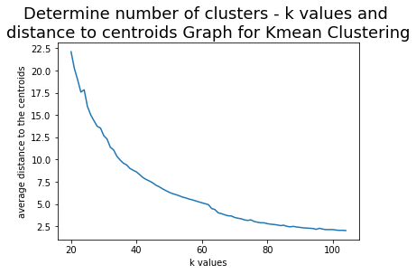

```python
plt.plot(k_dist, k_disValues)
plt.xlabel('k values')
plt.ylabel('average distance to the centroids')
plt.title("Determine number of clusters - k values and \ndistance to centroids Graph for Kmean Clustering", fontsize = 18)
plt.savefig('9. avgDistCentroids.png', dpi=300, bbox_inches='tight')
```

From the graph, the curve is slowly decreasing and we cannot find any distinctive elbow that would intervene and flatten the trend. Thus I have chosen n_cluster=60 as an arbitrary value to fit our original data (a matrix with n_readings x n_beacons contains RSSI measurements) into kmean clustering.

```
(b) Perform KMeans clustering by fitting `aray_rssi` with n_clusters=60
```

```python
km_rssi = KMeans(n_clusters=60, random_state=999)
km_fit = km_rssi.fit(array_rssi)
```

```
(c) Find the label from the fitted model.  Check the number of clusters in the label.
```

```python
labels_kmean=km_fit.labels_
np.unique(labels_kmean, return_counts = True)
```

```
(array([ 0,  1,  2,  3,  4,  5,  6,  7,  8,  9, 10, 11, 12, 13, 14, 15, 16,
        17, 18, 19, 20, 21, 22, 23, 24, 25, 26, 27, 28, 29, 30, 31, 32, 33,
        34, 35, 36, 37, 38, 39, 40, 41, 42, 43, 44, 45, 46, 47, 48, 49, 50,
        51, 52, 53, 54, 55, 56, 57, 58, 59]),
 array([238,  53, 298,  70,  15,  37, 114,  58,  89,  28,   8,  20,  31,
         68,  23,  23,   7,  12,  37,  12,  19,  15,   6,  21,  10,  10,
         10,   5,   9,   2,   7,   6,   4,   4,   5,   2,   4,   2,   3,
          4,   2,   2,   2,   2,   3,   3,   2,   2,   1,   1,   1,   1,
          1,   1,   2,   1,   1,   1,   1,   1], dtype=int64))
```

```
(d)  Construct a dataframe `X` which will compare the cluster labels with the target (which is the readings_group in `df_rssi` dataframe)
```

```python
X=pd.DataFrame(array_rssi)
X['cluster']=labels_kmean
X['target']= df_rssi['readings_group'].astype(str).str.zfill(2) + '_' + df_rssi['beacon_list']
X.head(10)
```

|  | 0 | 1 | 2 | 3 | 4 | 5 | 6 | 7 | 8 | 9 | 10 | 11 | 12 | cluster | target |
| --- | --- | --- | --- | --- | --- | --- | --- | --- | --- | --- | --- | --- | --- | --- | --- |
| 0 | -200 | -200 | -200 | -200 | -200 | -78 | -200 | -200 | -200 | -200 | -200 | -200 | -200 | 6 | 00_b3006 |
| 1 | -200 | -200 | -200 | -200 | -200 | -78 | -200 | -200 | -200 | -200 | -200 | -200 | -200 | 6 | 00_b3006 |
| 2 | -200 | -200 | -200 | -200 | -200 | -77 | -200 | -200 | -200 | -200 | -200 | -200 | -200 | 6 | 00_b3006 |
| 3 | -200 | -200 | -200 | -200 | -200 | -77 | -200 | -200 | -200 | -200 | -200 | -200 | -200 | 6 | 00_b3006 |
| 4 | -200 | -200 | -200 | -200 | -200 | -77 | -200 | -200 | -200 | -200 | -200 | -200 | -200 | 6 | 00_b3006 |
| 5 | -200 | -200 | -82 | -200 | -200 | -200 | -200 | -200 | -200 | -200 | -200 | -200 | -200 | 7 | 01_b3003 |
| 6 | -200 | -200 | -80 | -200 | -200 | -77 | -200 | -200 | -200 | -200 | -200 | -200 | -200 | 1 | 02_b3003 b3006 |
| 7 | -200 | -200 | -86 | -200 | -200 | -200 | -200 | -200 | -200 | -200 | -200 | -200 | -200 | 7 | 01_b3003 |
| 8 | -200 | -200 | -200 | -75 | -200 | -200 | -200 | -200 | -200 | -200 | -200 | -200 | -200 | 2 | 03_b3004 |
| 9 | -200 | -200 | -200 | -75 | -200 | -200 | -200 | -200 | -200 | -200 | -200 | -200 | -200 | 2 | 03_b3004 |

```
(e)  Use the crosstab function to construct a confusion matrix.
```

```python
cm_kmean=pd.crosstab(index=X["target"], columns=X["cluster"])
cm_kmean
```

| cluster target | 0 | 1 | 2 | 3 | 4 | 5 | 6 | 7 | 8 | 9 | 10 | 11 | 12 | 13 | 14 | 15 | 16 | 17 | 18 | 19 | 20 | 21 | 22 | 23 | 24 | 25 | 26 | 27 | 28 | … |
| --- | --- | --- | --- | --- | --- | --- | --- | --- | --- | --- | --- | --- | --- | --- | --- | --- | --- | --- | --- | --- | --- | --- | --- | --- | --- | --- | --- | --- | --- | --- |
| 00_b3006 | 0 | 0 | 0 | 0 | 0 | 0 | 114 | 0 | 0 | 0 | 0 | 0 | 0 | 0 | 0 | 0 | 0 | 0 | 0 | 0 | 0 | 0 | 0 | 0 | 0 | 0 | 0 | 0 | 0 | … |
| 01_b3003 | 0 | 0 | 0 | 0 | 0 | 0 | 0 | 58 | 0 | 0 | 0 | 0 | 0 | 0 | 0 | 0 | 0 | 0 | 0 | 0 | 0 | 0 | 0 | 0 | 0 | 0 | 0 | 0 | 0 | … |
| 02_b3003 b3006 | 0 | 53 | 0 | 0 | 0 | 0 | 0 | 0 | 0 | 0 | 0 | 0 | 0 | 0 | 0 | 0 | 0 | 0 | 0 | 0 | 0 | 0 | 0 | 0 | 0 | 0 | 0 | 0 | 0 | … |
| 03_b3004 | 0 | 0 | 298 | 0 | 0 | 0 | 0 | 0 | 0 | 0 | 0 | 0 | 0 | 0 | 0 | 0 | 0 | 0 | 0 | 0 | 0 | 0 | 0 | 0 | 0 | 0 | 0 | 0 | 0 | … |
| 04_b3002 | 238 | 0 | 0 | 0 | 0 | 0 | 0 | 0 | 0 | 0 | 0 | 0 | 0 | 0 | 0 | 0 | 0 | 0 | 0 | 0 | 0 | 0 | 0 | 0 | 0 | 0 | 0 | 0 | 0 | … |
| 05_b3003 b3004 | 0 | 0 | 0 | 0 | 0 | 0 | 0 | 0 | 0 | 0 | 0 | 0 | 0 | 0 | 0 | 0 | 0 | 0 | 37 | 0 | 0 | 0 | 0 | 0 | 0 | 0 | 0 | 0 | 0 | … |
| 06_b3002 b3003 | 0 | 0 | 0 | 0 | 0 | 0 | 0 | 0 | 89 | 0 | 0 | 0 | 0 | 0 | 0 | 0 | 0 | 0 | 0 | 0 | 0 | 0 | 0 | 0 | 0 | 0 | 0 | 0 | 0 | … |
| 07_b3002 b3003 b3005 | 0 | 0 | 0 | 0 | 0 | 0 | 0 | 0 | 0 | 0 | 0 | 0 | 0 | 0 | 0 | 0 | 0 | 0 | 0 | 0 | 0 | 0 | 0 | 0 | 0 | 0 | 0 | 0 | 0 | … |
| 08_b3003 b3005 b3006 | 0 | 0 | 0 | 0 | 0 | 0 | 0 | 0 | 0 | 0 | 0 | 0 | 0 | 0 | 0 | 0 | 0 | 0 | 0 | 0 | 0 | 0 | 0 | 0 | 0 | 0 | 0 | 0 | 0 | … |
| 09_b3003 b3004 b3006 | 0 | 0 | 0 | 0 | 0 | 0 | 0 | 0 | 0 | 0 | 0 | 0 | 0 | 0 | 0 | 0 | 0 | 0 | 0 | 0 | 0 | 0 | 0 | 0 | 0 | 0 | 0 | 0 | 0 | … |
| 10_b3002 b3004 | 0 | 0 | 0 | 0 | 0 | 0 | 0 | 0 | 0 | 0 | 0 | 0 | 0 | 0 | 0 | 0 | 0 | 0 | 0 | 0 | 0 | 0 | 0 | 0 | 0 | 0 | 0 | 0 | 0 | … |
| 11_b3003 b3007 | 0 | 0 | 0 | 0 | 0 | 0 | 0 | 0 | 0 | 0 | 0 | 0 | 0 | 0 | 0 | 0 | 0 | 0 | 0 | 0 | 0 | 0 | 0 | 0 | 0 | 0 | 0 | 0 | 0 | … |
| 12_b3002 b3003 b3007 | 0 | 0 | 0 | 0 | 0 | 0 | 0 | 0 | 0 | 0 | 0 | 0 | 0 | 0 | 0 | 0 | 0 | 0 | 0 | 0 | 0 | 0 | 0 | 0 | 0 | 0 | 0 | 0 | 0 | … |
| 13_b3002 b3003 b3006 | 0 | 0 | 0 | 0 | 0 | 0 | 0 | 0 | 0 | 0 | 0 | 0 | 0 | 0 | 0 | 0 | 0 | 0 | 0 | 0 | 19 | 0 | 0 | 0 | 0 | 0 | 0 | 0 | 0 | … |
| 14_b3002 b3006 | 0 | 0 | 0 | 0 | 0 | 0 | 0 | 0 | 0 | 0 | 0 | 0 | 0 | 0 | 0 | 0 | 0 | 0 | 0 | 12 | 0 | 0 | 0 | 0 | 0 | 0 | 0 | 0 | 0 | … |
| 15_b3001 | 0 | 0 | 0 | 0 | 0 | 0 | 0 | 0 | 0 | 0 | 0 | 0 | 0 | 0 | 0 | 0 | 0 | 0 | 0 | 0 | 0 | 0 | 6 | 0 | 0 | 0 | 0 | 0 | 0 | … |
| 16_b3002 b3008 | 0 | 0 | 0 | 0 | 0 | 0 | 0 | 0 | 0 | 0 | 0 | 0 | 0 | 0 | 0 | 0 | 0 | 0 | 0 | 0 | 0 | 0 | 0 | 0 | 0 | 0 | 10 | 0 | 0 | … |
| 17_b3002 b3005 | 0 | 0 | 0 | 0 | 0 | 0 | 0 | 0 | 0 | 0 | 0 | 0 | 0 | 68 | 0 | 0 | 0 | 0 | 0 | 0 | 0 | 0 | 0 | 0 | 0 | 0 | 0 | 0 | 0 | … |
| 18_b3002 b3004 b3006 | 0 | 0 | 0 | 0 | 0 | 0 | 0 | 0 | 0 | 0 | 0 | 0 | 0 | 0 | 0 | 0 | 0 | 0 | 0 | 0 | 0 | 0 | 0 | 0 | 0 | 0 | 0 | 0 | 0 | … |
| 19_b3005 | 0 | 0 | 0 | 70 | 0 | 0 | 0 | 0 | 0 | 0 | 0 | 0 | 0 | 0 | 0 | 0 | 0 | 0 | 0 | 0 | 0 | 0 | 0 | 0 | 0 | 0 | 0 | 0 | 0 | … |
| 20_b3004 b3006 | 0 | 0 | 0 | 0 | 0 | 0 | 0 | 0 | 0 | 0 | 0 | 0 | 0 | 0 | 23 | 0 | 0 | 0 | 0 | 0 | 0 | 0 | 0 | 0 | 0 | 0 | 0 | 0 | 0 | … |
| 21_b3004 b3005 | 0 | 0 | 0 | 0 | 0 | 0 | 0 | 0 | 0 | 0 | 0 | 0 | 0 | 0 | 0 | 0 | 0 | 0 | 0 | 0 | 0 | 0 | 0 | 0 | 0 | 0 | 0 | 0 | 0 | … |
| 22_b3004 b3007 | 0 | 0 | 0 | 0 | 0 | 0 | 0 | 0 | 0 | 0 | 0 | 0 | 0 | 0 | 0 | 0 | 0 | 0 | 0 | 0 | 0 | 0 | 0 | 21 | 0 | 0 | 0 | 0 | 0 | … |
| 23_b3007 | 0 | 0 | 0 | 0 | 0 | 0 | 0 | 0 | 0 | 0 | 0 | 20 | 0 | 0 | 0 | 0 | 0 | 0 | 0 | 0 | 0 | 0 | 0 | 0 | 0 | 0 | 0 | 0 | 0 | … |
| 24_b3005 b3006 | 0 | 0 | 0 | 0 | 0 | 0 | 0 | 0 | 0 | 0 | 0 | 0 | 31 | 0 | 0 | 0 | 0 | 0 | 0 | 0 | 0 | 0 | 0 | 0 | 0 | 0 | 0 | 0 | 0 | … |
| 25_b3002 b3005 b3006 | 0 | 0 | 0 | 0 | 0 | 0 | 0 | 0 | 0 | 0 | 0 | 0 | 0 | 0 | 0 | 0 | 0 | 0 | 0 | 0 | 0 | 0 | 0 | 0 | 0 | 0 | 0 | 5 | 0 | … |
| 26_b3002 b3005 b3008 | 0 | 0 | 0 | 0 | 0 | 0 | 0 | 0 | 0 | 0 | 0 | 0 | 0 | 0 | 0 | 22 | 0 | 0 | 0 | 0 | 0 | 0 | 0 | 0 | 0 | 0 | 0 | 0 | 0 | … |
| 27_b3005 b3008 | 0 | 0 | 0 | 0 | 14 | 0 | 0 | 0 | 0 | 0 | 0 | 0 | 0 | 0 | 0 | 0 | 0 | 0 | 0 | 0 | 0 | 0 | 0 | 0 | 0 | 0 | 0 | 0 | 0 | … |
| 28_b3008 b30010 | 0 | 0 | 0 | 0 | 0 | 0 | 0 | 0 | 0 | 0 | 0 | 0 | 0 | 0 | 0 | 0 | 0 | 0 | 0 | 0 | 0 | 0 | 0 | 0 | 0 | 0 | 0 | 0 | 0 | … |
| 29_b3008 | 0 | 0 | 0 | 0 | 0 | 0 | 0 | 0 | 0 | 0 | 0 | 0 | 0 | 0 | 0 | 0 | 0 | 12 | 0 | 0 | 0 | 0 | 0 | 0 | 0 | 0 | 0 | 0 | 0 | … |
| 30_b3009 | 0 | 0 | 0 | 0 | 0 | 0 | 0 | 0 | 0 | 28 | 0 | 0 | 0 | 0 | 0 | 0 | 0 | 0 | 0 | 0 | 0 | 0 | 0 | 0 | 0 | 0 | 0 | 0 | 0 | … |
| 31_b30010 | 0 | 0 | 0 | 0 | 0 | 0 | 0 | 0 | 0 | 0 | 0 | 0 | 0 | 0 | 0 | 0 | 0 | 0 | 0 | 0 | 0 | 0 | 0 | 0 | 0 | 10 | 0 | 0 | 0 | … |
| 32_b30010 b30011 | 0 | 0 | 0 | 0 | 0 | 0 | 0 | 0 | 0 | 0 | 0 | 0 | 0 | 0 | 0 | 0 | 7 | 0 | 0 | 0 | 0 | 0 | 0 | 0 | 0 | 0 | 0 | 0 | 0 | … |
| 33_b30011 | 0 | 0 | 0 | 0 | 0 | 0 | 0 | 0 | 0 | 0 | 0 | 0 | 0 | 0 | 0 | 0 | 0 | 0 | 0 | 0 | 0 | 0 | 0 | 0 | 0 | 0 | 0 | 0 | 9 | … |
| 34_b30011 b30012 | 0 | 0 | 0 | 0 | 0 | 0 | 0 | 0 | 0 | 0 | 8 | 0 | 0 | 0 | 0 | 0 | 0 | 0 | 0 | 0 | 0 | 0 | 0 | 0 | 0 | 0 | 0 | 0 | 0 | … |
| 35_b30010 b30012 b30013 | 0 | 0 | 0 | 0 | 0 | 0 | 0 | 0 | 0 | 0 | 0 | 0 | 0 | 0 | 0 | 0 | 0 | 0 | 0 | 0 | 0 | 0 | 0 | 0 | 0 | 0 | 0 | 0 | 0 | … |
| 36_b3008 b30012 | 0 | 0 | 0 | 0 | 0 | 0 | 0 | 0 | 0 | 0 | 0 | 0 | 0 | 0 | 0 | 0 | 0 | 0 | 0 | 0 | 0 | 0 | 0 | 0 | 0 | 0 | 0 | 0 | 0 | … |
| 37_b30012 | 0 | 0 | 0 | 0 | 0 | 0 | 0 | 0 | 0 | 0 | 0 | 0 | 0 | 0 | 0 | 0 | 0 | 0 | 0 | 0 | 0 | 15 | 0 | 0 | 0 | 0 | 0 | 0 | 0 | … |
| 38_b30012 b30013 | 0 | 0 | 0 | 0 | 0 | 0 | 0 | 0 | 0 | 0 | 0 | 0 | 0 | 0 | 0 | 0 | 0 | 0 | 0 | 0 | 0 | 0 | 0 | 0 | 0 | 0 | 0 | 0 | 0 | … |
| 39_b30013 | 0 | 0 | 0 | 0 | 0 | 37 | 0 | 0 | 0 | 0 | 0 | 0 | 0 | 0 | 0 | 0 | 0 | 0 | 0 | 0 | 0 | 0 | 0 | 0 | 0 | 0 | 0 | 0 | 0 | … |
| 40_b3005 b3007 | 0 | 0 | 0 | 0 | 0 | 0 | 0 | 0 | 0 | 0 | 0 | 0 | 0 | 0 | 0 | 0 | 0 | 0 | 0 | 0 | 0 | 0 | 0 | 0 | 0 | 0 | 0 | 0 | 0 | … |
| 41_b3001 b3008 | 0 | 0 | 0 | 0 | 0 | 0 | 0 | 0 | 0 | 0 | 0 | 0 | 0 | 0 | 0 | 0 | 0 | 0 | 0 | 0 | 0 | 0 | 0 | 0 | 0 | 0 | 0 | 0 | 0 | … |
| 42_b3001 b3005 b3008 | 0 | 0 | 0 | 0 | 0 | 0 | 0 | 0 | 0 | 0 | 0 | 0 | 0 | 0 | 0 | 0 | 0 | 0 | 0 | 0 | 0 | 0 | 0 | 0 | 10 | 0 | 0 | 0 | 0 | … |
| 43_b3001 b3002 | 0 | 0 | 0 | 0 | 0 | 0 | 0 | 0 | 0 | 0 | 0 | 0 | 0 | 0 | 0 | 0 | 0 | 0 | 0 | 0 | 0 | 0 | 0 | 0 | 0 | 0 | 0 | 0 | 0 | … |
| 44_b3001 b3005 b3006 b3008 | 0 | 0 | 0 | 0 | 0 | 0 | 0 | 0 | 0 | 0 | 0 | 0 | 0 | 0 | 0 | 0 | 0 | 0 | 0 | 0 | 0 | 0 | 0 | 0 | 0 | 0 | 0 | 0 | 0 | … |
| 45_b3005 b3006 b3008 | 0 | 0 | 0 | 0 | 0 | 0 | 0 | 0 | 0 | 0 | 0 | 0 | 0 | 0 | 0 | 0 | 0 | 0 | 0 | 0 | 0 | 0 | 0 | 0 | 0 | 0 | 0 | 0 | 0 | … |
| 46_b3006 b3008 b30010 | 0 | 0 | 0 | 0 | 0 | 0 | 0 | 0 | 0 | 0 | 0 | 0 | 0 | 0 | 0 | 0 | 0 | 0 | 0 | 0 | 0 | 0 | 0 | 0 | 0 | 0 | 0 | 0 | 0 | … |
| 47_b3003 b3005 | 0 | 0 | 0 | 0 | 0 | 0 | 0 | 0 | 0 | 0 | 0 | 0 | 0 | 0 | 0 | 0 | 0 | 0 | 0 | 0 | 0 | 0 | 0 | 0 | 0 | 0 | 0 | 0 | 0 | … |
| 48_b3009 b30010 | 0 | 0 | 0 | 0 | 0 | 0 | 0 | 0 | 0 | 0 | 0 | 0 | 0 | 0 | 0 | 0 | 0 | 0 | 0 | 0 | 0 | 0 | 0 | 0 | 0 | 0 | 0 | 0 | 0 | … |
| 49_b30011 b30013 | 0 | 0 | 0 | 0 | 0 | 0 | 0 | 0 | 0 | 0 | 0 | 0 | 0 | 0 | 0 | 0 | 0 | 0 | 0 | 0 | 0 | 0 | 0 | 0 | 0 | 0 | 0 | 0 | 0 | … |
| 50_b3006 b3007 | 0 | 0 | 0 | 0 | 0 | 0 | 0 | 0 | 0 | 0 | 0 | 0 | 0 | 0 | 0 | 0 | 0 | 0 | 0 | 0 | 0 | 0 | 0 | 0 | 0 | 0 | 0 | 0 | 0 | … |
| 51_b3004 b3006 b3007 | 0 | 0 | 0 | 0 | 0 | 0 | 0 | 0 | 0 | 0 | 0 | 0 | 0 | 0 | 0 | 0 | 0 | 0 | 0 | 0 | 0 | 0 | 0 | 0 | 0 | 0 | 0 | 0 | 0 | … |
| 52_b3006 b3008 | 0 | 0 | 0 | 0 | 0 | 0 | 0 | 0 | 0 | 0 | 0 | 0 | 0 | 0 | 0 | 0 | 0 | 0 | 0 | 0 | 0 | 0 | 0 | 0 | 0 | 0 | 0 | 0 | 0 | … |
| 53_b3002 b3004 b3005 b3006 | 0 | 0 | 0 | 0 | 0 | 0 | 0 | 0 | 0 | 0 | 0 | 0 | 0 | 0 | 0 | 0 | 0 | 0 | 0 | 0 | 0 | 0 | 0 | 0 | 0 | 0 | 0 | 0 | 0 | … |
| 54_b3003 b3004 b3005 b3006 | 0 | 0 | 0 | 0 | 0 | 0 | 0 | 0 | 0 | 0 | 0 | 0 | 0 | 0 | 0 | 0 | 0 | 0 | 0 | 0 | 0 | 0 | 0 | 0 | 0 | 0 | 0 | 0 | 0 | … |
| 55_b3002 b3003 b3005 b3006 | 0 | 0 | 0 | 0 | 0 | 0 | 0 | 0 | 0 | 0 | 0 | 0 | 0 | 0 | 0 | 0 | 0 | 0 | 0 | 0 | 0 | 0 | 0 | 0 | 0 | 0 | 0 | 0 | 0 | … |
| 56_b3002 b3003 b3004 | 0 | 0 | 0 | 0 | 0 | 0 | 0 | 0 | 0 | 0 | 0 | 0 | 0 | 0 | 0 | 0 | 0 | 0 | 0 | 0 | 0 | 0 | 0 | 0 | 0 | 0 | 0 | 0 | 0 | … |
| 57_b3004 b3005 b3006 | 0 | 0 | 0 | 0 | 0 | 0 | 0 | 0 | 0 | 0 | 0 | 0 | 0 | 0 | 0 | 0 | 0 | 0 | 0 | 0 | 0 | 0 | 0 | 0 | 0 | 0 | 0 | 0 | 0 | … |
| 58_b3002 b3003 b3004 b3006 | 0 | 0 | 0 | 0 | 0 | 0 | 0 | 0 | 0 | 0 | 0 | 0 | 0 | 0 | 0 | 0 | 0 | 0 | 0 | 0 | 0 | 0 | 0 | 0 | 0 | 0 | 0 | 0 | 0 | … |
| 59_b3004 b3005 b3008 | 0 | 0 | 0 | 0 | 1 | 0 | 0 | 0 | 0 | 0 | 0 | 0 | 0 | 0 | 0 | 0 | 0 | 0 | 0 | 0 | 0 | 0 | 0 | 0 | 0 | 0 | 0 | 0 | 0 | … |
| 60_b3002 b3003 b3005 b3008 | 0 | 0 | 0 | 0 | 0 | 0 | 0 | 0 | 0 | 0 | 0 | 0 | 0 | 0 | 0 | 1 | 0 | 0 | 0 | 0 | 0 | 0 | 0 | 0 | 0 | 0 | 0 | 0 | 0 | … |
| 61_b3002 b3008 b30010 | 0 | 0 | 0 | 0 | 0 | 0 | 0 | 0 | 0 | 0 | 0 | 0 | 0 | 0 | 0 | 0 | 0 | 0 | 0 | 0 | 0 | 0 | 0 | 0 | 0 | 0 | 0 | 0 | 0 | … |
| 62_b3002 b3003 b3004 b3007 | 0 | 0 | 0 | 0 | 0 | 0 | 0 | 0 | 0 | 0 | 0 | 0 | 0 | 0 | 0 | 0 | 0 | 0 | 0 | 0 | 0 | 0 | 0 | 0 | 0 | 0 | 0 | 0 | 0 | … |

We observed there is no outliner group in k-mean clustering. From the above table, it shows that 00_b3006 has been clustered to group 6, 00_b3003 has been clustered to group 7 by Kmeans etc.

```
  (f) Run some of the clustering metrics from sklearn to compare the target and the fitted model
```

```python
print("adjusted_mutal_info :", metrics.adjusted_mutual_info_score(label_target, labels_kmean))
print("adjusted_rand_score :", metrics.adjusted_rand_score(label_target, labels_kmean))
print("normalized_mutal_info :", metrics.normalized_mutual_info_score(label_target, labels_kmean))
print("fowles_mallows_score :", metrics.fowlkes_mallows_score(label_target, labels_kmean))
print("silhouette_score :", metrics.silhouette_score(array_rssi, labels_kmean))
print("calinski_harabasz_score :", metrics.calinski_harabasz_score(array_rssi, labels_kmean))
print("davies_bouldin_score :", metrics.davies_bouldin_score(array_rssi, labels_kmean))
print("homogeneity_completeness_v_measure :", metrics.homogeneity_completeness_v_measure(label_target, labels_kmean))
```

```
adjusted_mutal_info : 0.9986451761078916
adjusted_rand_score : 0.9997780173318629
normalized_mutal_info : 0.9988439153787477
fowles_mallows_score : 0.9997988470741014
silhouette_score : 0.9326333754127222
calinski_harabasz_score : 6843.723843035605
davies_bouldin_score : 0.25020485861620845
homogeneity_completeness_v_measure : (0.9976905007340793, 1.0000000000000002, 0.9988439153787477)
```

```
(g)  Similar to DB scan, we are also evaluating with the same 4 metrics, we use the hill climbing method to apply a for loop to fit the model repeatedly with n_clusters ranges from 15 to 80 and obtain the homogeneity_completeness_v_measure metric of each model and save it into the dataframe `kmeans_metric`.
```

```python
kmeans_metric=pd.DataFrame(columns=["n_cluster", "metric","score"])

for cluster_num in range(15, 80):
    km_rssi = KMeans(n_clusters=cluster_num, random_state=999)
    labels_kmean=km_rssi.fit(array_rssi).labels_
    a = metrics.adjusted_mutual_info_score(label_target, labels_kmean)
    h,c,v= metrics.homogeneity_completeness_v_measure(label_target, labels_kmean)
    kmeans_metric.loc[len(kmeans_metric)] = [cluster_num, "homogeneity", h]
    kmeans_metric.loc[len(kmeans_metric)] = [cluster_num, "completeness", c]
    kmeans_metric.loc[len(kmeans_metric)] = [cluster_num, "v_measure", v]
    kmeans_metric.loc[len(kmeans_metric)] = [cluster_num, "ami_score", a]
```

```
  (h) Visualize the `kmeans_metric`.
```

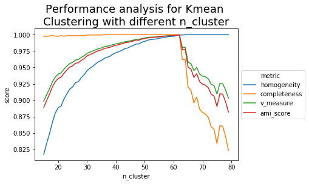

```python
g=sns.lineplot(x='n_cluster', y='score', hue="metric", data=kmeans_metric)
g.legend(loc='center left', bbox_to_anchor=(1, 0.5), ncol=1)
plt.title("Performance analysis for Kmean \nClustering with different n_cluster", fontsize = 18)
plt.savefig('10. KMean perform.png', dpi=300, bbox_inches='tight')
```

[output not shown]

```python
kmeans_metric_sorted=kmeans_metric.pivot(index='n_cluster', columns='metric', values='score').reset_index().rename_axis(None, axis=1)
kmeans_metric_sorted=kmeans_metric_sorted.sort_values(by=["completeness", "homogeneity", "v_measure", "ami_score"], ascending=[False, False, False, False])
kmeans_metric_sorted.head(5)
```

|  | n_cluster | ami_score | completeness | homogeneity | v_measure |
| --- | --- | --- | --- | --- | --- |
| 47 | 62 | 0.999733 | 1.0 | 0.999545 | 0.999773 |
| 45 | 60 | 0.998645 | 1.0 | 0.997691 | 0.998844 |
| 44 | 59 | 0.998452 | 1.0 | 0.997360 | 0.998678 |
| 43 | 58 | 0.998185 | 1.0 | 0.996906 | 0.998450 |
| 42 | 57 | 0.997763 | 1.0 | 0.996185 | 0.998089 |

```python
km_rssi_62 = KMeans(n_clusters=62, random_state=999)
km_fit_62 = km_rssi_62.fit(array_rssi)
labels_kmean_62=km_fit_62.labels_
X=pd.DataFrame(array_rssi)
X['cluster']=labels_kmean_62
X['target']= df_rssi['readings_group'].astype(str).str.zfill(2) + '_' + df_rssi['beacon_list']
cm_kmean_62= pd.crosstab(index=X["target"], columns=X["cluster"])
cm_kmean_62
```

| cluster target | 0 | 1 | 2 | 3 | 4 | 5 | 6 | 7 | 8 | 9 | 10 | 11 | 12 | 13 | 14 | 15 | 16 | 17 | 18 | 19 | 20 | 21 | 22 | 23 | 24 | 25 | 26 | 27 | 28 | … |
| --- | --- | --- | --- | --- | --- | --- | --- | --- | --- | --- | --- | --- | --- | --- | --- | --- | --- | --- | --- | --- | --- | --- | --- | --- | --- | --- | --- | --- | --- | --- |
| 00_b3006 | 0 | 0 | 114 | 0 | 0 | 0 | 0 | 0 | 0 | 0 | 0 | 0 | 0 | 0 | 0 | 0 | 0 | 0 | 0 | 0 | 0 | 0 | 0 | 0 | 0 | 0 | 0 | 0 | 0 | … |
| 01_b3003 | 0 | 0 | 0 | 0 | 0 | 0 | 0 | 0 | 0 | 0 | 0 | 58 | 0 | 0 | 0 | 0 | 0 | 0 | 0 | 0 | 0 | 0 | 0 | 0 | 0 | 0 | 0 | 0 | 0 | … |
| 02_b3003 b3006 | 0 | 0 | 0 | 0 | 0 | 0 | 53 | 0 | 0 | 0 | 0 | 0 | 0 | 0 | 0 | 0 | 0 | 0 | 0 | 0 | 0 | 0 | 0 | 0 | 0 | 0 | 0 | 0 | 0 | … |
| 03_b3004 | 0 | 298 | 0 | 0 | 0 | 0 | 0 | 0 | 0 | 0 | 0 | 0 | 0 | 0 | 0 | 0 | 0 | 0 | 0 | 0 | 0 | 0 | 0 | 0 | 0 | 0 | 0 | 0 | 0 | … |
| 04_b3002 | 0 | 0 | 0 | 238 | 0 | 0 | 0 | 0 | 0 | 0 | 0 | 0 | 0 | 0 | 0 | 0 | 0 | 0 | 0 | 0 | 0 | 0 | 0 | 0 | 0 | 0 | 0 | 0 | 0 | … |
| 05_b3003 b3004 | 0 | 0 | 0 | 0 | 0 | 0 | 0 | 0 | 0 | 0 | 0 | 0 | 0 | 0 | 37 | 0 | 0 | 0 | 0 | 0 | 0 | 0 | 0 | 0 | 0 | 0 | 0 | 0 | 0 | … |
| 06_b3002 b3003 | 0 | 0 | 0 | 0 | 89 | 0 | 0 | 0 | 0 | 0 | 0 | 0 | 0 | 0 | 0 | 0 | 0 | 0 | 0 | 0 | 0 | 0 | 0 | 0 | 0 | 0 | 0 | 0 | 0 | … |
| 07_b3002 b3003 b3005 | 0 | 0 | 0 | 0 | 0 | 0 | 0 | 0 | 0 | 0 | 0 | 0 | 0 | 0 | 0 | 0 | 0 | 0 | 0 | 0 | 0 | 0 | 0 | 0 | 0 | 0 | 0 | 0 | 0 | … |
| 08_b3003 b3005 b3006 | 0 | 0 | 0 | 0 | 0 | 0 | 0 | 0 | 0 | 0 | 0 | 0 | 0 | 0 | 0 | 0 | 0 | 0 | 0 | 0 | 0 | 0 | 0 | 0 | 7 | 0 | 0 | 0 | 0 | … |
| 09_b3003 b3004 b3006 | 0 | 0 | 0 | 0 | 0 | 0 | 0 | 0 | 0 | 0 | 0 | 0 | 0 | 0 | 0 | 0 | 0 | 0 | 0 | 0 | 0 | 0 | 0 | 0 | 0 | 0 | 0 | 0 | 0 | … |
| 10_b3002 b3004 | 0 | 0 | 0 | 0 | 0 | 0 | 0 | 0 | 0 | 0 | 0 | 0 | 0 | 0 | 0 | 0 | 0 | 0 | 0 | 0 | 0 | 0 | 0 | 0 | 0 | 0 | 0 | 0 | 0 | … |
| 11_b3003 b3007 | 0 | 0 | 0 | 0 | 0 | 0 | 0 | 0 | 0 | 0 | 0 | 0 | 0 | 0 | 0 | 0 | 0 | 0 | 0 | 0 | 0 | 0 | 0 | 0 | 0 | 0 | 0 | 0 | 0 | … |
| 12_b3002 b3003 b3007 | 0 | 0 | 0 | 0 | 0 | 0 | 0 | 0 | 0 | 0 | 0 | 0 | 0 | 0 | 0 | 0 | 0 | 0 | 0 | 0 | 0 | 0 | 0 | 0 | 0 | 0 | 0 | 0 | 0 | … |
| 13_b3002 b3003 b3006 | 0 | 0 | 0 | 0 | 0 | 0 | 0 | 0 | 0 | 0 | 0 | 0 | 0 | 0 | 0 | 0 | 0 | 0 | 0 | 0 | 0 | 0 | 0 | 0 | 0 | 0 | 19 | 0 | 0 | … |
| 14_b3002 b3006 | 0 | 0 | 0 | 0 | 0 | 0 | 0 | 0 | 0 | 0 | 0 | 0 | 0 | 0 | 0 | 0 | 0 | 0 | 0 | 0 | 0 | 0 | 0 | 0 | 0 | 0 | 0 | 12 | 0 | … |
| 15_b3001 | 0 | 0 | 0 | 0 | 0 | 0 | 0 | 0 | 0 | 0 | 0 | 0 | 0 | 0 | 0 | 0 | 0 | 0 | 0 | 0 | 0 | 0 | 0 | 0 | 0 | 0 | 0 | 0 | 0 | … |
| 16_b3002 b3008 | 0 | 0 | 0 | 0 | 0 | 0 | 0 | 0 | 0 | 0 | 0 | 0 | 0 | 0 | 0 | 0 | 0 | 0 | 0 | 0 | 0 | 0 | 0 | 0 | 0 | 10 | 0 | 0 | 0 | … |
| 17_b3002 b3005 | 68 | 0 | 0 | 0 | 0 | 0 | 0 | 0 | 0 | 0 | 0 | 0 | 0 | 0 | 0 | 0 | 0 | 0 | 0 | 0 | 0 | 0 | 0 | 0 | 0 | 0 | 0 | 0 | 0 | … |
| 18_b3002 b3004 b3006 | 0 | 0 | 0 | 0 | 0 | 0 | 0 | 0 | 0 | 0 | 0 | 0 | 0 | 0 | 0 | 0 | 0 | 0 | 0 | 0 | 0 | 0 | 0 | 0 | 0 | 0 | 0 | 0 | 0 | … |
| 19_b3005 | 0 | 0 | 0 | 0 | 0 | 70 | 0 | 0 | 0 | 0 | 0 | 0 | 0 | 0 | 0 | 0 | 0 | 0 | 0 | 0 | 0 | 0 | 0 | 0 | 0 | 0 | 0 | 0 | 0 | … |
| 20_b3004 b3006 | 0 | 0 | 0 | 0 | 0 | 0 | 0 | 0 | 0 | 0 | 0 | 0 | 0 | 0 | 0 | 0 | 0 | 0 | 0 | 23 | 0 | 0 | 0 | 0 | 0 | 0 | 0 | 0 | 0 | … |
| 21_b3004 b3005 | 0 | 0 | 0 | 0 | 0 | 0 | 0 | 0 | 0 | 0 | 0 | 0 | 0 | 0 | 0 | 0 | 0 | 0 | 0 | 0 | 0 | 0 | 0 | 0 | 0 | 0 | 0 | 0 | 0 | … |
| 22_b3004 b3007 | 0 | 0 | 0 | 0 | 0 | 0 | 0 | 0 | 0 | 0 | 21 | 0 | 0 | 0 | 0 | 0 | 0 | 0 | 0 | 0 | 0 | 0 | 0 | 0 | 0 | 0 | 0 | 0 | 0 | … |
| 23_b3007 | 0 | 0 | 0 | 0 | 0 | 0 | 0 | 0 | 0 | 0 | 0 | 0 | 0 | 0 | 0 | 0 | 0 | 0 | 20 | 0 | 0 | 0 | 0 | 0 | 0 | 0 | 0 | 0 | 0 | … |
| 24_b3005 b3006 | 0 | 0 | 0 | 0 | 0 | 0 | 0 | 0 | 0 | 0 | 0 | 0 | 0 | 0 | 0 | 31 | 0 | 0 | 0 | 0 | 0 | 0 | 0 | 0 | 0 | 0 | 0 | 0 | 0 | … |
| 25_b3002 b3005 b3006 | 0 | 0 | 0 | 0 | 0 | 0 | 0 | 0 | 0 | 0 | 0 | 0 | 0 | 0 | 0 | 0 | 0 | 0 | 0 | 0 | 0 | 0 | 0 | 0 | 0 | 0 | 0 | 0 | 0 | … |
| 26_b3002 b3005 b3008 | 0 | 0 | 0 | 0 | 0 | 0 | 0 | 0 | 0 | 0 | 0 | 0 | 0 | 0 | 0 | 0 | 0 | 22 | 0 | 0 | 0 | 0 | 0 | 0 | 0 | 0 | 0 | 0 | 0 | … |
| 27_b3005 b3008 | 0 | 0 | 0 | 0 | 0 | 0 | 0 | 0 | 0 | 14 | 0 | 0 | 0 | 0 | 0 | 0 | 0 | 0 | 0 | 0 | 0 | 0 | 0 | 0 | 0 | 0 | 0 | 0 | 0 | … |
| 28_b3008 b30010 | 0 | 0 | 0 | 0 | 0 | 0 | 0 | 0 | 0 | 0 | 0 | 0 | 0 | 0 | 0 | 0 | 0 | 0 | 0 | 0 | 0 | 0 | 0 | 0 | 0 | 0 | 0 | 0 | 0 | … |
| 29_b3008 | 0 | 0 | 0 | 0 | 0 | 0 | 0 | 0 | 0 | 0 | 0 | 0 | 0 | 0 | 0 | 0 | 0 | 0 | 0 | 0 | 12 | 0 | 0 | 0 | 0 | 0 | 0 | 0 | 0 | … |
| 30_b3009 | 0 | 0 | 0 | 0 | 0 | 0 | 0 | 0 | 0 | 0 | 0 | 0 | 0 | 28 | 0 | 0 | 0 | 0 | 0 | 0 | 0 | 0 | 0 | 0 | 0 | 0 | 0 | 0 | 0 | … |
| 31_b30010 | 0 | 0 | 0 | 0 | 0 | 0 | 0 | 0 | 0 | 0 | 0 | 0 | 0 | 0 | 0 | 0 | 0 | 0 | 0 | 0 | 0 | 0 | 10 | 0 | 0 | 0 | 0 | 0 | 0 | … |
| 32_b30010 b30011 | 0 | 0 | 0 | 0 | 0 | 0 | 0 | 0 | 7 | 0 | 0 | 0 | 0 | 0 | 0 | 0 | 0 | 0 | 0 | 0 | 0 | 0 | 0 | 0 | 0 | 0 | 0 | 0 | 0 | … |
| 33_b30011 | 0 | 0 | 0 | 0 | 0 | 0 | 0 | 0 | 0 | 0 | 0 | 0 | 0 | 0 | 0 | 0 | 0 | 0 | 0 | 0 | 0 | 9 | 0 | 0 | 0 | 0 | 0 | 0 | 0 | … |
| 34_b30011 b30012 | 0 | 0 | 0 | 0 | 0 | 0 | 0 | 0 | 0 | 0 | 0 | 0 | 0 | 0 | 0 | 0 | 0 | 0 | 0 | 0 | 0 | 0 | 0 | 0 | 0 | 0 | 0 | 0 | 8 | … |
| 35_b30010 b30012 b30013 | 0 | 0 | 0 | 0 | 0 | 0 | 0 | 0 | 0 | 0 | 0 | 0 | 0 | 0 | 0 | 0 | 0 | 0 | 0 | 0 | 0 | 0 | 0 | 0 | 0 | 0 | 0 | 0 | 0 | … |
| 36_b3008 b30012 | 0 | 0 | 0 | 0 | 0 | 0 | 0 | 0 | 0 | 0 | 0 | 0 | 0 | 0 | 0 | 0 | 0 | 0 | 0 | 0 | 0 | 0 | 0 | 0 | 0 | 0 | 0 | 0 | 0 | … |
| 37_b30012 | 0 | 0 | 0 | 0 | 0 | 0 | 0 | 0 | 0 | 0 | 0 | 0 | 15 | 0 | 0 | 0 | 0 | 0 | 0 | 0 | 0 | 0 | 0 | 0 | 0 | 0 | 0 | 0 | 0 | … |
| 38_b30012 b30013 | 0 | 0 | 0 | 0 | 0 | 0 | 0 | 0 | 0 | 0 | 0 | 0 | 0 | 0 | 0 | 0 | 0 | 0 | 0 | 0 | 0 | 0 | 0 | 0 | 0 | 0 | 0 | 0 | 0 | … |
| 39_b30013 | 0 | 0 | 0 | 0 | 0 | 0 | 0 | 37 | 0 | 0 | 0 | 0 | 0 | 0 | 0 | 0 | 0 | 0 | 0 | 0 | 0 | 0 | 0 | 0 | 0 | 0 | 0 | 0 | 0 | … |
| 40_b3005 b3007 | 0 | 0 | 0 | 0 | 0 | 0 | 0 | 0 | 0 | 0 | 0 | 0 | 0 | 0 | 0 | 0 | 0 | 0 | 0 | 0 | 0 | 0 | 0 | 0 | 0 | 0 | 0 | 0 | 0 | … |
| 41_b3001 b3008 | 0 | 0 | 0 | 0 | 0 | 0 | 0 | 0 | 0 | 0 | 0 | 0 | 0 | 0 | 0 | 0 | 5 | 0 | 0 | 0 | 0 | 0 | 0 | 0 | 0 | 0 | 0 | 0 | 0 | … |
| 42_b3001 b3005 b3008 | 0 | 0 | 0 | 0 | 0 | 0 | 0 | 0 | 0 | 0 | 0 | 0 | 0 | 0 | 0 | 0 | 0 | 0 | 0 | 0 | 0 | 0 | 0 | 10 | 0 | 0 | 0 | 0 | 0 | … |
| 43_b3001 b3002 | 0 | 0 | 0 | 0 | 0 | 0 | 0 | 0 | 0 | 0 | 0 | 0 | 0 | 0 | 0 | 0 | 0 | 0 | 0 | 0 | 0 | 0 | 0 | 0 | 0 | 0 | 0 | 0 | 0 | … |
| 44_b3001 b3005 b3006 b3008 | 0 | 0 | 0 | 0 | 0 | 0 | 0 | 0 | 0 | 0 | 0 | 0 | 0 | 0 | 0 | 0 | 0 | 0 | 0 | 0 | 0 | 0 | 0 | 0 | 0 | 0 | 0 | 0 | 0 | … |
| 45_b3005 b3006 b3008 | 0 | 0 | 0 | 0 | 0 | 0 | 0 | 0 | 0 | 0 | 0 | 0 | 0 | 0 | 0 | 0 | 0 | 0 | 0 | 0 | 0 | 0 | 0 | 0 | 0 | 0 | 0 | 0 | 0 | … |
| 46_b3006 b3008 b30010 | 0 | 0 | 0 | 0 | 0 | 0 | 0 | 0 | 0 | 0 | 0 | 0 | 0 | 0 | 0 | 0 | 0 | 0 | 0 | 0 | 0 | 0 | 0 | 0 | 0 | 0 | 0 | 0 | 0 | … |
| 47_b3003 b3005 | 0 | 0 | 0 | 0 | 0 | 0 | 0 | 0 | 0 | 0 | 0 | 0 | 0 | 0 | 0 | 0 | 0 | 0 | 0 | 0 | 0 | 0 | 0 | 0 | 0 | 0 | 0 | 0 | 0 | … |
| 48_b3009 b30010 | 0 | 0 | 0 | 0 | 0 | 0 | 0 | 0 | 0 | 0 | 0 | 0 | 0 | 0 | 0 | 0 | 0 | 0 | 0 | 0 | 0 | 0 | 0 | 0 | 0 | 0 | 0 | 0 | 0 | … |
| 49_b30011 b30013 | 0 | 0 | 0 | 0 | 0 | 0 | 0 | 0 | 0 | 0 | 0 | 0 | 0 | 0 | 0 | 0 | 0 | 0 | 0 | 0 | 0 | 0 | 0 | 0 | 0 | 0 | 0 | 0 | 0 | … |
| 50_b3006 b3007 | 0 | 0 | 0 | 0 | 0 | 0 | 0 | 0 | 0 | 0 | 0 | 0 | 0 | 0 | 0 | 0 | 0 | 0 | 0 | 0 | 0 | 0 | 0 | 0 | 0 | 0 | 0 | 0 | 0 | … |
| 51_b3004 b3006 b3007 | 0 | 0 | 0 | 0 | 0 | 0 | 0 | 0 | 0 | 0 | 0 | 0 | 0 | 0 | 0 | 0 | 0 | 0 | 0 | 0 | 0 | 0 | 0 | 0 | 0 | 0 | 0 | 0 | 0 | … |
| 52_b3006 b3008 | 0 | 0 | 0 | 0 | 0 | 0 | 0 | 0 | 0 | 0 | 0 | 0 | 0 | 0 | 0 | 0 | 0 | 0 | 0 | 0 | 0 | 0 | 0 | 0 | 0 | 0 | 0 | 0 | 0 | … |
| 53_b3002 b3004 b3005 b3006 | 0 | 0 | 0 | 0 | 0 | 0 | 0 | 0 | 0 | 0 | 0 | 0 | 0 | 0 | 0 | 0 | 0 | 0 | 0 | 0 | 0 | 0 | 0 | 0 | 0 | 0 | 0 | 0 | 0 | … |
| 54_b3003 b3004 b3005 b3006 | 0 | 0 | 0 | 0 | 0 | 0 | 0 | 0 | 0 | 0 | 0 | 0 | 0 | 0 | 0 | 0 | 0 | 0 | 0 | 0 | 0 | 0 | 0 | 0 | 0 | 0 | 0 | 0 | 0 | … |
| 55_b3002 b3003 b3005 b3006 | 0 | 0 | 0 | 0 | 0 | 0 | 0 | 0 | 0 | 0 | 0 | 0 | 0 | 0 | 0 | 0 | 0 | 0 | 0 | 0 | 0 | 0 | 0 | 0 | 0 | 0 | 0 | 0 | 0 | … |
| 56_b3002 b3003 b3004 | 0 | 0 | 0 | 0 | 0 | 0 | 0 | 0 | 0 | 0 | 0 | 0 | 0 | 0 | 0 | 0 | 0 | 0 | 0 | 0 | 0 | 0 | 0 | 0 | 0 | 0 | 0 | 0 | 0 | … |
| 57_b3004 b3005 b3006 | 0 | 0 | 0 | 0 | 0 | 0 | 0 | 0 | 0 | 0 | 0 | 0 | 0 | 0 | 0 | 0 | 0 | 0 | 0 | 0 | 0 | 0 | 0 | 0 | 0 | 0 | 0 | 0 | 0 | … |
| 58_b3002 b3003 b3004 b3006 | 0 | 0 | 0 | 0 | 0 | 0 | 0 | 0 | 0 | 0 | 0 | 0 | 0 | 0 | 0 | 0 | 0 | 0 | 0 | 0 | 0 | 0 | 0 | 0 | 0 | 0 | 0 | 0 | 0 | … |
| 59_b3004 b3005 b3008 | 0 | 0 | 0 | 0 | 0 | 0 | 0 | 0 | 0 | 0 | 0 | 0 | 0 | 0 | 0 | 0 | 0 | 0 | 0 | 0 | 0 | 0 | 0 | 0 | 0 | 0 | 0 | 0 | 0 | … |
| 60_b3002 b3003 b3005 b3008 | 0 | 0 | 0 | 0 | 0 | 0 | 0 | 0 | 0 | 0 | 0 | 0 | 0 | 0 | 0 | 0 | 0 | 0 | 0 | 0 | 0 | 0 | 0 | 0 | 0 | 0 | 0 | 0 | 0 | … |
| 61_b3002 b3008 b30010 | 0 | 0 | 0 | 0 | 0 | 0 | 0 | 0 | 0 | 0 | 0 | 0 | 0 | 0 | 0 | 0 | 0 | 0 | 0 | 0 | 0 | 0 | 0 | 0 | 0 | 0 | 0 | 0 | 0 | … |
| 62_b3002 b3003 b3004 b3007 | 0 | 0 | 0 | 0 | 0 | 0 | 0 | 0 | 0 | 0 | 0 | 0 | 0 | 0 | 0 | 0 | 0 | 0 | 0 | 0 | 0 | 0 | 0 | 0 | 0 | 0 | 0 | 0 | 0 | … |

```python
km_rssi_30 = KMeans(n_clusters=30, random_state=999)
km_fit_30 = km_rssi_30.fit(array_rssi)
labels_kmean_30=km_fit_30.labels_
X=pd.DataFrame(array_rssi)
X['cluster']=labels_kmean_30
X['target']= df_rssi['readings_group'].astype(str).str.zfill(2) + '_' + df_rssi['beacon_list']
cm_kmean_30= pd.crosstab(index=X["target"], columns=X["cluster"])
cm_kmean_30
```

| cluster target | 0 | 1 | 2 | 3 | 4 | 5 | 6 | 7 | 8 | 9 | 10 | 11 | 12 | 13 | 14 | 15 | 16 | 17 | 18 | 19 | 20 | 21 | 22 | 23 | 24 | 25 | 26 | 27 | 28 | … |
| --- | --- | --- | --- | --- | --- | --- | --- | --- | --- | --- | --- | --- | --- | --- | --- | --- | --- | --- | --- | --- | --- | --- | --- | --- | --- | --- | --- | --- | --- | --- |
| 00_b3006 | 0 | 0 | 0 | 114 | 0 | 0 | 0 | 0 | 0 | 0 | 0 | 0 | 0 | 0 | 0 | 0 | 0 | 0 | 0 | 0 | 0 | 0 | 0 | 0 | 0 | 0 | 0 | 0 | 0 | … |
| 01_b3003 | 0 | 0 | 0 | 0 | 0 | 0 | 0 | 0 | 0 | 0 | 58 | 0 | 0 | 0 | 0 | 0 | 0 | 0 | 0 | 0 | 0 | 0 | 0 | 0 | 0 | 0 | 0 | 0 | 0 | … |
| 02_b3003 b3006 | 0 | 0 | 0 | 0 | 0 | 0 | 0 | 0 | 53 | 0 | 0 | 0 | 0 | 0 | 0 | 0 | 0 | 0 | 0 | 0 | 0 | 0 | 0 | 0 | 0 | 0 | 0 | 0 | 0 | … |
| 03_b3004 | 0 | 298 | 0 | 0 | 0 | 0 | 0 | 0 | 0 | 0 | 0 | 0 | 0 | 0 | 0 | 0 | 0 | 0 | 0 | 0 | 0 | 0 | 0 | 0 | 0 | 0 | 0 | 0 | 0 | … |
| 04_b3002 | 0 | 0 | 238 | 0 | 0 | 0 | 0 | 0 | 0 | 0 | 0 | 0 | 0 | 0 | 0 | 0 | 0 | 0 | 0 | 0 | 0 | 0 | 0 | 0 | 0 | 0 | 0 | 0 | 0 | … |
| 05_b3003 b3004 | 0 | 0 | 0 | 0 | 0 | 0 | 0 | 0 | 0 | 0 | 0 | 0 | 0 | 0 | 0 | 0 | 37 | 0 | 0 | 0 | 0 | 0 | 0 | 0 | 0 | 0 | 0 | 0 | 0 | … |
| 06_b3002 b3003 | 0 | 0 | 0 | 0 | 89 | 0 | 0 | 0 | 0 | 0 | 0 | 0 | 0 | 0 | 0 | 0 | 0 | 0 | 0 | 0 | 0 | 0 | 0 | 0 | 0 | 0 | 0 | 0 | 0 | … |
| 07_b3002 b3003 b3005 | 0 | 0 | 0 | 0 | 2 | 0 | 0 | 0 | 0 | 0 | 0 | 0 | 0 | 0 | 0 | 0 | 0 | 0 | 0 | 0 | 0 | 0 | 0 | 0 | 0 | 0 | 0 | 0 | 0 | … |
| 08_b3003 b3005 b3006 | 0 | 0 | 0 | 0 | 0 | 0 | 0 | 0 | 0 | 0 | 0 | 0 | 0 | 0 | 0 | 0 | 0 | 0 | 0 | 0 | 0 | 0 | 0 | 0 | 0 | 0 | 0 | 7 | 0 | … |
| 09_b3003 b3004 b3006 | 0 | 0 | 0 | 0 | 0 | 0 | 0 | 0 | 2 | 0 | 0 | 0 | 0 | 0 | 0 | 0 | 1 | 0 | 0 | 0 | 0 | 0 | 0 | 0 | 0 | 0 | 0 | 0 | 0 | … |
| 10_b3002 b3004 | 0 | 0 | 0 | 0 | 0 | 0 | 0 | 0 | 0 | 0 | 0 | 0 | 0 | 0 | 0 | 0 | 0 | 0 | 0 | 0 | 0 | 0 | 0 | 0 | 0 | 0 | 0 | 0 | 0 | … |
| 11_b3003 b3007 | 0 | 0 | 0 | 0 | 0 | 0 | 0 | 0 | 0 | 0 | 2 | 0 | 0 | 0 | 0 | 0 | 0 | 0 | 0 | 0 | 0 | 0 | 0 | 0 | 0 | 0 | 0 | 0 | 0 | … |
| 12_b3002 b3003 b3007 | 0 | 0 | 0 | 0 | 2 | 0 | 0 | 0 | 0 | 0 | 0 | 0 | 0 | 0 | 0 | 0 | 0 | 0 | 0 | 0 | 0 | 0 | 0 | 0 | 0 | 0 | 0 | 0 | 0 | … |
| 13_b3002 b3003 b3006 | 0 | 0 | 0 | 0 | 0 | 0 | 0 | 0 | 0 | 0 | 0 | 0 | 0 | 0 | 0 | 19 | 0 | 0 | 0 | 0 | 0 | 0 | 0 | 0 | 0 | 0 | 0 | 0 | 0 | … |
| 14_b3002 b3006 | 0 | 0 | 0 | 0 | 0 | 0 | 0 | 0 | 0 | 0 | 0 | 0 | 0 | 0 | 0 | 0 | 0 | 12 | 0 | 0 | 0 | 0 | 0 | 0 | 0 | 0 | 0 | 0 | 0 | … |
| 15_b3001 | 0 | 0 | 0 | 0 | 0 | 0 | 0 | 0 | 0 | 0 | 0 | 6 | 0 | 0 | 0 | 0 | 0 | 0 | 0 | 0 | 0 | 0 | 0 | 0 | 0 | 0 | 0 | 0 | 0 | … |
| 16_b3002 b3008 | 0 | 0 | 0 | 0 | 0 | 0 | 0 | 0 | 0 | 0 | 0 | 0 | 0 | 0 | 0 | 0 | 0 | 0 | 0 | 0 | 0 | 0 | 0 | 10 | 0 | 0 | 0 | 0 | 0 | … |
| 17_b3002 b3005 | 68 | 0 | 0 | 0 | 0 | 0 | 0 | 0 | 0 | 0 | 0 | 0 | 0 | 0 | 0 | 0 | 0 | 0 | 0 | 0 | 0 | 0 | 0 | 0 | 0 | 0 | 0 | 0 | 0 | … |
| 18_b3002 b3004 b3006 | 0 | 0 | 0 | 0 | 0 | 0 | 0 | 0 | 0 | 0 | 0 | 0 | 0 | 0 | 0 | 0 | 0 | 0 | 0 | 0 | 0 | 0 | 0 | 0 | 0 | 0 | 0 | 0 | 0 | … |
| 19_b3005 | 0 | 0 | 0 | 0 | 0 | 70 | 0 | 0 | 0 | 0 | 0 | 0 | 0 | 0 | 0 | 0 | 0 | 0 | 0 | 0 | 0 | 0 | 0 | 0 | 0 | 0 | 0 | 0 | 0 | … |
| 20_b3004 b3006 | 0 | 0 | 0 | 0 | 0 | 0 | 0 | 0 | 0 | 0 | 0 | 0 | 0 | 0 | 0 | 0 | 0 | 0 | 0 | 0 | 0 | 0 | 23 | 0 | 0 | 0 | 0 | 0 | 0 | … |
| 21_b3004 b3005 | 0 | 2 | 0 | 0 | 0 | 0 | 0 | 0 | 0 | 0 | 0 | 0 | 0 | 0 | 0 | 0 | 0 | 0 | 0 | 0 | 0 | 0 | 0 | 0 | 0 | 0 | 0 | 0 | 0 | … |
| 22_b3004 b3007 | 0 | 0 | 0 | 0 | 0 | 0 | 0 | 0 | 0 | 0 | 0 | 0 | 0 | 0 | 0 | 0 | 0 | 0 | 0 | 21 | 0 | 0 | 0 | 0 | 0 | 0 | 0 | 0 | 0 | … |
| 23_b3007 | 0 | 0 | 0 | 0 | 0 | 0 | 0 | 0 | 0 | 0 | 0 | 0 | 20 | 0 | 0 | 0 | 0 | 0 | 0 | 0 | 0 | 0 | 0 | 0 | 0 | 0 | 0 | 0 | 0 | … |
| 24_b3005 b3006 | 0 | 0 | 0 | 0 | 0 | 0 | 0 | 0 | 0 | 31 | 0 | 0 | 0 | 0 | 0 | 0 | 0 | 0 | 0 | 0 | 0 | 0 | 0 | 0 | 0 | 0 | 0 | 0 | 0 | … |
| 25_b3002 b3005 b3006 | 0 | 0 | 0 | 0 | 0 | 0 | 0 | 0 | 0 | 5 | 0 | 0 | 0 | 0 | 0 | 0 | 0 | 0 | 0 | 0 | 0 | 0 | 0 | 0 | 0 | 0 | 0 | 0 | 0 | … |
| 26_b3002 b3005 b3008 | 0 | 0 | 0 | 0 | 0 | 0 | 0 | 0 | 0 | 0 | 0 | 0 | 0 | 0 | 0 | 0 | 0 | 0 | 0 | 0 | 22 | 0 | 0 | 0 | 0 | 0 | 0 | 0 | 0 | … |
| 27_b3005 b3008 | 0 | 0 | 0 | 0 | 0 | 0 | 0 | 0 | 0 | 0 | 0 | 0 | 0 | 0 | 0 | 0 | 0 | 0 | 0 | 0 | 0 | 0 | 0 | 0 | 14 | 0 | 0 | 0 | 0 | … |
| 28_b3008 b30010 | 0 | 0 | 0 | 0 | 0 | 0 | 0 | 0 | 0 | 0 | 0 | 0 | 0 | 0 | 0 | 0 | 0 | 0 | 4 | 0 | 0 | 0 | 0 | 0 | 0 | 0 | 0 | 0 | 0 | … |
| 29_b3008 | 0 | 0 | 0 | 0 | 0 | 0 | 0 | 0 | 0 | 0 | 0 | 0 | 0 | 0 | 0 | 0 | 0 | 0 | 12 | 0 | 0 | 0 | 0 | 0 | 0 | 0 | 0 | 0 | 0 | … |
| 30_b3009 | 0 | 0 | 0 | 0 | 0 | 0 | 0 | 28 | 0 | 0 | 0 | 0 | 0 | 0 | 0 | 0 | 0 | 0 | 0 | 0 | 0 | 0 | 0 | 0 | 0 | 0 | 0 | 0 | 0 | … |
| 31_b30010 | 0 | 0 | 0 | 0 | 0 | 0 | 0 | 0 | 0 | 0 | 0 | 0 | 0 | 0 | 10 | 0 | 0 | 0 | 0 | 0 | 0 | 0 | 0 | 0 | 0 | 0 | 0 | 0 | 0 | … |
| 32_b30010 b30011 | 0 | 0 | 0 | 0 | 0 | 0 | 0 | 0 | 0 | 0 | 0 | 0 | 0 | 0 | 0 | 0 | 0 | 0 | 0 | 0 | 0 | 0 | 0 | 0 | 0 | 7 | 0 | 0 | 0 | … |
| 33_b30011 | 0 | 0 | 0 | 0 | 0 | 0 | 0 | 0 | 0 | 0 | 0 | 0 | 0 | 0 | 0 | 0 | 0 | 0 | 0 | 0 | 0 | 9 | 0 | 0 | 0 | 0 | 0 | 0 | 0 | … |
| 34_b30011 b30012 | 0 | 0 | 0 | 0 | 0 | 0 | 0 | 0 | 0 | 0 | 0 | 0 | 0 | 0 | 0 | 0 | 0 | 0 | 0 | 0 | 0 | 8 | 0 | 0 | 0 | 0 | 0 | 0 | 0 | … |
| 35_b30010 b30012 b30013 | 0 | 0 | 0 | 0 | 0 | 0 | 0 | 0 | 0 | 0 | 0 | 0 | 0 | 0 | 2 | 0 | 0 | 0 | 0 | 0 | 0 | 0 | 0 | 0 | 0 | 0 | 0 | 0 | 0 | … |
| 36_b3008 b30012 | 0 | 0 | 0 | 0 | 0 | 0 | 0 | 0 | 0 | 0 | 0 | 0 | 0 | 2 | 0 | 0 | 0 | 0 | 0 | 0 | 0 | 0 | 0 | 0 | 0 | 0 | 0 | 0 | 0 | … |
| 37_b30012 | 0 | 0 | 0 | 0 | 0 | 0 | 0 | 0 | 0 | 0 | 0 | 0 | 0 | 15 | 0 | 0 | 0 | 0 | 0 | 0 | 0 | 0 | 0 | 0 | 0 | 0 | 0 | 0 | 0 | … |
| 38_b30012 b30013 | 0 | 0 | 0 | 0 | 0 | 0 | 0 | 0 | 0 | 0 | 0 | 0 | 0 | 4 | 0 | 0 | 0 | 0 | 0 | 0 | 0 | 0 | 0 | 0 | 0 | 0 | 0 | 0 | 0 | … |
| 39_b30013 | 0 | 0 | 0 | 0 | 0 | 0 | 37 | 0 | 0 | 0 | 0 | 0 | 0 | 0 | 0 | 0 | 0 | 0 | 0 | 0 | 0 | 0 | 0 | 0 | 0 | 0 | 0 | 0 | 0 | … |
| 40_b3005 b3007 | 0 | 0 | 0 | 0 | 0 | 2 | 0 | 0 | 0 | 0 | 0 | 0 | 0 | 0 | 0 | 0 | 0 | 0 | 0 | 0 | 0 | 0 | 0 | 0 | 0 | 0 | 0 | 0 | 0 | … |
| 41_b3001 b3008 | 0 | 0 | 0 | 0 | 0 | 0 | 0 | 0 | 0 | 0 | 0 | 5 | 0 | 0 | 0 | 0 | 0 | 0 | 0 | 0 | 0 | 0 | 0 | 0 | 0 | 0 | 0 | 0 | 0 | … |
| 42_b3001 b3005 b3008 | 0 | 0 | 0 | 0 | 0 | 0 | 0 | 0 | 0 | 0 | 0 | 0 | 0 | 0 | 0 | 0 | 0 | 0 | 0 | 0 | 0 | 0 | 0 | 0 | 0 | 0 | 10 | 0 | 0 | … |
| 43_b3001 b3002 | 0 | 0 | 2 | 0 | 0 | 0 | 0 | 0 | 0 | 0 | 0 | 0 | 0 | 0 | 0 | 0 | 0 | 0 | 0 | 0 | 0 | 0 | 0 | 0 | 0 | 0 | 0 | 0 | 0 | … |
| 44_b3001 b3005 b3006 b3008 | 0 | 0 | 0 | 0 | 0 | 0 | 0 | 0 | 0 | 0 | 0 | 0 | 0 | 0 | 0 | 0 | 0 | 0 | 0 | 0 | 0 | 0 | 0 | 0 | 0 | 0 | 2 | 0 | 0 | … |
| 45_b3005 b3006 b3008 | 0 | 0 | 0 | 0 | 0 | 0 | 0 | 0 | 0 | 0 | 0 | 0 | 0 | 0 | 0 | 0 | 0 | 0 | 0 | 0 | 0 | 0 | 0 | 0 | 0 | 0 | 0 | 0 | 4 | … |
| 46_b3006 b3008 b30010 | 0 | 0 | 0 | 0 | 0 | 0 | 0 | 0 | 0 | 0 | 0 | 0 | 0 | 0 | 0 | 0 | 0 | 0 | 2 | 0 | 0 | 0 | 0 | 0 | 0 | 0 | 0 | 0 | 0 | … |
| 47_b3003 b3005 | 0 | 0 | 0 | 0 | 0 | 2 | 0 | 0 | 0 | 0 | 0 | 0 | 0 | 0 | 0 | 0 | 0 | 0 | 0 | 0 | 0 | 0 | 0 | 0 | 0 | 0 | 0 | 0 | 0 | … |
| 48_b3009 b30010 | 0 | 0 | 0 | 0 | 0 | 0 | 0 | 0 | 0 | 0 | 0 | 0 | 0 | 0 | 3 | 0 | 0 | 0 | 0 | 0 | 0 | 0 | 0 | 0 | 0 | 0 | 0 | 0 | 0 | … |
| 49_b30011 b30013 | 0 | 0 | 0 | 0 | 0 | 0 | 1 | 0 | 0 | 0 | 0 | 0 | 0 | 0 | 0 | 0 | 0 | 0 | 0 | 0 | 0 | 0 | 0 | 0 | 0 | 0 | 0 | 0 | 0 | … |
| 50_b3006 b3007 | 0 | 0 | 0 | 0 | 0 | 0 | 0 | 0 | 0 | 0 | 0 | 0 | 1 | 0 | 0 | 0 | 0 | 0 | 0 | 0 | 0 | 0 | 0 | 0 | 0 | 0 | 0 | 0 | 0 | … |
| 51_b3004 b3006 b3007 | 0 | 0 | 0 | 0 | 0 | 0 | 0 | 0 | 0 | 0 | 0 | 0 | 0 | 0 | 0 | 0 | 0 | 0 | 0 | 1 | 0 | 0 | 0 | 0 | 0 | 0 | 0 | 0 | 0 | … |
| 52_b3006 b3008 | 0 | 0 | 0 | 0 | 0 | 0 | 0 | 0 | 0 | 0 | 0 | 0 | 0 | 0 | 0 | 0 | 0 | 0 | 1 | 0 | 0 | 0 | 0 | 0 | 0 | 0 | 0 | 0 | 0 | … |
| 53_b3002 b3004 b3005 b3006 | 0 | 0 | 0 | 0 | 0 | 0 | 0 | 0 | 0 | 0 | 0 | 0 | 0 | 0 | 0 | 0 | 0 | 0 | 0 | 0 | 0 | 0 | 0 | 0 | 0 | 0 | 0 | 0 | 0 | … |
| 54_b3003 b3004 b3005 b3006 | 0 | 0 | 0 | 0 | 0 | 0 | 0 | 0 | 0 | 0 | 0 | 0 | 0 | 0 | 0 | 0 | 0 | 0 | 0 | 0 | 0 | 0 | 0 | 0 | 0 | 0 | 0 | 1 | 0 | … |
| 55_b3002 b3003 b3005 b3006 | 0 | 0 | 0 | 0 | 0 | 0 | 0 | 0 | 0 | 0 | 0 | 0 | 0 | 0 | 0 | 0 | 0 | 0 | 0 | 0 | 0 | 0 | 0 | 0 | 0 | 0 | 0 | 1 | 0 | … |
| 56_b3002 b3003 b3004 | 0 | 0 | 0 | 0 | 1 | 0 | 0 | 0 | 0 | 0 | 0 | 0 | 0 | 0 | 0 | 0 | 0 | 0 | 0 | 0 | 0 | 0 | 0 | 0 | 0 | 0 | 0 | 0 | 0 | … |
| 57_b3004 b3005 b3006 | 0 | 0 | 0 | 0 | 0 | 0 | 0 | 0 | 0 | 1 | 0 | 0 | 0 | 0 | 0 | 0 | 0 | 0 | 0 | 0 | 0 | 0 | 0 | 0 | 0 | 0 | 0 | 0 | 0 | … |
| 58_b3002 b3003 b3004 b3006 | 0 | 0 | 0 | 0 | 0 | 0 | 0 | 0 | 0 | 0 | 0 | 0 | 0 | 0 | 0 | 1 | 0 | 0 | 0 | 0 | 0 | 0 | 0 | 0 | 0 | 0 | 0 | 0 | 0 | … |
| 59_b3004 b3005 b3008 | 0 | 0 | 0 | 0 | 0 | 0 | 0 | 0 | 0 | 0 | 0 | 0 | 0 | 0 | 0 | 0 | 0 | 0 | 0 | 0 | 0 | 0 | 0 | 0 | 1 | 0 | 0 | 0 | 0 | … |
| 60_b3002 b3003 b3005 b3008 | 0 | 0 | 0 | 0 | 0 | 0 | 0 | 0 | 0 | 0 | 0 | 0 | 0 | 0 | 0 | 0 | 0 | 0 | 0 | 0 | 1 | 0 | 0 | 0 | 0 | 0 | 0 | 0 | 0 | … |
| 61_b3002 b3008 b30010 | 0 | 0 | 0 | 0 | 0 | 0 | 0 | 0 | 0 | 0 | 0 | 0 | 0 | 0 | 0 | 0 | 0 | 0 | 0 | 0 | 0 | 0 | 0 | 1 | 0 | 0 | 0 | 0 | 0 | … |
| 62_b3002 b3003 b3004 b3007 | 0 | 0 | 0 | 0 | 1 | 0 | 0 | 0 | 0 | 0 | 0 | 0 | 0 | 0 | 0 | 0 | 0 | 0 | 0 | 0 | 0 | 0 | 0 | 0 | 0 | 0 | 0 | 0 | 0 | … |

```python
km_rssi_70 = KMeans(n_clusters=70, random_state=999)
km_fit_70 = km_rssi_70.fit(array_rssi)
labels_kmean_70=km_fit_70.labels_
X=pd.DataFrame(array_rssi)
X['cluster']=labels_kmean_70
X['target']= df_rssi['readings_group'].astype(str).str.zfill(2) + '_' + df_rssi['beacon_list']
cm_kmean_70= pd.crosstab(index=X["target"], columns=X["cluster"])
cm_kmean_70
```

| cluster target | 0 | 1 | 2 | 3 | 4 | 5 | 6 | 7 | 8 | 9 | 10 | 11 | 12 | 13 | 14 | 15 | 16 | 17 | 18 | 19 | 20 | 21 | 22 | 23 | 24 | 25 | 26 | 27 | 28 | … |
| --- | --- | --- | --- | --- | --- | --- | --- | --- | --- | --- | --- | --- | --- | --- | --- | --- | --- | --- | --- | --- | --- | --- | --- | --- | --- | --- | --- | --- | --- | --- |
| 00_b3006 | 0 | 0 | 0 | 0 | 31 | 0 | 0 | 0 | 0 | 0 | 0 | 0 | 0 | 0 | 0 | 0 | 0 | 0 | 0 | 0 | 0 | 0 | 0 | 0 | 0 | 0 | 0 | 0 | 0 | … |
| 01_b3003 | 0 | 0 | 0 | 0 | 0 | 0 | 0 | 0 | 0 | 58 | 0 | 0 | 0 | 0 | 0 | 0 | 0 | 0 | 0 | 0 | 0 | 0 | 0 | 0 | 0 | 0 | 0 | 0 | 0 | … |
| 02_b3003 b3006 | 0 | 0 | 53 | 0 | 0 | 0 | 0 | 0 | 0 | 0 | 0 | 0 | 0 | 0 | 0 | 0 | 0 | 0 | 0 | 0 | 0 | 0 | 0 | 0 | 0 | 0 | 0 | 0 | 0 | … |
| 03_b3004 | 186 | 0 | 0 | 0 | 0 | 0 | 0 | 0 | 0 | 0 | 0 | 0 | 0 | 0 | 0 | 0 | 0 | 0 | 0 | 0 | 0 | 0 | 0 | 0 | 0 | 0 | 0 | 0 | 0 | … |
| 04_b3002 | 0 | 138 | 0 | 0 | 0 | 0 | 0 | 0 | 0 | 0 | 0 | 0 | 0 | 0 | 0 | 0 | 0 | 0 | 0 | 0 | 0 | 0 | 0 | 0 | 0 | 0 | 0 | 0 | 0 | … |
| 05_b3003 b3004 | 0 | 0 | 0 | 0 | 0 | 0 | 0 | 0 | 0 | 0 | 0 | 0 | 0 | 0 | 0 | 37 | 0 | 0 | 0 | 0 | 0 | 0 | 0 | 0 | 0 | 0 | 0 | 0 | 0 | … |
| 06_b3002 b3003 | 0 | 0 | 0 | 0 | 0 | 27 | 0 | 0 | 0 | 0 | 0 | 0 | 0 | 0 | 0 | 0 | 0 | 0 | 0 | 0 | 0 | 0 | 0 | 0 | 0 | 0 | 0 | 0 | 0 | … |
| 07_b3002 b3003 b3005 | 0 | 0 | 0 | 0 | 0 | 0 | 0 | 0 | 0 | 0 | 0 | 0 | 0 | 0 | 0 | 0 | 0 | 0 | 0 | 0 | 0 | 0 | 0 | 0 | 0 | 0 | 0 | 0 | 0 | … |
| 08_b3003 b3005 b3006 | 0 | 0 | 0 | 0 | 0 | 0 | 0 | 0 | 0 | 0 | 0 | 0 | 0 | 0 | 0 | 0 | 0 | 0 | 0 | 0 | 0 | 0 | 0 | 0 | 0 | 0 | 0 | 0 | 0 | … |
| 09_b3003 b3004 b3006 | 0 | 0 | 0 | 0 | 0 | 0 | 0 | 0 | 0 | 0 | 0 | 0 | 0 | 0 | 0 | 0 | 0 | 0 | 0 | 0 | 0 | 0 | 0 | 0 | 0 | 0 | 0 | 0 | 0 | … |
| 10_b3002 b3004 | 0 | 0 | 0 | 0 | 0 | 0 | 0 | 0 | 0 | 0 | 0 | 0 | 0 | 0 | 0 | 0 | 0 | 0 | 0 | 0 | 0 | 0 | 0 | 0 | 0 | 0 | 0 | 0 | 0 | … |
| 11_b3003 b3007 | 0 | 0 | 0 | 0 | 0 | 0 | 0 | 0 | 0 | 0 | 0 | 0 | 0 | 0 | 0 | 0 | 0 | 0 | 0 | 0 | 0 | 0 | 0 | 0 | 0 | 0 | 0 | 0 | 0 | … |
| 12_b3002 b3003 b3007 | 0 | 0 | 0 | 0 | 0 | 0 | 0 | 0 | 0 | 0 | 0 | 0 | 0 | 0 | 0 | 0 | 0 | 0 | 0 | 0 | 0 | 0 | 0 | 0 | 0 | 0 | 0 | 0 | 0 | … |
| 13_b3002 b3003 b3006 | 0 | 0 | 0 | 0 | 0 | 0 | 0 | 0 | 0 | 0 | 0 | 0 | 0 | 0 | 0 | 0 | 0 | 0 | 19 | 0 | 0 | 0 | 0 | 0 | 0 | 0 | 0 | 0 | 0 | … |
| 14_b3002 b3006 | 0 | 0 | 0 | 0 | 0 | 0 | 0 | 0 | 0 | 0 | 0 | 0 | 0 | 0 | 0 | 0 | 0 | 0 | 0 | 0 | 0 | 0 | 0 | 12 | 0 | 0 | 0 | 0 | 0 | … |
| 15_b3001 | 0 | 0 | 0 | 0 | 0 | 0 | 0 | 0 | 0 | 0 | 0 | 0 | 0 | 0 | 0 | 0 | 0 | 0 | 0 | 0 | 0 | 0 | 0 | 0 | 0 | 0 | 0 | 0 | 6 | … |
| 16_b3002 b3008 | 0 | 0 | 0 | 0 | 0 | 0 | 0 | 0 | 0 | 0 | 0 | 0 | 0 | 0 | 0 | 0 | 0 | 0 | 0 | 0 | 0 | 0 | 0 | 0 | 0 | 0 | 0 | 0 | 0 | … |
| 17_b3002 b3005 | 0 | 0 | 0 | 0 | 0 | 0 | 0 | 55 | 0 | 0 | 0 | 0 | 0 | 0 | 0 | 0 | 0 | 0 | 0 | 0 | 0 | 0 | 0 | 0 | 0 | 0 | 0 | 0 | 0 | … |
| 18_b3002 b3004 b3006 | 0 | 0 | 0 | 0 | 0 | 0 | 0 | 0 | 0 | 0 | 0 | 0 | 0 | 0 | 0 | 0 | 0 | 0 | 0 | 0 | 0 | 0 | 0 | 0 | 0 | 0 | 0 | 0 | 0 | … |
| 19_b3005 | 0 | 0 | 0 | 70 | 0 | 0 | 0 | 0 | 0 | 0 | 0 | 0 | 0 | 0 | 0 | 0 | 0 | 0 | 0 | 0 | 0 | 0 | 0 | 0 | 0 | 0 | 0 | 0 | 0 | … |
| 20_b3004 b3006 | 0 | 0 | 0 | 0 | 0 | 0 | 0 | 0 | 0 | 0 | 0 | 0 | 0 | 0 | 0 | 0 | 0 | 0 | 0 | 23 | 0 | 0 | 0 | 0 | 0 | 0 | 0 | 0 | 0 | … |
| 21_b3004 b3005 | 0 | 0 | 0 | 0 | 0 | 0 | 0 | 0 | 0 | 0 | 0 | 0 | 0 | 0 | 0 | 0 | 0 | 0 | 0 | 0 | 0 | 0 | 0 | 0 | 0 | 0 | 0 | 0 | 0 | … |
| 22_b3004 b3007 | 0 | 0 | 0 | 0 | 0 | 0 | 0 | 0 | 0 | 0 | 0 | 0 | 0 | 0 | 0 | 0 | 0 | 21 | 0 | 0 | 0 | 0 | 0 | 0 | 0 | 0 | 0 | 0 | 0 | … |
| 23_b3007 | 0 | 0 | 0 | 0 | 0 | 0 | 0 | 0 | 0 | 0 | 0 | 20 | 0 | 0 | 0 | 0 | 0 | 0 | 0 | 0 | 0 | 0 | 0 | 0 | 0 | 0 | 0 | 0 | 0 | … |
| 24_b3005 b3006 | 0 | 0 | 0 | 0 | 0 | 0 | 0 | 0 | 0 | 0 | 0 | 0 | 0 | 0 | 31 | 0 | 0 | 0 | 0 | 0 | 0 | 0 | 0 | 0 | 0 | 0 | 0 | 0 | 0 | … |
| 25_b3002 b3005 b3006 | 0 | 0 | 0 | 0 | 0 | 0 | 0 | 0 | 0 | 0 | 0 | 0 | 0 | 0 | 0 | 0 | 0 | 0 | 0 | 0 | 0 | 0 | 0 | 0 | 0 | 0 | 0 | 0 | 0 | … |
| 26_b3002 b3005 b3008 | 0 | 0 | 0 | 0 | 0 | 0 | 0 | 0 | 0 | 0 | 0 | 0 | 0 | 0 | 0 | 0 | 0 | 0 | 0 | 0 | 0 | 22 | 0 | 0 | 0 | 0 | 0 | 0 | 0 | … |
| 27_b3005 b3008 | 0 | 0 | 0 | 0 | 0 | 0 | 0 | 0 | 0 | 0 | 0 | 0 | 0 | 0 | 0 | 0 | 0 | 0 | 0 | 0 | 14 | 0 | 0 | 0 | 0 | 0 | 0 | 0 | 0 | … |
| 28_b3008 b30010 | 0 | 0 | 0 | 0 | 0 | 0 | 0 | 0 | 0 | 0 | 0 | 0 | 0 | 0 | 0 | 0 | 0 | 0 | 0 | 0 | 0 | 0 | 0 | 0 | 0 | 0 | 0 | 0 | 0 | … |
| 29_b3008 | 0 | 0 | 0 | 0 | 0 | 0 | 0 | 0 | 0 | 0 | 0 | 0 | 0 | 0 | 0 | 0 | 12 | 0 | 0 | 0 | 0 | 0 | 0 | 0 | 0 | 0 | 0 | 0 | 0 | … |
| 30_b3009 | 0 | 0 | 0 | 0 | 0 | 0 | 0 | 0 | 28 | 0 | 0 | 0 | 0 | 0 | 0 | 0 | 0 | 0 | 0 | 0 | 0 | 0 | 0 | 0 | 0 | 0 | 0 | 0 | 0 | … |
| 31_b30010 | 0 | 0 | 0 | 0 | 0 | 0 | 0 | 0 | 0 | 0 | 0 | 0 | 0 | 0 | 0 | 0 | 0 | 0 | 0 | 0 | 0 | 0 | 10 | 0 | 0 | 0 | 0 | 0 | 0 | … |
| 32_b30010 b30011 | 0 | 0 | 0 | 0 | 0 | 0 | 0 | 0 | 0 | 0 | 7 | 0 | 0 | 0 | 0 | 0 | 0 | 0 | 0 | 0 | 0 | 0 | 0 | 0 | 0 | 0 | 0 | 0 | 0 | … |
| 33_b30011 | 0 | 0 | 0 | 0 | 0 | 0 | 0 | 0 | 0 | 0 | 0 | 0 | 0 | 0 | 0 | 0 | 0 | 0 | 0 | 0 | 0 | 0 | 0 | 0 | 0 | 0 | 9 | 0 | 0 | … |
| 34_b30011 b30012 | 0 | 0 | 0 | 0 | 0 | 0 | 0 | 0 | 0 | 0 | 0 | 0 | 0 | 0 | 0 | 0 | 0 | 0 | 0 | 0 | 0 | 0 | 0 | 0 | 0 | 8 | 0 | 0 | 0 | … |
| 35_b30010 b30012 b30013 | 0 | 0 | 0 | 0 | 0 | 0 | 0 | 0 | 0 | 0 | 0 | 0 | 0 | 0 | 0 | 0 | 0 | 0 | 0 | 0 | 0 | 0 | 0 | 0 | 0 | 0 | 0 | 0 | 0 | … |
| 36_b3008 b30012 | 0 | 0 | 0 | 0 | 0 | 0 | 0 | 0 | 0 | 0 | 0 | 0 | 0 | 0 | 0 | 0 | 0 | 0 | 0 | 0 | 0 | 0 | 0 | 0 | 0 | 0 | 0 | 0 | 0 | … |
| 37_b30012 | 0 | 0 | 0 | 0 | 0 | 0 | 0 | 0 | 0 | 0 | 0 | 0 | 0 | 15 | 0 | 0 | 0 | 0 | 0 | 0 | 0 | 0 | 0 | 0 | 0 | 0 | 0 | 0 | 0 | … |
| 38_b30012 b30013 | 0 | 0 | 0 | 0 | 0 | 0 | 0 | 0 | 0 | 0 | 0 | 0 | 0 | 0 | 0 | 0 | 0 | 0 | 0 | 0 | 0 | 0 | 0 | 0 | 0 | 0 | 0 | 0 | 0 | … |
| 39_b30013 | 0 | 0 | 0 | 0 | 0 | 0 | 18 | 0 | 0 | 0 | 0 | 0 | 0 | 0 | 0 | 0 | 0 | 0 | 0 | 0 | 0 | 0 | 0 | 0 | 0 | 0 | 0 | 0 | 0 | … |
| 40_b3005 b3007 | 0 | 0 | 0 | 0 | 0 | 0 | 0 | 0 | 0 | 0 | 0 | 0 | 0 | 0 | 0 | 0 | 0 | 0 | 0 | 0 | 0 | 0 | 0 | 0 | 0 | 0 | 0 | 0 | 0 | … |
| 41_b3001 b3008 | 0 | 0 | 0 | 0 | 0 | 0 | 0 | 0 | 0 | 0 | 0 | 0 | 0 | 0 | 0 | 0 | 0 | 0 | 0 | 0 | 0 | 0 | 0 | 0 | 5 | 0 | 0 | 0 | 0 | … |
| 42_b3001 b3005 b3008 | 0 | 0 | 0 | 0 | 0 | 0 | 0 | 0 | 0 | 0 | 0 | 0 | 10 | 0 | 0 | 0 | 0 | 0 | 0 | 0 | 0 | 0 | 0 | 0 | 0 | 0 | 0 | 0 | 0 | … |
| 43_b3001 b3002 | 0 | 0 | 0 | 0 | 0 | 0 | 0 | 0 | 0 | 0 | 0 | 0 | 0 | 0 | 0 | 0 | 0 | 0 | 0 | 0 | 0 | 0 | 0 | 0 | 0 | 0 | 0 | 0 | 0 | … |
| 44_b3001 b3005 b3006 b3008 | 0 | 0 | 0 | 0 | 0 | 0 | 0 | 0 | 0 | 0 | 0 | 0 | 0 | 0 | 0 | 0 | 0 | 0 | 0 | 0 | 0 | 0 | 0 | 0 | 0 | 0 | 0 | 0 | 0 | … |
| 45_b3005 b3006 b3008 | 0 | 0 | 0 | 0 | 0 | 0 | 0 | 0 | 0 | 0 | 0 | 0 | 0 | 0 | 0 | 0 | 0 | 0 | 0 | 0 | 0 | 0 | 0 | 0 | 0 | 0 | 0 | 4 | 0 | … |
| 46_b3006 b3008 b30010 | 0 | 0 | 0 | 0 | 0 | 0 | 0 | 0 | 0 | 0 | 0 | 0 | 0 | 0 | 0 | 0 | 0 | 0 | 0 | 0 | 0 | 0 | 0 | 0 | 0 | 0 | 0 | 0 | 0 | … |
| 47_b3003 b3005 | 0 | 0 | 0 | 0 | 0 | 0 | 0 | 0 | 0 | 0 | 0 | 0 | 0 | 0 | 0 | 0 | 0 | 0 | 0 | 0 | 0 | 0 | 0 | 0 | 0 | 0 | 0 | 0 | 0 | … |
| 48_b3009 b30010 | 0 | 0 | 0 | 0 | 0 | 0 | 0 | 0 | 0 | 0 | 0 | 0 | 0 | 0 | 0 | 0 | 0 | 0 | 0 | 0 | 0 | 0 | 0 | 0 | 0 | 0 | 0 | 0 | 0 | … |
| 49_b30011 b30013 | 0 | 0 | 0 | 0 | 0 | 0 | 0 | 0 | 0 | 0 | 0 | 0 | 0 | 0 | 0 | 0 | 0 | 0 | 0 | 0 | 0 | 0 | 0 | 0 | 0 | 0 | 0 | 0 | 0 | … |
| 50_b3006 b3007 | 0 | 0 | 0 | 0 | 0 | 0 | 0 | 0 | 0 | 0 | 0 | 0 | 0 | 0 | 0 | 0 | 0 | 0 | 0 | 0 | 0 | 0 | 0 | 0 | 0 | 0 | 0 | 0 | 0 | … |
| 51_b3004 b3006 b3007 | 0 | 0 | 0 | 0 | 0 | 0 | 0 | 0 | 0 | 0 | 0 | 0 | 0 | 0 | 0 | 0 | 0 | 0 | 0 | 0 | 0 | 0 | 0 | 0 | 0 | 0 | 0 | 0 | 0 | … |
| 52_b3006 b3008 | 0 | 0 | 0 | 0 | 0 | 0 | 0 | 0 | 0 | 0 | 0 | 0 | 0 | 0 | 0 | 0 | 0 | 0 | 0 | 0 | 0 | 0 | 0 | 0 | 0 | 0 | 0 | 0 | 0 | … |
| 53_b3002 b3004 b3005 b3006 | 0 | 0 | 0 | 0 | 0 | 0 | 0 | 0 | 0 | 0 | 0 | 0 | 0 | 0 | 0 | 0 | 0 | 0 | 0 | 0 | 0 | 0 | 0 | 0 | 0 | 0 | 0 | 0 | 0 | … |
| 54_b3003 b3004 b3005 b3006 | 0 | 0 | 0 | 0 | 0 | 0 | 0 | 0 | 0 | 0 | 0 | 0 | 0 | 0 | 0 | 0 | 0 | 0 | 0 | 0 | 0 | 0 | 0 | 0 | 0 | 0 | 0 | 0 | 0 | … |
| 55_b3002 b3003 b3005 b3006 | 0 | 0 | 0 | 0 | 0 | 0 | 0 | 0 | 0 | 0 | 0 | 0 | 0 | 0 | 0 | 0 | 0 | 0 | 0 | 0 | 0 | 0 | 0 | 0 | 0 | 0 | 0 | 0 | 0 | … |
| 56_b3002 b3003 b3004 | 0 | 0 | 0 | 0 | 0 | 0 | 0 | 0 | 0 | 0 | 0 | 0 | 0 | 0 | 0 | 0 | 0 | 0 | 0 | 0 | 0 | 0 | 0 | 0 | 0 | 0 | 0 | 0 | 0 | … |
| 57_b3004 b3005 b3006 | 0 | 0 | 0 | 0 | 0 | 0 | 0 | 0 | 0 | 0 | 0 | 0 | 0 | 0 | 0 | 0 | 0 | 0 | 0 | 0 | 0 | 0 | 0 | 0 | 0 | 0 | 0 | 0 | 0 | … |
| 58_b3002 b3003 b3004 b3006 | 0 | 0 | 0 | 0 | 0 | 0 | 0 | 0 | 0 | 0 | 0 | 0 | 0 | 0 | 0 | 0 | 0 | 0 | 0 | 0 | 0 | 0 | 0 | 0 | 0 | 0 | 0 | 0 | 0 | … |
| 59_b3004 b3005 b3008 | 0 | 0 | 0 | 0 | 0 | 0 | 0 | 0 | 0 | 0 | 0 | 0 | 0 | 0 | 0 | 0 | 0 | 0 | 0 | 0 | 0 | 0 | 0 | 0 | 0 | 0 | 0 | 0 | 0 | … |
| 60_b3002 b3003 b3005 b3008 | 0 | 0 | 0 | 0 | 0 | 0 | 0 | 0 | 0 | 0 | 0 | 0 | 0 | 0 | 0 | 0 | 0 | 0 | 0 | 0 | 0 | 0 | 0 | 0 | 0 | 0 | 0 | 0 | 0 | … |
| 61_b3002 b3008 b30010 | 0 | 0 | 0 | 0 | 0 | 0 | 0 | 0 | 0 | 0 | 0 | 0 | 0 | 0 | 0 | 0 | 0 | 0 | 0 | 0 | 0 | 0 | 0 | 0 | 0 | 0 | 0 | 0 | 0 | … |
| 62_b3002 b3003 b3004 b3007 | 0 | 0 | 0 | 0 | 0 | 0 | 0 | 0 | 0 | 0 | 0 | 0 | 0 | 0 | 0 | 0 | 0 | 0 | 0 | 0 | 0 | 0 | 0 | 0 | 0 | 0 | 0 | 0 | 0 | … |

```python
cm_kmean_62.to_csv('d1. cm_kmean_62.csv', index=True)
cm_kmean_70.to_csv('d2. cm_kmean_70.csv', index=True)
cm_kmean_30.to_csv('d3. cm_kmean_30.csv', index=True)
```

N_cluster = 30: KMeans groups all the data into 30 clusters, only 7 clusters belong to one single target group. All target groups have been formed into same clusters, except group 09_b3003 b3004 b3006. When we observe closer, we would find that if the cluster groups have multiple target groups, there would be similarities in the beacon combinations of the target group, for example, cluster group 4, comprises 5 target groups, namely, 06_b3002 b3003, 07_b3002 b3003 b3005, 12_b3002 b3003 b3007, 56_b3002 b3003 b3004 and 62_b3002 b3003 b3004 b3007, all contains the combination of b3002 and b3003. Beside the group 06_b3002 b3003 which has 89 members in the group, all these target groups have 1 or 2 members only.

N_cluster = 62: KMeans groups all the data into 62 clusters, only cluster 48, is comprised with target group 21_b3004 b3005 (2 members) and 57_b3004 b3005 b3006 (1 member), all other clusters and target groups are having one-to-one mapping.

N_cluster = 70: KMeans groups all the data into 70 clusters, all cluster belong to one single target group. However, 6 target groups have been split into separate clusters. For example, 03_b3004 has been split into cluster group 0 and 66. Obviously, this is the result of too many clusters for mapping 63 target groups.

## Conclusion

Compare the homogeneity and completeness of all our confusion matrices for DB Scan and KMean

```
 (a) Define a function to check each column for homogeneity and each row for completeness
```

```python
def checkConfusionMatrix(cm):
    perfect_homogeneity = True
    perfect_completeness = True
    print("Homogeneity Check:")
    homo_group = 0
    complete_group = 0

    for col in cm.columns:
        homogeneity_cnt = (cm[col]!=0).sum()
        if(homogeneity_cnt != 1):
            print("================================================================")
            print("cluster:", col, "contains", homogeneity_cnt, "target group(s)")
            print("target group: ", cm[cm[col]!=0].index.values, "are both grouped into cluster", col)
            perfect_homogeneity = False
        else:
            homo_group = homo_group + 1
    if(perfect_homogeneity == True):
        print("All cluster only contains one single target group")
    else:
        print("\nHowever,", homo_group, "out of", len(cm.columns), "clusters contain(s) one single target group")

    print("\nCompleteness Check:")
    for row in cm.index:
        completeness_cnt = (cm.loc[row]!=0).sum()
        target_member = 0
        if(completeness_cnt != 1):
            print("================================================================")
            perfect_completeness = False
            print("target:", row, "has been split into", completeness_cnt, "cluster group")
            cluster=list(np.where(cm.loc[row]!=0))[0]
            for i in cluster:
                col=cm.columns[i]
                target_member = target_member + cm[col][row]
                print("while cluster", col , "contains", cm[col][row], "members")
            print("there should be ", target_member, "members in target group", row)
        else:
            complete_group = complete_group + 1

    if(perfect_completeness == True):
        print("All target groups are grouped into same cluster")
    else:
        print("\nHowever,", complete_group, "out of", len(cm.index), "target groups have been grouped into same cluster")
```

```python
checkConfusionMatrix(cm_dbs3)
```

```
Homogeneity Check:
================================================================
cluster: -1 contains 58 target group(s)
target group:  ['02_b3003 b3006' '05_b3003 b3004' '06_b3002 b3003' '07_b3002 b3003 b3005'
 '08_b3003 b3005 b3006' '09_b3003 b3004 b3006' '10_b3002 b3004'
 '11_b3003 b3007' '12_b3002 b3003 b3007' '13_b3002 b3003 b3006'
 '14_b3002 b3006' '15_b3001' '16_b3002 b3008' '17_b3002 b3005'
 '18_b3002 b3004 b3006' '20_b3004 b3006' '21_b3004 b3005' '22_b3004 b3007'
 '23_b3007' '24_b3005 b3006' '25_b3002 b3005 b3006' '26_b3002 b3005 b3008'
 '27_b3005 b3008' '28_b3008 b30010' '29_b3008' '30_b3009' '31_b30010'
 '32_b30010 b30011' '33_b30011' '34_b30011 b30012'
 '35_b30010 b30012 b30013' '36_b3008 b30012' '37_b30012'
 '38_b30012 b30013' '39_b30013' '40_b3005 b3007' '41_b3001 b3008'
 '42_b3001 b3005 b3008' '43_b3001 b3002' '44_b3001 b3005 b3006 b3008'
 '45_b3005 b3006 b3008' '46_b3006 b3008 b30010' '47_b3003 b3005'
 '48_b3009 b30010' '49_b30011 b30013' '50_b3006 b3007'
 '51_b3004 b3006 b3007' '52_b3006 b3008' '53_b3002 b3004 b3005 b3006'
 '54_b3003 b3004 b3005 b3006' '55_b3002 b3003 b3005 b3006'
 '56_b3002 b3003 b3004' '57_b3004 b3005 b3006'
 '58_b3002 b3003 b3004 b3006' '59_b3004 b3005 b3008'
 '60_b3002 b3003 b3005 b3008' '61_b3002 b3008 b30010'
 '62_b3002 b3003 b3004 b3007'] are both grouped into cluster -1

However, 28 out of 29 clusters contain(s) one single target group

Completeness Check:
================================================================
target: 02_b3003 b3006 has been split into 3 cluster group
while cluster -1 contains 9 members
while cluster 2 contains 21 members
while cluster 6 contains 23 members
there should be  53 members in target group 02_b3003 b3006
================================================================
target: 05_b3003 b3004 has been split into 2 cluster group
while cluster -1 contains 5 members
while cluster 7 contains 32 members
there should be  37 members in target group 05_b3003 b3004
================================================================
target: 06_b3002 b3003 has been split into 3 cluster group
while cluster -1 contains 9 members
```

[output cut: 64 more lines]

```
while cluster 26 contains 7 members
there should be  15 members in target group 37_b30012
================================================================
target: 39_b30013 has been split into 3 cluster group
while cluster -1 contains 5 members
while cluster 22 contains 17 members
while cluster 23 contains 15 members
there should be  37 members in target group 39_b30013
================================================================
target: 42_b3001 b3005 b3008 has been split into 2 cluster group
while cluster -1 contains 3 members
while cluster 24 contains 7 members
there should be  10 members in target group 42_b3001 b3005 b3008

However, 46 out of 63 target groups have been grouped into same cluster
```

```python
checkConfusionMatrix(cm_dbs13)
```

```
Homogeneity Check:
================================================================
cluster: -1 contains 32 target group(s)
target group:  ['07_b3002 b3003 b3005' '09_b3003 b3004 b3006' '11_b3003 b3007'
 '12_b3002 b3003 b3007' '18_b3002 b3004 b3006' '21_b3004 b3005'
 '28_b3008 b30010' '32_b30010 b30011' '35_b30010 b30012 b30013'
 '36_b3008 b30012' '38_b30012 b30013' '40_b3005 b3007' '43_b3001 b3002'
 '44_b3001 b3005 b3006 b3008' '45_b3005 b3006 b3008'
 '46_b3006 b3008 b30010' '47_b3003 b3005' '48_b3009 b30010'
 '49_b30011 b30013' '50_b3006 b3007' '51_b3004 b3006 b3007'
 '52_b3006 b3008' '53_b3002 b3004 b3005 b3006'
 '54_b3003 b3004 b3005 b3006' '55_b3002 b3003 b3005 b3006'
 '56_b3002 b3003 b3004' '57_b3004 b3005 b3006'
 '58_b3002 b3003 b3004 b3006' '59_b3004 b3005 b3008'
 '60_b3002 b3003 b3005 b3008' '61_b3002 b3008 b30010'
 '62_b3002 b3003 b3004 b3007'] are both grouped into cluster -1

However, 31 out of 32 clusters contain(s) one single target group

Completeness Check:
All target groups are grouped into same cluster
```

```python
checkConfusionMatrix(cm_dbs21)
```

```
Homogeneity Check:
================================================================
cluster: -1 contains 31 target group(s)
target group:  ['07_b3002 b3003 b3005' '09_b3003 b3004 b3006' '11_b3003 b3007'
 '12_b3002 b3003 b3007' '18_b3002 b3004 b3006' '21_b3004 b3005'
 '28_b3008 b30010' '35_b30010 b30012 b30013' '36_b3008 b30012'
 '38_b30012 b30013' '40_b3005 b3007' '43_b3001 b3002'
 '44_b3001 b3005 b3006 b3008' '45_b3005 b3006 b3008'
 '46_b3006 b3008 b30010' '47_b3003 b3005' '48_b3009 b30010'
 '49_b30011 b30013' '50_b3006 b3007' '51_b3004 b3006 b3007'
 '52_b3006 b3008' '53_b3002 b3004 b3005 b3006'
 '54_b3003 b3004 b3005 b3006' '55_b3002 b3003 b3005 b3006'
 '56_b3002 b3003 b3004' '57_b3004 b3005 b3006'
 '58_b3002 b3003 b3004 b3006' '59_b3004 b3005 b3008'
 '60_b3002 b3003 b3005 b3008' '61_b3002 b3008 b30010'
 '62_b3002 b3003 b3004 b3007'] are both grouped into cluster -1

However, 32 out of 33 clusters contain(s) one single target group

Completeness Check:
All target groups are grouped into same cluster
```

```python
checkConfusionMatrix(cm_kmean_30)
```

```
Homogeneity Check:
================================================================
cluster: 1 contains 2 target group(s)
target group:  ['03_b3004' '21_b3004 b3005'] are both grouped into cluster 1
================================================================
cluster: 2 contains 2 target group(s)
target group:  ['04_b3002' '43_b3001 b3002'] are both grouped into cluster 2
================================================================
cluster: 4 contains 5 target group(s)
target group:  ['06_b3002 b3003' '07_b3002 b3003 b3005' '12_b3002 b3003 b3007'
 '56_b3002 b3003 b3004' '62_b3002 b3003 b3004 b3007'] are both grouped into cluster 4
================================================================
cluster: 5 contains 3 target group(s)
target group:  ['19_b3005' '40_b3005 b3007' '47_b3003 b3005'] are both grouped into cluster 5
================================================================
cluster: 6 contains 2 target group(s)
target group:  ['39_b30013' '49_b30011 b30013'] are both grouped into cluster 6
================================================================
cluster: 8 contains 2 target group(s)
target group:  ['02_b3003 b3006' '09_b3003 b3004 b3006'] are both grouped into cluster 8
================================================================
cluster: 9 contains 3 target group(s)
target group:  ['24_b3005 b3006' '25_b3002 b3005 b3006' '57_b3004 b3005 b3006'] are both grouped into cluster 9
================================================================
cluster: 10 contains 2 target group(s)
target group:  ['01_b3003' '11_b3003 b3007'] are both grouped into cluster 10
================================================================
cluster: 11 contains 2 target group(s)
target group:  ['15_b3001' '41_b3001 b3008'] are both grouped into cluster 11
================================================================
cluster: 12 contains 2 target group(s)
target group:  ['23_b3007' '50_b3006 b3007'] are both grouped into cluster 12
================================================================
cluster: 13 contains 3 target group(s)
target group:  ['36_b3008 b30012' '37_b30012' '38_b30012 b30013'] are both grouped into cluster 13
================================================================
cluster: 14 contains 3 target group(s)
target group:  ['31_b30010' '35_b30010 b30012 b30013' '48_b3009 b30010'] are both grouped into cluster 14
================================================================
cluster: 15 contains 2 target group(s)
```

[output cut: 28 more lines]

```
 '55_b3002 b3003 b3005 b3006'] are both grouped into cluster 27
================================================================
cluster: 29 contains 3 target group(s)
target group:  ['10_b3002 b3004' '18_b3002 b3004 b3006' '53_b3002 b3004 b3005 b3006'] are both grouped into cluster 29

However, 7 out of 30 clusters contain(s) one single target group

Completeness Check:
================================================================
target: 09_b3003 b3004 b3006 has been split into 2 cluster group
while cluster 8 contains 2 members
while cluster 16 contains 1 members
there should be  3 members in target group 09_b3003 b3004 b3006

However, 62 out of 63 target groups have been grouped into same cluster
```

```python
checkConfusionMatrix(cm_kmean_62)
```

```
Homogeneity Check:
================================================================
cluster: 48 contains 2 target group(s)
target group:  ['21_b3004 b3005' '57_b3004 b3005 b3006'] are both grouped into cluster 48

However, 61 out of 62 clusters contain(s) one single target group

Completeness Check:
All target groups are grouped into same cluster
```

```python
checkConfusionMatrix(cm_kmean_70)
```

```
Homogeneity Check:
All cluster only contains one single target group

Completeness Check:
================================================================
target: 00_b3006 has been split into 2 cluster group
while cluster 4 contains 31 members
while cluster 64 contains 83 members
there should be  114 members in target group 00_b3006
================================================================
target: 03_b3004 has been split into 2 cluster group
while cluster 0 contains 186 members
while cluster 66 contains 112 members
there should be  298 members in target group 03_b3004
================================================================
target: 04_b3002 has been split into 2 cluster group
while cluster 1 contains 138 members
while cluster 65 contains 100 members
there should be  238 members in target group 04_b3002
================================================================
target: 06_b3002 b3003 has been split into 3 cluster group
while cluster 5 contains 27 members
while cluster 58 contains 53 members
while cluster 67 contains 9 members
there should be  89 members in target group 06_b3002 b3003
================================================================
target: 17_b3002 b3005 has been split into 2 cluster group
while cluster 7 contains 55 members
while cluster 68 contains 13 members
there should be  68 members in target group 17_b3002 b3005
================================================================
target: 39_b30013 has been split into 2 cluster group
while cluster 6 contains 18 members
while cluster 69 contains 19 members
there should be  37 members in target group 39_b30013

However, 57 out of 63 target groups have been grouped into same cluster
```

To summarize our analysis, we have successfully achieved our goal to identify the signal measurement patterns and use clustering to group all the data into organized structure.

For this data set, from all the eps value we tested (range from 3 to 50), DB scan can differentiate and make all the cluster only contain one single target group. DB scan uses its outliner group “-1” to store all the unidentified cluster. If the eps value is too small, DB scan will split target group into different cluster. At the best eps value, DB scan will not split any target group into different cluster, and just leave all those target group with low density as outliners. With eps value higher than the optimal result, db scan’s performance stay the same and will not be over-tuned.

Even though, we have found the almost perfect n_cluster value to identify all the cluster and target in 1:1 mapping. I would still recommend to use db scan to process this dataset, as it is comparatively insensitive to the input parameter, and the undefined clusters are actually sparse reading of beacon combinations that come up infrequently in the dataset, tuning eps is just for improving clustering on less-dense target group. The perfect n_cluster value in kmeans might only work for this dataset for this particular number of groups of beacon combinations, small difference in the n_cluster might turn out to have very bad results in clustering the data.